# Analysis MA results

Lukas

2024-09-19

# Disclaimer

The following R code was developed with the assistance of AI tools. Specifically, the ChatGPT-4o model was employed to optimise the code, provide solutions, and implement adjustments. The code segments were iteratively refined and reviewed to ensure they performed the intended functions. Additionally, key results were recalculated using tools like Jamovi to verify their accuracy.

The use of ChatGPT offered significant advantages, particularly in terms of speed and adaptability in generating code. It served as a valuable resource by translating human language into programming language. However, several challenges arose during this process. Firstly, ChatGPT occasionally generated incorrect or non-functional code. Secondly, its solutions often involved more complex or less efficient code variants, which sometimes introduced additional variables or unnecessary nesting. This approach frequently disregarded programming best practices, thereby reducing the clarity and transparency of the code.It should be noted, however, that similar issues—such as reduced code quality and comprehensibility—can also arise when using examples from online forums. As such, the ultimate responsibility for the correctness, completeness, and application of the code rests solely with the author.

## Prompt examples

Example 1: Create a Dataset with Prototypical Responses Task: Help me write R code to create a new dataset, data_prototype, based on data_gpt_olmo_processed. The new dataset should have: 1. A column containing the variable names from data_gpt_olmo_processed. 2. A column containing the most frequent (prototypical) response for each column in data_gpt_olmo_processed. 3. A column showing the percentage of rows containing this most frequent response.

Example 2: Merge Prototype with Retest Data Task: Create a new dataset, data_retest_prototype, by merging retest_merged_data with data_prototype. • Match the Column column from retest_merged_data with the Variable column in data_prototype. • The issue: In retest_merged_data, variable names end with _comp, whereas in data_prototype, they end with _gpt. Variables ending with _olmo in data_prototype can be ignored.

Example 3: Include Confidence Interval and Round Results Task: Add a confidence interval to the code and round all results to two decimal places. Ensure the final dataset reflects these adjustments.

Example 4: Calculate Kappa per Item Task: Help me adjust the R code to calculate Cohen’s Kappa for each individual column in data_gpt_olmo_processed that ends with _gpt or _olmo. • Create a new dataset named kappa_per_item_v3. • Include additional measures (e.g., p-value) for each column in the new dataset. • Rename all variable and function names to include the suffix _per_item_v3 to avoid confusion.

Example 5: Step-by-Step Code Explanation Task: Explain the following code line by line. Describe what each line does and why it is necessary:…

# Dependencies

```r
library(tidyverse)
library("readxl")
library(janitor)
library(stringr)
library(openxlsx)
library(dplyr)
library(irr)
library(psych)
library(formattable)
library(kableExtra)
library(gt)
library(irr)
library(caret)
library(flextable)
```

```r
library(ggplot2)
library(irrCAC)
```

#Read data

```r
getwd()
```

```
## [1] "E:/Studium/Master/Masterarbeit/MA Github/MA-Regcheck/Auswertung"
```

```r
comparison_data_processed <-read_excel("../Data/processed/comparison_data_processed.xlsx")


data_gpt_olmo_processed <-read_excel("../Data/processed/data_gpt_olmo_processed.xlsx")


data_gpt_ve_processed <-read_excel("../Data/processed/data_gpt_ve_processed.xlsx")

# Filterung des Datensatzes, um Zeilen mit master_exclude == "exclude" auszuschließen
data_gpt_ve_filtered <- data_gpt_ve_processed %>%
  filter(master_exclude != "exclude")
```

# Category COUNTS

## category counts total

```r
# Step 1: Select the columns that end with "_comp"
comp_columns <- comparison_data_processed %>%
  select(ends_with("_comp"))

# Step 2: Get the number of columns (items/categories)
num_columns <- ncol(comp_columns)

# Step 3: Get the number of unique psps (rows)
num_psps <- nrow(comparison_data_processed)

# Step 4: Create a new dataset that counts the occurrences of each category across all "_comp" columns
data_category_counts_total <- comp_columns %>%
  summarise(
    Identical_YES = sum(comp_columns == "Y", na.rm = TRUE),
    Identical_NO = sum(comp_columns == "N", na.rm = TRUE),
    Identical_X = sum(comp_columns == "X", na.rm = TRUE),
    Different_Y_to_N = sum(comp_columns == "P", na.rm = TRUE),
    Different_N_to_Y = sum(comp_columns == "Q", na.rm = TRUE),
    GPT_Y_Olmo_X = sum(comp_columns == "FY", na.rm = TRUE),
    GPT_N_Olmo_X = sum(comp_columns == "FN", na.rm = TRUE),
    GPT_X_Olmo_N = sum(comp_columns == "FXN", na.rm = TRUE),
    GPT_X_Olmo_Y = sum(comp_columns == "FXY", na.rm = TRUE),
    n_answers_total = sum(
      comp_columns == "Y" | comp_columns == "N" | comp_columns == "X" |
      comp_columns == "P" | comp_columns == "Q" | comp_columns == "FY" |
      comp_columns == "FN" | comp_columns == "FXN" | comp_columns == "FXY", na.rm = TRUE
    )
  )

# Step 5: Add percentages as a second row
data_category_counts_percent <- data_category_counts_total %>%
  mutate(across(-n_answers_total, ~ round((.x / data_category_counts_total$n_answers_total) * 100, 2))) %>%
  mutate(n_answers_total = 100)

# Step 6: Combine the two with row labels
data_category_counts_total <- rbind(
  cbind(type = "counts_total_absolute", data_category_counts_total),
  cbind(type = "counts_total_percent", data_category_counts_percent)
)

# Step 7: Print the combined table with both counts and percentages
print(data_category_counts_total)
```

```
##                    type Identical_YES Identical_NO Identical_X Different_Y_to_N
## 1 counts_total_absolute       7177.00      1106.00    11673.00          5224.00
## 2  counts_total_percent         19.68         3.03       32.01            14.33
##   Different_N_to_Y GPT_Y_Olmo_X GPT_N_Olmo_X GPT_X_Olmo_N GPT_X_Olmo_Y
## 1           382.00       7256.0      2172.00       534.00       938.00
## 2             1.05         19.9         5.96         1.46         2.57
##   n_answers_total
## 1           36462
## 2             100
```

```r
# Step 8: Print the number of items (columns) and psps (rows)
cat("Number of items (categories):", num_columns, "\n")
```

```
## Number of items (categories): 118
```

```r
cat("Number of psps (rows):", num_psps, "\n")
```

```
## Number of psps (rows): 309
```

### 3x3 confusionsmatrix absolut

```r
# Extrahiere nur die relevanten Werte für Y, N, X (jeweils für tatsächliche und vorhergesagte Werte)
actual_Y <- data_category_counts_total$Identical_YES[1]  # Zähle die Y-Zuordnungen
actual_N <- data_category_counts_total$Identical_NO[1]   # Zähle die N-Zuordnungen
actual_X <- data_category_counts_total$Identical_X[1]    # Zähle die X-Zuordnungen

pred_Y_to_N <- data_category_counts_total$Different_Y_to_N[1]  # Y -> N Zählungen
pred_N_to_Y <- data_category_counts_total$Different_N_to_Y[1]  # N -> Y Zählungen
pred_Y_to_X <- data_category_counts_total$GPT_Y_Olmo_X[1]      # Y -> X Zählungen
pred_N_to_X <- data_category_counts_total$GPT_N_Olmo_X[1]      # N -> X Zählungen
pred_X_to_N <- data_category_counts_total$GPT_X_Olmo_N[1]      # X -> N Zählungen
pred_X_to_Y <- data_category_counts_total$GPT_X_Olmo_Y[1]      # X -> Y Zählungen

# Erstelle eine leere 3x3-Matrix
confusion_matrix <- matrix(0, nrow = 3, ncol = 3,
                           dimnames = list(c("Actual_Y", "Actual_N", "Actual_X"),
                                           c("Predicted_Y", "Predicted_N", "Predicted_X")))

# Fülle die Konfusionsmatrix basierend auf den Zählungen aus
confusion_matrix["Actual_Y", "Predicted_Y"] <- actual_Y
confusion_matrix["Actual_N", "Predicted_N"] <- actual_N
confusion_matrix["Actual_X", "Predicted_X"] <- actual_X

# Füge die 'False Positives' und 'False Negatives' hinzu
confusion_matrix["Actual_Y", "Predicted_N"] <- pred_Y_to_N
confusion_matrix["Actual_N", "Predicted_Y"] <- pred_N_to_Y
confusion_matrix["Actual_Y", "Predicted_X"] <- pred_Y_to_X
confusion_matrix["Actual_X", "Predicted_Y"] <- pred_X_to_Y
confusion_matrix["Actual_N", "Predicted_X"] <- pred_N_to_X
confusion_matrix["Actual_X", "Predicted_N"] <- pred_X_to_N

# Ausgabe der 3x3 Konfusionsmatrix
print(confusion_matrix)
```

```
##          Predicted_Y Predicted_N Predicted_X
## Actual_Y        7177        5224        7256
## Actual_N         382        1106        2172
## Actual_X         938         534       11673
```

### confusion matrix absolut inkl. summen!

```r
# Konfusionsmatrix anzeigen
print(confusion_matrix)
```

```
##          Predicted_Y Predicted_N Predicted_X
## Actual_Y        7177        5224        7256
## Actual_N         382        1106        2172
## Actual_X         938         534       11673
```

```r
# Berechnung der Summe der Zeilen und Spalten
row_sums <- rowSums(confusion_matrix)  # Summe über die Zeilen (horizontal)
col_sums <- colSums(confusion_matrix)  # Summe über die Spalten (vertikal)
n_total <- sum(confusion_matrix)       # Gesamtsumme

# Erstelle eine erweiterte Konfusionsmatrix, die Zeilen- und Spaltensummen enthält
confusion_matrix_with_sums <- rbind(confusion_matrix, "Sum" = col_sums)  # Spaltensummen als neue Zeile hinzufügen
confusion_matrix_with_sums <- cbind(confusion_matrix_with_sums, "Sum" = c(row_sums, n_total))  # Zeilensummen und Gesamtsumme hinzufügen

# Ergebnis als Matrix anzeigen, um alle Summen zu überprüfen
library(knitr)
library(kableExtra)

# Zeige die erweiterte Konfusionsmatrix mit Summen im APA-Stil an (ohne doppelte Kopfzeile)
kable(confusion_matrix_with_sums, format = "html", caption = "Confusion Matrix with Row and Column Sums (APA style)") %>%
  kable_styling(bootstrap_options = c("striped", "hover", "condensed"), full_width = F) %>%
  row_spec(0, bold = TRUE, extra_css = "border-bottom: 1px solid black;") %>% # Horizontale Linie nach der Kopfzeile
  row_spec(nrow(confusion_matrix_with_sums), extra_css = "border-top: 1px solid black;") # Linie über der letzten Zeile (Summe)
```

Confusion Matrix with Row and Column Sums (APA style)

|  | Predicted_Y | Predicted_N | Predicted_X | Sum |
| --- | --- | --- | --- | --- |
| Actual_Y | 7177 | 5224 | 7256 | 19657 |
| Actual_N | 382 | 1106 | 2172 | 3660 |
| Actual_X | 938 | 534 | 11673 | 13145 |
| Sum | 8497 | 6864 | 21101 | 36462 |

## confusionmatrix in percent

```r
# Extrahiere nur die relevanten Werte für Y, N, X (jeweils für tatsächliche und vorhergesagte Werte)
actual_Y_in_percent <- data_category_counts_total$Identical_YES[2]  # Prozentsatz der Y-Zuordnungen
actual_N_in_percent <- data_category_counts_total$Identical_NO[2]   # Prozentsatz der N-Zuordnungen
actual_X_in_percent <- data_category_counts_total$Identical_X[2]    # Prozentsatz der X-Zuordnungen

pred_Y_to_N_in_percent <- data_category_counts_total$Different_Y_to_N[2]  # Y -> N Prozentsatz
pred_N_to_Y_in_percent <- data_category_counts_total$Different_N_to_Y[2]  # N -> Y Prozentsatz
pred_Y_to_X_in_percent <- data_category_counts_total$GPT_Y_Olmo_X[2]      # Y -> X Prozentsatz
pred_N_to_X_in_percent <- data_category_counts_total$GPT_N_Olmo_X[2]      # N -> X Prozentsatz
pred_X_to_N_in_percent <- data_category_counts_total$GPT_X_Olmo_N[2]      # X -> N Prozentsatz
pred_X_to_Y_in_percent <- data_category_counts_total$GPT_X_Olmo_Y[2]      # X -> Y Prozentsatz

# Erstelle eine leere 3x3-Matrix
confusion_matrix_in_percent <- matrix(0, nrow = 3, ncol = 3,
                           dimnames = list(c("Actual_Y", "Actual_N", "Actual_X"),
                                           c("Predicted_Y", "Predicted_N", "Predicted_X")))

# Fülle die Konfusionsmatrix basierend auf den Prozentsätzen aus
confusion_matrix_in_percent["Actual_Y", "Predicted_Y"] <- actual_Y_in_percent
confusion_matrix_in_percent["Actual_N", "Predicted_N"] <- actual_N_in_percent
confusion_matrix_in_percent["Actual_X", "Predicted_X"] <- actual_X_in_percent

# Füge die 'False Positives' und 'False Negatives' hinzu
confusion_matrix_in_percent["Actual_Y", "Predicted_N"] <- pred_Y_to_N_in_percent
confusion_matrix_in_percent["Actual_N", "Predicted_Y"] <- pred_N_to_Y_in_percent
confusion_matrix_in_percent["Actual_Y", "Predicted_X"] <- pred_Y_to_X_in_percent
confusion_matrix_in_percent["Actual_X", "Predicted_Y"] <- pred_X_to_Y_in_percent
confusion_matrix_in_percent["Actual_N", "Predicted_X"] <- pred_N_to_X_in_percent
confusion_matrix_in_percent["Actual_X", "Predicted_N"] <- pred_X_to_N_in_percent

# Ausgabe der 3x3 Konfusionsmatrix in Prozent
print(confusion_matrix_in_percent)
```

```
##          Predicted_Y Predicted_N Predicted_X
## Actual_Y       19.68       14.33       19.90
## Actual_N        1.05        3.03        5.96
## Actual_X        2.57        1.46       32.01
```

```r
# Berechnung der Summe der Zeilen und Spalten
row_sums_in_percent <- rowSums(confusion_matrix_in_percent)  # Summe über die Zeilen (horizontal)
col_sums_in_percent <- colSums(confusion_matrix_in_percent)  # Summe über die Spalten (vertikal)
n_total_in_percent <- sum(confusion_matrix_in_percent)       # Gesamtsumme

# Erstelle eine erweiterte Konfusionsmatrix, die Zeilen- und Spaltensummen enthält
confusion_matrix_with_sums_in_percent <- rbind(confusion_matrix_in_percent, "Sum" = col_sums_in_percent)  # Spaltensummen als neue Zeile hinzufügen
confusion_matrix_with_sums_in_percent <- cbind(confusion_matrix_with_sums_in_percent, "Sum" = c(row_sums_in_percent, n_total_in_percent))  # Zeilensummen und Gesamtsumme hinzufügen

# Ergebnis als Matrix anzeigen, um alle Summen zu überprüfen
library(knitr)
library(kableExtra)

# Zeige die erweiterte Konfusionsmatrix mit Summen im APA-Stil an (ohne doppelte Kopfzeile)
kable(confusion_matrix_with_sums_in_percent, format = "html", caption = "Confusion Matrix with Row and Column Sums (Percent, APA style)") %>%
  kable_styling(bootstrap_options = c("striped", "hover", "condensed"), full_width = F) %>%
  row_spec(0, bold = TRUE, extra_css = "border-bottom: 1px solid black;") %>% # Horizontale Linie nach der Kopfzeile
  row_spec(nrow(confusion_matrix_with_sums_in_percent), extra_css = "border-top: 1px solid black;") # Linie über der letzten Zeile (Summe)
```

Confusion Matrix with Row and Column Sums (Percent, APA style)

|  | Predicted_Y | Predicted_N | Predicted_X | Sum |
| --- | --- | --- | --- | --- |
| Actual_Y | 19.68 | 14.33 | 19.90 | 53.91 |
| Actual_N | 1.05 | 3.03 | 5.96 | 10.04 |
| Actual_X | 2.57 | 1.46 | 32.01 | 36.04 |
| Sum | 23.30 | 18.82 | 57.87 | 99.99 |

## category counts per item

```r
# Step 1: Select the columns that end with "_comp"
comp_columns <- comparison_data_processed %>%
  select(ends_with("_comp"))

# Step 2: Create a dataset that counts occurrences of each category for each column using reframe()
data_category_counts_per_item <- comp_columns %>%
  reframe(across(everything(), ~ tibble(
    Identical_YES = sum(. == "Y", na.rm = TRUE),
    Identical_NO = sum(. == "N", na.rm = TRUE),
    Identical_X = sum(. == "X", na.rm = TRUE),
    Different_Y_to_N = sum(. == "P", na.rm = TRUE),
    Different_N_to_Y = sum(. == "Q", na.rm = TRUE),
    GPT_Y_Olmo_X = sum(. == "FY", na.rm = TRUE),
    GPT_N_Olmo_X = sum(. == "FN", na.rm = TRUE),
    GPT_X_Olmo_N = sum(. == "FXN", na.rm = TRUE),
    GPT_X_Olmo_Y = sum(. == "FXY", na.rm = TRUE)
  )))

# Step 3: Transpose the data so that each category has its own column
data_category_counts_per_item <- data_category_counts_per_item %>%
  pivot_longer(cols = everything(), names_to = "Column", values_to = "Counts") %>%
  unnest_wider(Counts)

# Step 4: Print the result
print(data_category_counts_per_item)
```

```
## # A tibble: 118 × 10
##    Column           Identical_YES Identical_NO Identical_X Different_Y_to_N
##    <chr>                    <int>        <int>       <int>            <int>
##  1 pre_pre_mi1_comp           206           41           0               53
##  2 pre_mi1_comp               158            3          41               42
##  3 pre_iv1_comp                46            0         133                9
##  4 c_pre_iv1_comp              13           12         135                6
##  5 pre_niv1_1_comp             14            0         166                2
##  6 pre_niv1_2_comp             14            0         166                2
##  7 pre_pre_mi2_comp            38           30          38               30
##  8 pre_mi2_comp                34            0         133                2
##  9 pre_iv2_comp                28            0         130                7
## 10 c_pre_iv2_comp              11            6         145                5
## # ℹ 108 more rows
## # ℹ 5 more variables: Different_N_to_Y <int>, GPT_Y_Olmo_X <int>,
## #   GPT_N_Olmo_X <int>, GPT_X_Olmo_N <int>, GPT_X_Olmo_Y <int>
```

```r
write.xlsx(data_category_counts_per_item, "../Data/processed/data_category_counts_per_item.xlsx")
```

# Quality MEASURES

## Sensitivität und Spezifität und accuracy für jede Klasse (One-vs-Rest)

```r
print(confusion_matrix)
```

```
##          Predicted_Y Predicted_N Predicted_X
## Actual_Y        7177        5224        7256
## Actual_N         382        1106        2172
## Actual_X         938         534       11673
```

```r
n_total <- sum(confusion_matrix)
# Berechnung der Sensitivität, Spezifität und Präzision für jede Klasse
# Y-Klasse
TP_Y <- confusion_matrix['Actual_Y', 'Predicted_Y']
FN_Y <- sum(confusion_matrix['Actual_Y', ]) - TP_Y
FP_Y <- sum(confusion_matrix[, 'Predicted_Y']) - TP_Y
TN_Y <- sum(confusion_matrix) - (TP_Y + FN_Y + FP_Y)
sensitivity_Y <- TP_Y / (TP_Y + FN_Y)
specificity_Y <- TN_Y / (TN_Y + FP_Y)
precision_Y <- TP_Y / (TP_Y + FP_Y)
# N-Klasse
TP_N <- confusion_matrix['Actual_N', 'Predicted_N']
FN_N <- sum(confusion_matrix['Actual_N', ]) - TP_N
FP_N <- sum(confusion_matrix[, 'Predicted_N']) - TP_N
TN_N <- sum(confusion_matrix) - (TP_N + FN_N + FP_N)
sensitivity_N <- TP_N / (TP_N + FN_N)
specificity_N <- TN_N / (TN_N + FP_N)
precision_N <- TP_N / (TP_N + FP_N)
# X-Klasse
TP_X <- confusion_matrix['Actual_X', 'Predicted_X']
FN_X <- sum(confusion_matrix['Actual_X', ]) - TP_X
FP_X <- sum(confusion_matrix[, 'Predicted_X']) - TP_X
TN_X <- sum(confusion_matrix) - (TP_X + FN_X + FP_X)
sensitivity_X <- TP_X / (TP_X + FN_X)
specificity_X <- TN_X / (TN_X + FP_X)
precision_X <- TP_X / (TP_X + FP_X)

# Funktion zur Berechnung des Wilson-Konfidenzintervalls
wilson_ci <- function(successes, total, conf_level = 0.95) {
  z <- qnorm(1 - (1 - conf_level) / 2)
  phat <- successes / total
  denominator <- 1 + (z^2 / total)
  center <- phat + (z^2 / (2 * total))
  margin <- z * sqrt((phat * (1 - phat) + (z^2 / (4 * total))) / total)

  lower <- (center - margin) / denominator
  upper <- (center + margin) / denominator

  return(c(lower = lower, upper = upper))
}

# Berechnung der Konfidenzintervalle für die Y-Klasse
ci_sensitivity_Y <- wilson_ci(TP_Y, TP_Y + FN_Y)
ci_specificity_Y <- wilson_ci(TN_Y, TN_Y + FP_Y)
ci_precision_Y <- wilson_ci(TP_Y, TP_Y + FP_Y)

# Berechnung der Konfidenzintervalle für die N-Klasse
ci_sensitivity_N <- wilson_ci(TP_N, TP_N + FN_N)
ci_specificity_N <- wilson_ci(TN_N, TN_N + FP_N)
ci_precision_N <- wilson_ci(TP_N, TP_N + FP_N)

# Berechnung der Konfidenzintervalle für die X-Klasse
ci_sensitivity_X <- wilson_ci(TP_X, TP_X + FN_X)
ci_specificity_X <- wilson_ci(TN_X, TN_X + FP_X)
ci_precision_X <- wilson_ci(TP_X, TP_X + FP_X)

# Ergebnisse in einer Tabelle mit Konfidenzintervallen anzeigen
results_with_ci <- data.frame(
  Class = c("Y", "N", "X"),
  Sensitivity = round(c(sensitivity_Y, sensitivity_N, sensitivity_X), 2),
  Sensitivity_CI = paste0("[", round(c(ci_sensitivity_Y[1], ci_sensitivity_N[1], ci_sensitivity_X[1]), 2),
                          ", ", round(c(ci_sensitivity_Y[2], ci_sensitivity_N[2], ci_sensitivity_X[2]), 2), "]"),
  Specificity = round(c(specificity_Y, specificity_N, specificity_X), 2),
  Specificity_CI = paste0("[", round(c(ci_specificity_Y[1], ci_specificity_N[1], ci_specificity_X[1]), 2),
                          ", ", round(c(ci_specificity_Y[2], ci_specificity_N[2], ci_specificity_X[2]), 2), "]"),
  Precision = round(c(precision_Y, precision_N, precision_X), 2),
  Precision_CI = paste0("[", round(c(ci_precision_Y[1], ci_precision_N[1], ci_precision_X[1]), 2),
                        ", ", round(c(ci_precision_Y[2], ci_precision_N[2], ci_precision_X[2]), 2), "]")
)

print(results_with_ci)
```

```
##   Class Sensitivity Sensitivity_CI Specificity Specificity_CI Precision
## 1     Y        0.37   [0.36, 0.37]        0.92   [0.92, 0.93]      0.84
## 2     N        0.30   [0.29, 0.32]        0.82   [0.82, 0.83]      0.16
## 3     X        0.89   [0.88, 0.89]        0.60    [0.59, 0.6]      0.55
##   Precision_CI
## 1 [0.84, 0.85]
## 2 [0.15, 0.17]
## 3 [0.55, 0.56]
```

Sensitivity (Sensitivität) gibt an, wie gut das Modell positive Fälle (z.B. “Y”) korrekt erkennt. Es ist das Verhältnis von richtig-positiven Vorhersagen zu allen tatsächlichen positiven Fällen. Höhere Werte zeigen eine bessere Erkennungsrate der positiven Fälle.

Specificity (Spezifität) gibt an, wie gut das Modell negative Fälle (z.B. “Nicht-Y”) korrekt erkennt. Es ist das Verhältnis von richtig-negativen Vorhersagen zu allen tatsächlichen negativen Fällen. Höhere Werte bedeuten, dass das Modell weniger falsch-positive Vorhersagen macht.

Precision (Präzision) gibt an, wie viele der als positiv (z.B. “Y”) vorhergesagten Fälle tatsächlich positiv sind. Es ist das Verhältnis von richtig-positiven Vorhersagen zu allen positiven Vorhersagen. Hohe Präzision bedeutet, dass das Modell selten falsch-positive Vorhersagen macht.

## Gesamtleistung: Macro- und Micro-Averaging

```r
## Berechnung von Macro-Averaging (Mittelwert der Sensitivitäten, Spezifitäten und Präzisionen)
macro_sensitivity <- mean(c(sensitivity_Y, sensitivity_N, sensitivity_X))
macro_specificity <- mean(c(specificity_Y, specificity_N, specificity_X))
macro_precision <- mean(c(precision_Y, precision_N, precision_X))

# Micro-Averaging (Summe der TP, FN, FP, TN über alle Klassen)
TP_total <- TP_Y + TP_N + TP_X
FN_total <- FN_Y + FN_N + FN_X
FP_total <- FP_Y + FP_N + FP_X
TN_total <- TN_Y + TN_N + TN_X

micro_sensitivity <- TP_total / (TP_total + FN_total)
micro_specificity <- TN_total / (TN_total + FP_total)
micro_precision <- TP_total / (TP_total + FP_total)



# Berechnung der Accuracy (Genauigkeit)s
accuracy1 <- (TP_total + TN_total) / (TP_total + TN_total + FP_total + FN_total)

accuracy2 <- TP_total/(n_total)

balanced_accuracy <- (sensitivity_Y + sensitivity_N + sensitivity_X)/3

# Ergebnisse für Macro, Micro und Accuracy anzeigen
overall_results <- data.frame(
  Metric = c("Macro Sensitivity", "Macro Specificity", "Macro Precision",
             "Micro Sensitivity", "Micro Specificity", "Micro Precision",
            "accuracy1","accuracy2","balanced_accuracy"),
  Value = c(macro_sensitivity, macro_specificity, macro_precision,
            micro_sensitivity, micro_specificity, micro_precision,
            accuracy1,accuracy2,balanced_accuracy)
)

print(overall_results)
```

```
##              Metric     Value
## 1 Macro Sensitivity 0.5184386
## 2 Macro Specificity 0.7805246
## 3   Macro Precision 0.5196594
## 4 Micro Sensitivity 0.5473095
## 5 Micro Specificity 0.7736548
## 6   Micro Precision 0.5473095
## 7         accuracy1 0.6982064
## 8         accuracy2 0.5473095
## 9 balanced_accuracy 0.5184386
```

## negative predictive value für jede Klasse

```r
print(confusion_matrix)
```

```
##          Predicted_Y Predicted_N Predicted_X
## Actual_Y        7177        5224        7256
## Actual_N         382        1106        2172
## Actual_X         938         534       11673
```

```r
n_total <- sum(confusion_matrix)

#Berechnung des Wilson-Konfidenzintervalls
wilson_ci <- function(successes, total, conf_level = 0.95) {
  z <- qnorm(1 - (1 - conf_level) / 2)
  phat <- successes / total
  denominator <- 1 + (z^2 / total)
  center <- phat + (z^2 / (2 * total))
  margin <- z * sqrt((phat * (1 - phat) + (z^2 / (4 * total))) / total)

  lower <- (center - margin) / denominator
  upper <- (center + margin) / denominator

  return(c(lower = lower, upper = upper))
}

# Berechnung für jede Klasse (Y, N, X)
calculate_metrics <- function(confusion_matrix, actual_class, predicted_class) {
  TP <- confusion_matrix[actual_class, predicted_class]
  FN <- sum(confusion_matrix[actual_class, ]) - TP
  FP <- sum(confusion_matrix[, predicted_class]) - TP
  TN <- sum(confusion_matrix) - (TP + FN + FP)

  sensitivity <- TP / (TP + FN)
  specificity <- TN / (TN + FP)
  precision <- TP / (TP + FP)
  npv <- TN / (TN + FN) # Negative Predictive Value

  ci_sensitivity <- wilson_ci(TP, TP + FN)
  ci_specificity <- wilson_ci(TN, TN + FP)
  ci_precision <- wilson_ci(TP, TP + FP)
  ci_npv <- wilson_ci(TN, TN + FN)

  return(list(
    sensitivity = sensitivity,
    specificity = specificity,
    precision = precision,
    npv = npv,
    ci_sensitivity = ci_sensitivity,
    ci_specificity = ci_specificity,
    ci_precision = ci_precision,
    ci_npv = ci_npv
  ))
}

# Ergebnisse für die Klassen berechnen
metrics_Y <- calculate_metrics(confusion_matrix, "Actual_Y", "Predicted_Y")
metrics_N <- calculate_metrics(confusion_matrix, "Actual_N", "Predicted_N")
metrics_X <- calculate_metrics(confusion_matrix, "Actual_X", "Predicted_X")

# Ergebnisse in einer Tabelle mit Konfidenzintervallen anzeigen
results_with_ci <- data.frame(
  Class = c("Y", "N", "X"),
  Sensitivity = round(c(metrics_Y$sensitivity, metrics_N$sensitivity, metrics_X$sensitivity), 2),
  Sensitivity_CI = paste0("[", round(c(metrics_Y$ci_sensitivity[1], metrics_N$ci_sensitivity[1], metrics_X$ci_sensitivity[1]), 2),
                          ", ", round(c(metrics_Y$ci_sensitivity[2], metrics_N$ci_sensitivity[2], metrics_X$ci_sensitivity[2]), 2), "]"),
  Specificity = round(c(metrics_Y$specificity, metrics_N$specificity, metrics_X$specificity), 2),
  Specificity_CI = paste0("[", round(c(metrics_Y$ci_specificity[1], metrics_N$ci_specificity[1], metrics_X$ci_specificity[1]), 2),
                          ", ", round(c(metrics_Y$ci_specificity[2], metrics_N$ci_specificity[2], metrics_X$ci_specificity[2]), 2), "]"),
  Precision = round(c(metrics_Y$precision, metrics_N$precision, metrics_X$precision), 2),
  Precision_CI = paste0("[", round(c(metrics_Y$ci_precision[1], metrics_N$ci_precision[1], metrics_X$ci_precision[1]), 2),
                        ", ", round(c(metrics_Y$ci_precision[2], metrics_N$ci_precision[2], metrics_X$ci_precision[2]), 2), "]"),
  NPV = round(c(metrics_Y$npv, metrics_N$npv, metrics_X$npv), 2),
  NPV_CI = paste0("[", round(c(metrics_Y$ci_npv[1], metrics_N$ci_npv[1], metrics_X$ci_npv[1]), 2),
                  ", ", round(c(metrics_Y$ci_npv[2], metrics_N$ci_npv[2], metrics_X$ci_npv[2]), 2), "]")
)

print(results_with_ci)
```

```
##   Class Sensitivity Sensitivity_CI Specificity Specificity_CI Precision
## 1     Y        0.37   [0.36, 0.37]        0.92   [0.92, 0.93]      0.84
## 2     N        0.30   [0.29, 0.32]        0.82   [0.82, 0.83]      0.16
## 3     X        0.89   [0.88, 0.89]        0.60    [0.59, 0.6]      0.55
##   Precision_CI  NPV       NPV_CI
## 1 [0.84, 0.85] 0.55 [0.55, 0.56]
## 2 [0.15, 0.17] 0.91 [0.91, 0.92]
## 3 [0.55, 0.56] 0.90  [0.9, 0.91]
```

# Kappa RETEST

## test, retest korrelation Cohens Kappa per category v1

```r
# Step 1: Filter the dataset into test and retest subsets
test_data <- comparison_data_processed %>% filter(test_retest == "Test")
retest_data <- comparison_data_processed %>% filter(test_retest == "RETEST")

# Step 2: Match test and retest based on 'psp'(so this only contains the 30 test-retst Psp rows)
retest_merged_data <- merge(test_data, retest_data, by = "psp", suffixes = c("_test", "_retest"))

# Step 3: Get all columns ending with '_comp'
comp_columns <- grep("_comp$", names(comparison_data_processed), value = TRUE)

# Step 4: Loop through each '_comp' column and calculate Cohen's Kappa
retest_kappa_results <- lapply(comp_columns, function(col_name) {
  # Cohen's Kappa requires the two sets of categorical data (Test and RETEST)
  test_col <- retest_merged_data[[paste0(col_name, "_test")]]
  retest_col <- retest_merged_data[[paste0(col_name, "_retest")]]

  # Calculate Cohen's Kappa for the current column
  kappa <- cohen.kappa(cbind(test_col, retest_col))

  # Return the column name and the kappa value
  data.frame(Column = col_name, Kappa = kappa$kappa)
})
```

[output not shown]

```
## Your data seem to have no variance and in complete agreement across raters.  Check your data.
```

[output not shown]

```
## Your data seem to have no variance and in complete agreement across raters.  Check your data.
## Your data seem to have no variance and in complete agreement across raters.  Check your data.
```

```r
# Combine the results into a single data frame
retest_kappa_summary <- do.call(rbind, retest_kappa_results)

# Step 5: Display the results
print(retest_kappa_summary)
```

```
##               Column       Kappa
## 1   pre_pre_mi1_comp  0.81557377
## 2       pre_mi1_comp  0.71918877
## 3       pre_iv1_comp  0.81927711
## 4     c_pre_iv1_comp  0.82456140
## 5    pre_niv1_1_comp  0.88805970
## 6    pre_niv1_2_comp  0.88805970
## 7   pre_pre_mi2_comp  0.67257844
## 8       pre_mi2_comp  0.75369458
## 9       pre_iv2_comp  0.58477509
## 10    c_pre_iv2_comp  0.53528399
## 11   pre_niv2_1_comp  0.33333333
## 12   pre_niv2_2_comp  0.33518006
## 13   pre_pre_mt_comp  0.40397351
## 14       pre_mt_comp  0.65116279
```

[output cut: 104 more lines]

```r
# die drei antweoten mit NAin kappa_summary sind eigentlich perfekt übereinstimemnd, aber da immer nur die gleiche Antwort, dh de geliche Buchstaben eingesetzt wurde gibt es per Definition eine perfekte Übereinstimmung, da es keine Variabilität gibt.


#write to disk for jamovi
write.xlsx(retest_merged_data, file = "../Data/processed/retest_merged_data.xlsx")
```

## test, retest korrelation Cohens Kappa per category vX anderer Datensatz

```r
# Step 1: Filter the dataset into test and retest subsets
test_data <- data_gpt_olmo_processed %>% filter(test_retest == "Test")
retest_data <- data_gpt_olmo_processed %>% filter(test_retest == "RETEST")

# Step 2: Match test and retest based on 'psp' (so this only contains the 30 test-retest Psp rows)
retest_merged_data <- merge(test_data, retest_data, by = "psp", suffixes = c("_test", "_retest"))

# Step 3: Get all columns ending with '_gpt'
gpt_columns <- grep("_gpt$", names(data_gpt_olmo_processed), value = TRUE)

# Step 4: Loop through each '_gpt' column and calculate Cohen's Kappa
retest_kappa_results <- lapply(gpt_columns, function(col_name) {
  # Cohen's Kappa requires the two sets of categorical data (Test and RETEST)
  test_col <- retest_merged_data[[paste0(col_name, "_test")]]
  retest_col <- retest_merged_data[[paste0(col_name, "_retest")]]

  # Calculate Cohen's Kappa for the current column
  kappa <- cohen.kappa(cbind(test_col, retest_col))

  # Return the column name and the kappa value
  data.frame(Column = col_name, Kappa = kappa$kappa)
})
```

```
## Your data seem to have no variance and in complete agreement across raters.  Check your data.
## Your data seem to have no variance and in complete agreement across raters.  Check your data.
## Your data seem to have no variance and in complete agreement across raters.  Check your data.
## Your data seem to have no variance and in complete agreement across raters.  Check your data.
```

[output not shown]

```
## Your data seem to have no variance and in complete agreement across raters.  Check your data.
## Your data seem to have no variance and in complete agreement across raters.  Check your data.
## Your data seem to have no variance and in complete agreement across raters.  Check your data.
## Your data seem to have no variance and in complete agreement across raters.  Check your data.
## Your data seem to have no variance and in complete agreement across raters.  Check your data.
```

```r
# Combine the results into a single data frame
retest_kappa_summary_vX <- do.call(rbind, retest_kappa_results)

# Step 5: Display the results
print(retest_kappa_summary_vX)
```

```
##                 Column         Kappa
## 1             date_gpt  0.000000e+00
## 2      pre_pre_mi1_gpt  6.666667e-01
## 3          pre_mi1_gpt  4.705882e-01
## 4          pre_iv1_gpt  6.666667e-01
## 5        c_pre_iv1_gpt  6.842105e-01
## 6       pre_niv1_1_gpt  8.412698e-01
## 7       pre_niv1_2_gpt  8.412698e-01
## 8      pre_pre_mi2_gpt  4.678492e-01
## 9          pre_mi2_gpt  6.666667e-01
## 10         pre_iv2_gpt  3.370166e-01
## 11       c_pre_iv2_gpt  1.793313e-01
## 12      pre_niv2_1_gpt  4.163336e-16
## 13      pre_niv2_2_gpt  4.163336e-16
## 14      pre_pre_mt_gpt  2.761394e-01
```

[output cut: 107 more lines]

```r
#write to disk for jamovi
write.xlsx(retest_kappa_summary_vX, file = "../Data/processed/retest_kappa_summary_vX.xlsx")
```

## test, retest korrelation Cohens Kappa per category v2 mit zusätzlich z wert, agreement % , p wert

```r
# Step 1: Filter the dataset into test and retest subsets
test_data <- comparison_data_processed %>% filter(test_retest == "Test")
retest_data <- comparison_data_processed %>% filter(test_retest == "RETEST")

# Step 2: Match test and retest based on 'psp' (so this only contains the 30 test-retest psp rows)
retest_merged_data <- merge(test_data, retest_data, by = "psp", suffixes = c("_test", "_retest"))

# Step 3: Get all columns ending with '_comp'
comp_columns <- grep("_comp$", names(comparison_data_processed), value = TRUE)

# Step 4: Loop through each '_comp' column and calculate Cohen's Kappa using the irr package
retest_kappa_results <- lapply(comp_columns, function(col_name) {
  # Cohen's Kappa requires the two sets of categorical data (Test and RETEST)
  test_col <- retest_merged_data[[paste0(col_name, "_test")]]
  retest_col <- retest_merged_data[[paste0(col_name, "_retest")]]

  # Überprüfung auf gültige Daten (Nicht-NA-Daten) in beiden Spalten
  if (all(is.na(test_col)) || all(is.na(retest_col))) {
    # Falls alle Daten NA sind, gib eine Zeile mit NA zurück
    return(data.frame(Column = col_name, Kappa = NA, z_value = NA,
                      Agreement_Percentage = NA, p_value = NA))
  }

  # Berechnung von Cohen's Kappa mit dem irr-Paket
  kappa_result <- kappa2(data.frame(test_col, retest_col), "unweighted")

  # Extrahiere den Kappa-Wert und p-Wert
  kappa_value <- kappa_result$value
  p_value <- kappa_result$p.value
  agreement_percentage <- mean(test_col == retest_col, na.rm = TRUE) * 100

  # Berechnung der erwarteten Übereinstimmung (p_e)
  test_table <- table(test_col, retest_col)
  n <- sum(test_table)  # Anzahl der Paare
  p_e <- sum(rowSums(test_table) * colSums(test_table)) / (n^2)

  # Berechnung der beobachteten Übereinstimmung (p_0)
  p_0 <- agreement_percentage / 100

  # Berechnung des Standardfehlers (SE)
  if (p_e == 1) {
    se_kappa <- NA  # Vermeide Division durch 0, wenn p_e = 1 (perfekte Übereinstimmung)
    z_value <- NA
  } else {
    se_kappa <- sqrt((p_0 * (1 - p_0)) / (n * (1 - p_e)^2))

    # Berechnung des z-Werts
    z_value <- kappa_value / se_kappa
  }

  # Return the column name, Kappa, z-value, agreement %, and p-value
  return(data.frame(Column = col_name, Kappa = kappa_value, z_value = z_value,
                    Agreement_Percentage = agreement_percentage, p_value = p_value))
})
```

[output not shown]

[output cut: 19 more lines]

[output not shown]

```r
# Step 5: Combine the results into a single data frame
retest_kappa_summary_v2 <- do.call(rbind, retest_kappa_results)

# Step 6: Display the results
print(retest_kappa_summary_v2)
```

```
##               Column       Kappa    z_value Agreement_Percentage      p_value
## 1   pre_pre_mi1_comp  0.81557377  8.0738362             90.00000 1.002873e-10
## 2       pre_mi1_comp  0.71918877  8.2503499             80.00000 2.156053e-13
## 3       pre_iv1_comp  0.81927711  8.2766964             90.00000 1.810774e-12
## 4     c_pre_iv1_comp  0.82456140  8.6311679             90.00000 2.220446e-16
## 5    pre_niv1_1_comp  0.88805970 25.3509727             96.66667 5.240253e-14
## 6    pre_niv1_2_comp  0.88805970 25.3509727             96.66667 5.240253e-14
## 7   pre_pre_mi2_comp  0.67257844  6.7939453             73.33333 2.886580e-15
## 8       pre_mi2_comp  0.75369458  7.9385187             83.33333 2.220428e-10
## 9       pre_iv2_comp  0.58477509  4.6032857             73.33333 2.135440e-08
## 10    c_pre_iv2_comp  0.53528399  5.9002555             70.00000 1.807881e-08
## 11   pre_niv2_1_comp  0.33333333  1.6514456             73.33333 2.536711e-03
## 12   pre_niv2_2_comp  0.33518006  3.6671471             73.33333 1.925359e-03
## 13   pre_pre_mt_comp  0.40397351  2.4302982             70.00000 2.106860e-03
## 14       pre_mt_comp  0.65116279  1.8985778             96.66667 1.414483e-04
```

[output cut: 104 more lines]

## test, retest korrelation Cohens Kappa per category v3

```r
# Step 1: Filter the dataset into test and retest subsets
test_data <- comparison_data_processed %>% filter(test_retest == "Test")
retest_data <- comparison_data_processed %>% filter(test_retest == "RETEST")

# Step 2: Merge test and retest data based on 'psp' to only include the 30 test-retest psp rows
retest_merged_data <- merge(test_data, retest_data, by = "psp", suffixes = c("_test", "_retest"))

# Step 3: Get all columns ending with '_comp'
comp_columns <- grep("_comp$", names(comparison_data_processed), value = TRUE)

# Step 4: Create a new dataframe to store the results
retest_kappa_summary_v3 <- data.frame(
  Variable = comp_columns,
  Kappa = NA,
  P_Value = NA,
  Z_Value = NA,
  Percent_Agreement = NA
)

# Step 5: Loop through each '_comp' column and calculate Cohen's Kappa without adjustments for high percent agreement
for (i in 1:length(comp_columns)) {
  col_name <- comp_columns[i]

  # Extract the test and retest columns for the current '_comp' item
  test_col <- retest_merged_data[[paste0(col_name, "_test")]]
  retest_col <- retest_merged_data[[paste0(col_name, "_retest")]]

  # Check if there are non-NA data in both columns
  if (!all(is.na(test_col)) && !all(is.na(retest_col))) {
    # Remove rows with NA values for this comparison
    valid_data <- retest_merged_data[!is.na(test_col) & !is.na(retest_col), ]

    # Calculate Cohen's Kappa using the 'irr' package without any special adjustments
    kappa_result <- irr::kappa2(data.frame(valid_data[[paste0(col_name, "_test")]],
                                           valid_data[[paste0(col_name, "_retest")]]), "unweighted")

    # Extract kappa value and p-value
    kappa_value <- kappa_result$value
    p_value <- kappa_result$p.value
    agreement_percentage <- mean(valid_data[[paste0(col_name, "_test")]] ==
                                 valid_data[[paste0(col_name, "_retest")]]) * 100

    # Calculate expected agreement (p_e)
    agreement_table <- table(valid_data[[paste0(col_name, "_test")]], valid_data[[paste0(col_name, "_retest")]])
    n <- sum(agreement_table)  # Total number of pairs
    p_e <- sum(rowSums(agreement_table) * colSums(agreement_table)) / (n^2)

    # Calculate observed agreement (p_0)
    p_0 <- agreement_percentage / 100

    # Calculate standard error (SE) and z-value if p_e < 1
    if (p_e < 1) {
      se_kappa <- sqrt((p_0 * (1 - p_0)) / (n * (1 - p_e)^2))
      z_value <- kappa_value / se_kappa
    } else {
      se_kappa <- NA
      z_value <- NA
    }

    # Store the results in the dataframe
    retest_kappa_summary_v3[i, ] <- c(col_name, kappa_value, p_value, z_value, agreement_percentage)
  }
}
```

[output not shown]

[output cut: 19 more lines]

[output not shown]

```r
# Step 6: Display the results
print(retest_kappa_summary_v3)
```

```
##             Variable               Kappa              P_Value
## 1   pre_pre_mi1_comp   0.815573770491803  1.0028733399281e-10
## 2       pre_mi1_comp   0.719188767550702 2.15605311382205e-13
## 3       pre_iv1_comp   0.819277108433735 1.81077375316363e-12
## 4     c_pre_iv1_comp   0.824561403508772 2.22044604925031e-16
## 5    pre_niv1_1_comp   0.888059701492537 5.24025267623074e-14
## 6    pre_niv1_2_comp   0.888059701492537 5.24025267623074e-14
## 7   pre_pre_mi2_comp   0.672578444747613 2.88657986402541e-15
## 8       pre_mi2_comp   0.753694581280788 2.22042828568192e-10
## 9       pre_iv2_comp    0.58477508650519 2.13544018023981e-08
## 10    c_pre_iv2_comp   0.535283993115318 1.80788066739268e-08
## 11   pre_niv2_1_comp   0.333333333333333  0.00253671117496856
## 12   pre_niv2_2_comp   0.335180055401662  0.00192535892487666
## 13   pre_pre_mt_comp   0.403973509933775  0.00210686020939521
## 14       pre_mt_comp   0.651162790697675 0.000141448283865531
```

[output cut: 223 more lines]

## average retest-kappa over items

```r
# Berechnung des Durchschnitts der Spalte 'Kappa' und Rundung auf 2 Nachkommastellen
mean_kappa <- round(mean(retest_kappa_summary$Kappa, na.rm = TRUE), 2)

# Berechnung der Standardabweichung der Spalte 'Kappa' und Rundung auf 2 Nachkommastellen
sd_kappa <- round(sd(retest_kappa_summary$Kappa, na.rm = TRUE), 2)

# Berechnung des Bereichs (Range) der Spalte 'Kappa' und Rundung auf 2 Nachkommastellen
range_kappa <- round(range(retest_kappa_summary$Kappa, na.rm = TRUE), 2)

# Ausgabe der Ergebnisse
cat("Durchschnittlicher Kappa-Wert:", mean_kappa, "\n")
```

```
## Durchschnittlicher Kappa-Wert: 0.57
```

```r
cat("Standardabweichung des Kappa-Werts:", sd_kappa, "\n")
```

```
## Standardabweichung des Kappa-Werts: 0.32
```

```r
cat("Bereich des Kappa-Werts:", range_kappa[1], "-", range_kappa[2], "\n")
```

```
## Bereich des Kappa-Werts: -0.09 - 1
```

Ob der durchschnittliche Kappa-Wert (average Kappa) oder das Gesamtkappa größer ist, hängt von der Verteilung der Übereinstimmungen und Nicht-Übereinstimmungen innerhalb der einzelnen Items ab. Es gibt bestimmte Situationen, in denen der eine Wert größer ist als der andere, und das hängt von der Struktur der Daten ab.

## test, retest korrelation gesamt kappa…

```r
# Schritt 4: Erstelle zwei Vektoren mit allen Test- und Retest-Werten aus den "_comp"-Spalten
all_test_values <- unlist(retest_merged_data[paste0(comp_columns, "_test")])
all_retest_values <- unlist(retest_merged_data[paste0(comp_columns, "_retest")])

# Schritt 5: Berechne Cohen's Kappa für alle Daten zusammen
retest_kappa_all <- cohen.kappa(cbind(all_test_values, all_retest_values))

# Schritt 6: Zeige das Gesamtergebnis an
retest_kappa_all
```

```
## Call: cohen.kappa1(x = x, w = w, n.obs = n.obs, alpha = alpha, levels = levels,
##     w.exp = w.exp)
##
## Cohen Kappa and Weighted Kappa correlation coefficients and confidence boundaries
##                  lower estimate upper
## unweighted kappa  0.72     0.74  0.75
## weighted kappa    0.61     0.64  0.67
##
##  Number of subjects = 3540
```

weighted macht hier keinen sinn…

```r
# Funktion zur Berechnung des 95%-Konfidenzintervalls für Cohen's Kappa
calculate_kappa_confidence_interval <- function(kappa_value, se_kappa) {
  if (!is.na(se_kappa)) {
    ci_lower <- kappa_value - 1.96 * se_kappa
    ci_upper <- kappa_value + 1.96 * se_kappa
    return(c(ci_lower, ci_upper))
  } else {
    return(c(NA, NA))  # Kein CI, falls SE nicht berechnet werden kann
  }
}

# Berechnung der erwarteten Übereinstimmung (p_e)
test_table <- table(all_test_values, all_retest_values)
n <- sum(test_table)  # Anzahl der Paare
p_e <- sum(rowSums(test_table) * colSums(test_table)) / (n^2)

# Berechnung der beobachteten Übereinstimmung (p_0)
p_0 <- agreement_percentage / 100

# Berechnung des Standardfehlers (SE)
if (p_e == 1) {
  se_kappa <- NA  # Vermeide Division durch 0, wenn p_e = 1 (perfekte Übereinstimmung)
  z_value <- NA
} else {
  se_kappa <- sqrt((p_0 * (1 - p_0)) / (n * (1 - p_e)^2))

  # Berechnung des z-Werts
  z_value <- kappa_value / se_kappa
}

# Berechne das 95%-Konfidenzintervall für Cohen's Kappa
ci_kappa <- calculate_kappa_confidence_interval(kappa_value, se_kappa)

# Schritt 6: Zeige das Gesamtergebnis an, einschließlich des Konfidenzintervalls
retest_kappa_all_summary <- data.frame(
  Kappa = kappa_value,
  Agreement_Percentage = agreement_percentage,
  z_value = z_value,
  p_value = p_value,
  CI_Lower = ci_kappa[1],
  CI_Upper = ci_kappa[2],
  n = n  # Anzahl der Beobachtungen
)

# Zeige das Gesamtergebnis an
print(retest_kappa_all_summary)
```

```
##       Kappa Agreement_Percentage  z_value      p_value  CI_Lower  CI_Upper    n
## 1 0.8345588                   90 130.1641 1.213182e-09 0.8219921 0.8471255 3540
```

## test retest nur extraction nurcomparison…

```r
# Step 1: Filter the dataset into test and retest subsets
test_data <- comparison_data_processed %>% filter(test_retest == "Test")
retest_data <- comparison_data_processed %>% filter(test_retest == "RETEST")

# Step 2: Match test and retest based on 'psp' (so this only contains the 30 test-retest PSP rows)
retest_merged_data <- merge(test_data, retest_data, by = "psp", suffixes = c("_test", "_retest"))

# Step 3: Define columns for extraction and comparison
extract_columns <- grep("^(c_pre|pre|c_pap|pap).*_comp$", names(comparison_data_processed), value = TRUE)
comp_columns <- grep("^(c_match|match).*_comp$", names(comparison_data_processed), value = TRUE)

# Funktion zur Berechnung von Kappa nur für ausgewählte Spalten und Zeilen
calculate_kappa_for_selected <- function(columns, label_suffix) {
  # Berechnung für die ausgewählten Spalten (Extract oder Comparison)
  all_test_values <- unlist(retest_merged_data[paste0(columns, "_test")])
  all_retest_values <- unlist(retest_merged_data[paste0(columns, "_retest")])

  # Berechne Cohen's Kappa für die aktuellen Spalten und speichere die Ergebnisse
  kappa_result <- cohen.kappa(cbind(all_test_values, all_retest_values))
  data.frame(Category = label_suffix, Kappa = kappa_result$kappa)
}

# Berechnung für Extraktions-Items
retest_kappa_extraction <- calculate_kappa_for_selected(extract_columns, "retest_extraction")

# Berechnung für Vergleichs-Items
retest_kappa_comparison <- calculate_kappa_for_selected(comp_columns, "retest_comparison")

# Zusammenfassung der Ergebnisse
retest_kappa_extraction_comparison <- rbind(retest_kappa_extraction, retest_kappa_comparison)

# Ergebnisse anzeigen
print(retest_kappa_extraction_comparison)
```

```
##            Category     Kappa
## 1 retest_extraction 0.7091343
## 2 retest_comparison 0.7963016
```

## test-retest Überblick kappas

```r
# Schritt 1: Rundung der Kappa-Werte auf 2 Nachkommastellen
retest_kappa_summary <- retest_kappa_summary %>%
  mutate(Kappa = round(Kappa, 2))

# Schritt 2: Aufteilen der Tabelle in Kategorien basierend auf Präfixen (pre, c_pre, pap, c_pap, match)
pre_kappa <- retest_kappa_summary %>% filter(grepl("^(pre|c_pre)", Column)) %>% mutate(Source = "pre")
pap_kappa <- retest_kappa_summary %>% filter(grepl("^(pap|c_pap)", Column)) %>% mutate(Source = "pap")
match_kappa <- retest_kappa_summary %>% filter(grepl("^match", Column)) %>% mutate(Source = "match")

# Schritt 3: Setze Zeilennummern für eine saubere Darstellung in jeder Tabelle
pre_kappa <- pre_kappa %>% mutate(Row = row_number())
pap_kappa <- pap_kappa %>% mutate(Row = row_number())
match_kappa <- match_kappa %>% mutate(Row = row_number())

# Schritt 4: Zusammenfügen der drei Tabellen nebeneinander basierend auf der Zeilennummer
# Verwende full_join, um die Tabellen nach den Zeilen zu verbinden
retest_kappa_summary_overview <- pre_kappa %>%
  full_join(pap_kappa, by = "Row", suffix = c("_pre", "_pap")) %>%
  full_join(match_kappa, by = "Row", suffix = c("", "_match"))

# Schritt 5: Auswahl und Umbenennung der Spalten für Übersichtlichkeit
# Stellen Sie sicher, dass die Spalten korrekt benannt und verfügbar sind
retest_kappa_summary_overview <- retest_kappa_summary_overview %>%
  select(Row,
         Column_pre = Column_pre, Kappa_pre = Kappa_pre,
         Column_pap = Column_pap, Kappa_pap = Kappa_pap,
         Column_match = Column, Kappa_match = Kappa)
```

## test retest färbung überblick

```r
# Färbung der Kappa-Werte direkt in der Tabelle
formattable(retest_kappa_summary_overview, list(
  Kappa_pre = color_tile("red", "green"),  # Kappa_pre-Spalte von dunkelrot bis dunkelgrün
  Kappa_pap = color_tile("red", "green"),  # Kappa_pap-Spalte von dunkelrot bis dunkelgrün
  Kappa_match = color_tile("red", "green") # Kappa_match-Spalte von dunkelrot bis dunkelgrün
))
```

| Row | Column_pre | Kappa_pre | Column_pap | Kappa_pap | Column_match | Kappa_match |
| --- | --- | --- | --- | --- | --- | --- |
| 1 | pre_pre_mi1_comp | 0.82 | pap_pap_mi1_comp | 0.81 | match_mi1_comp | 0.66 |
| 2 | pre_mi1_comp | 0.72 | pap_mi1_comp | 0.84 | match_iv1_0_comp | 0.76 |
| 3 | pre_iv1_comp | 0.82 | pap_iv1_comp | 0.82 | match_iv1_1_comp | 0.88 |
| 4 | c_pre_iv1_comp | 0.82 | c_pap_iv1_comp | 0.81 | match_iv1_2_comp | 0.88 |
| 5 | pre_niv1_1_comp | 0.89 | pap_niv1_1_comp | 0.86 | match_iv1_3_comp | 1.00 |
| 6 | pre_niv1_2_comp | 0.89 | pap_niv1_2_comp | 0.86 | match_mi2_comp | 0.69 |
| 7 | pre_pre_mi2_comp | 0.67 | pap_pap_mi2_comp | 0.67 | match_iv2_0_comp | 0.75 |
| 8 | pre_mi2_comp | 0.75 | pap_mi2_comp | 0.85 | match_iv2_1_comp | 0.74 |
| 9 | pre_iv2_comp | 0.58 | pap_iv2_comp | 0.56 | match_iv2_2_comp | 0.73 |
| 10 | c_pre_iv2_comp | 0.54 | c_pap_iv2_comp | 0.59 | match_iv2_3_comp | 1.00 |
| 11 | pre_niv2_1_comp | 0.33 | pap_niv2_1_comp | 0.28 | match_mt_comp | 0.00 |
| 12 | pre_niv2_2_comp | 0.34 | pap_niv2_2_comp | 0.29 | match_tv_0_comp | 0.53 |
| 13 | pre_pre_mt_comp | 0.40 | pap_pap_mt_comp | 0.36 | match_tv_1_comp | 0.53 |
| 14 | pre_mt_comp | 0.65 | pap_mt_comp | 0.46 | match_tv_2_comp | 0.53 |
| 15 | pre_tv_comp | 0.36 | pap_tv_comp | 0.31 | match_tv_3_comp | 1.00 |
| 16 | c_pre_tv_comp | 0.08 | c_pap_tv_comp | 0.12 | match_dv_0_comp | 0.92 |
| 17 | pre_ntv_1_comp | -0.09 | pap_ntv_1_comp | -0.04 | match_dv_1_comp | 0.72 |
| 18 | pre_ntv_2_comp | -0.09 | pap_ntv_2_comp | -0.04 | match_dv_2_comp | 0.66 |
| 19 | pre_dv_comp | 1.00 | pap_dv_comp | 1.00 | match_dv_3_comp | 0.78 |
| 20 | c_pre_dv_comp | 0.56 | c_pap_dv_comp | 0.52 | match_mc_comp | NA |
| 21 | pre_ndv_1_comp | 0.28 | pap_ndv_1_comp | 0.17 | match_cv_0_comp | 0.07 |
| 22 | pre_ndv_2_comp | 0.27 | pap_ndv_2_comp | 0.17 | match_cv_1_comp | 0.03 |
| 23 | pre_pre_mc_comp | 0.30 | pap_pap_mc_comp | 0.30 | match_cv_2_comp | 0.09 |
| 24 | pre_mc_comp | 1.00 | pap_mc_comp | 1.00 | match_cv_3_comp | NA |
| 25 | pre_cv_comp | 0.50 | pap_cv_comp | 0.51 | match_dcp_1_comp | 0.72 |
| 26 | c_pre_cv_comp | 0.21 | c_pap_cv_comp | 0.12 | match_dcp_2_comp | 0.59 |
| 27 | pre_ncv_1_comp | -0.08 | pap_ncv_1_comp | -0.09 | match_iec_1_comp | 0.65 |
| 28 | pre_ncv_2_comp | -0.08 | pap_ncv_2_comp | -0.09 | match_imd_1_comp | 0.75 |
| 29 | pre_dcp_1_comp | 0.81 | pap_dcp_1_comp | NA | match_imd_2_comp | 0.55 |
| 30 | pre_dcp_2_comp | 0.86 | pap_dcp_2_comp | 1.00 | match_sm_1_comp | 0.94 |
| 31 | pre_pa_comp | 0.68 | pap_pa_comp | 0.67 | match_sm_2_comp | 0.84 |
| 32 | pre_iec_1_comp | 0.72 | pap_iec_1_comp | 1.00 | match_sm_3_comp | 0.70 |
| 33 | pre_imd_1_comp | 0.52 | pap_imd_1_comp | 0.42 | match_vsa_1_comp | 0.46 |
| 34 | pre_imd_2_comp | 0.59 | pap_imd_2_comp | 0.54 | match_vsa_2_comp | 0.40 |
| 35 | pre_sm_1_comp | 1.00 | pap_sm_1_comp | 1.00 | match_vsa_3_comp | 0.45 |
| 36 | pre_sm_2_comp | 1.00 | pap_sm_2_comp | 1.00 | match_ic_comp | 0.83 |
| 37 | pre_sm_3_comp | 0.71 | pap_sm_3_comp | 0.82 | NA | NA |
| 38 | pre_vsa_1_comp | 0.38 | pap_vsa_1_comp | 0.50 | NA | NA |
| 39 | pre_vsa_2_comp | 0.21 | pap_vsa_2_comp | 0.38 | NA | NA |
| 40 | pre_vsa_3_comp | 0.21 | pap_vsa_3_comp | 0.44 | NA | NA |
| 41 | pre_ic_comp | 0.94 | pap_ic_comp | 1.00 | NA | NA |

#Kappa INTERRATER gpt zu olmo

## Kappa interrater gpt zu olmo per ITEM/category

```r
# Function to calculate Cohen's Kappa, p-value, z-value, and percentage agreement
calculate_kappa_stats <- function(data, column_gpt, column_olmo) {
  # Ensure both columns exist
  if(column_gpt %in% colnames(data) & column_olmo %in% colnames(data)) {
    # Calculate Cohen's Kappa
    kappa_result <- psych::cohen.kappa(cbind(data[[column_gpt]], data[[column_olmo]]))

    # Extract values
    kappa_value <- kappa_result$kappa
    p_value <- kappa_result$p.value
    z_value <- kappa_result$z
    percent_agreement <- sum(data[[column_gpt]] == data[[column_olmo]], na.rm = TRUE) / nrow(data) * 100

    return(c(kappa_value, p_value, z_value, percent_agreement))
  } else {
    return(rep(NA, 4))
  }
}

# Get all columns that have _gpt or _olmo suffix
gpt_columns <- grep("_gpt$", colnames(data_gpt_olmo_processed), value = TRUE)
olmo_columns <- gsub("_gpt$", "_olmo", gpt_columns)

# Create a dataframe to store the results
kappa_results <- data.frame(Variable = gpt_columns, Kappa = NA, P_Value = NA, Z_Value = NA, Percent_Agreement = NA)

# Loop over all _gpt and _olmo column pairs and calculate statistics
for(i in 1:length(gpt_columns)) {
  kappa_stats <- calculate_kappa_stats(data_gpt_olmo_processed, gpt_columns[i], olmo_columns[i])
  kappa_results[i, 2:5] <- kappa_stats
}


# Entfernen der Variablen pre_dcp_1_text_gpt und pap_dcp_1_text_gpt aus kappa_results, da diese numerische variablen sind...
kappa_results <- kappa_results[!(kappa_results$Variable %in% c("pre_dcp_1_text_gpt", "pap_dcp_1_text_gpt")), ]

# Show the results
print(kappa_results)
```

```
##            Variable         Kappa  P_Value       Z_Value Percent_Agreement
## 1          date_gpt            NA       NA            NA                NA
## 2   pre_pre_mi1_gpt  0.4541258263 79.93528  0.4541258263          79.93528
## 3       pre_mi1_gpt  0.3086381030 65.37217  0.3086381030          65.37217
## 4       pre_iv1_gpt  0.1459551398 57.92880  0.1459551398          57.92880
## 5     c_pre_iv1_gpt  0.1052529296 51.77994  0.1052529296          51.77994
## 6    pre_niv1_1_gpt  0.0461137169 58.25243  0.0461137169          58.25243
## 7    pre_niv1_2_gpt  0.0434584373 58.25243  0.0434584373          58.25243
## 8   pre_pre_mi2_gpt  0.1152251185 34.30421  0.1152251185          34.30421
## 9       pre_mi2_gpt  0.1305433361 54.04531  0.1305433361          54.04531
## 10      pre_iv2_gpt  0.0326132029 51.13269  0.0326132029          51.13269
## 11    c_pre_iv2_gpt  0.0495291902 52.42718  0.0495291902          52.42718
## 12   pre_niv2_1_gpt -0.0096516363 57.92880 -0.0096516363          57.92880
## 13   pre_niv2_2_gpt -0.0116349350 57.92880 -0.0116349350          57.92880
## 14   pre_pre_mt_gpt  0.0204869036 43.36570  0.0204869036          43.36570
```

[output cut: 105 more lines]

##Kappa interrater gpt zu olmo per ITEM/Category 2. ansatz

```r
# Function to calculate Cohen's Kappa, p-value, z-value, and percentage agreement using 'irr' package
calculate_kappa_irr_v2 <- function(data, column_gpt, column_olmo) {
  # Ensure both columns exist
  if(column_gpt %in% colnames(data) & column_olmo %in% colnames(data)) {
    # Remove rows with NA values to avoid errors in kappa calculation
    valid_data_v2 <- data[!is.na(data[[column_gpt]]) & !is.na(data[[column_olmo]]), ]

    # Calculate Cohen's Kappa using the 'kappa2' function from the irr package
    kappa_result_v2 <- irr::kappa2(valid_data_v2[, c(column_gpt, column_olmo)], "unweighted")

    # Extract values
    kappa_value_v2 <- kappa_result_v2$value
    p_value_v2 <- kappa_result_v2$p.value
    z_value_v2 <- kappa_result_v2$statistic
    percent_agreement_v2 <- sum(valid_data_v2[[column_gpt]] == valid_data_v2[[column_olmo]]) / nrow(valid_data_v2) * 100

    return(c(kappa_value_v2, p_value_v2, z_value_v2, percent_agreement_v2))
  } else {
    return(rep(NA, 4))
  }
}

# Get all columns that have _gpt or _olmo suffix
gpt_columns_v2 <- grep("_gpt$", colnames(data_gpt_olmo_processed), value = TRUE)
olmo_columns_v2 <- gsub("_gpt$", "_olmo", gpt_columns_v2)

# Create a dataframe to store the results
kappa_results_v2 <- data.frame(Variable = gpt_columns_v2, Kappa = NA, P_Value = NA, Z_Value = NA, Percent_Agreement = NA)

# Loop over all _gpt and _olmo column pairs and calculate statistics
for(i in 1:length(gpt_columns_v2)) {
  kappa_stats_v2 <- calculate_kappa_irr_v2(data_gpt_olmo_processed, gpt_columns_v2[i], olmo_columns_v2[i])
  kappa_results_v2[i, 2:5] <- kappa_stats_v2
}
# Show the results
print(kappa_results_v2)
```

```
##               Variable         Kappa      P_Value      Z_Value
## 1             date_gpt            NA           NA           NA
## 2      pre_pre_mi1_gpt  0.4541258263 0.000000e+00   8.65894589
## 3          pre_mi1_gpt  0.3086381030 1.776357e-15   7.96068708
## 4          pre_iv1_gpt  0.1459551398 4.114297e-03   2.86926287
## 5        c_pre_iv1_gpt  0.1052529296 6.218188e-03   2.73604839
## 6       pre_niv1_1_gpt  0.0461137169 2.158167e-01   1.23772858
## 7       pre_niv1_2_gpt  0.0434584373 2.499655e-01   1.15043319
## 8      pre_pre_mi2_gpt  0.1152251185 9.014640e-05   3.91568897
## 9          pre_mi2_gpt  0.1305433361 6.886795e-04   3.39404669
## 10         pre_iv2_gpt  0.0326132029 4.578428e-01   0.74240358
## 11       c_pre_iv2_gpt  0.0495291902 1.734968e-01   1.36105335
## 12      pre_niv2_1_gpt -0.0096516363 7.552146e-01  -0.31177098
## 13      pre_niv2_2_gpt -0.0116349350 7.111686e-01  -0.37028709
## 14      pre_pre_mt_gpt  0.0204869036 4.059143e-01   0.83110495
```

[output cut: 229 more lines]

##Kappa interrater gpt zu olmo per ITEM/Category 3. ansatz

```r
# Function to calculate Cohen's Kappa, z-value, and percentage agreement with detailed error handling
calculate_kappa_detailed <- function(data, column_gpt, column_olmo) {
  # Ensure both columns exist
  if(column_gpt %in% colnames(data) & column_olmo %in% colnames(data)) {
    # Extract columns
    gpt_col <- data[[column_gpt]]
    olmo_col <- data[[column_olmo]]

    # Check if all data in columns are NA
    if (all(is.na(gpt_col)) || all(is.na(olmo_col))) {
      return(c(NA, NA, NA, NA))
    }

    # Remove rows with NA values
    valid_data <- data[!is.na(gpt_col) & !is.na(olmo_col), ]

    # Calculate Cohen's Kappa using 'kappa2' from the 'irr' package
    kappa_result <- irr::kappa2(data.frame(valid_data[[column_gpt]], valid_data[[column_olmo]]), "unweighted")

    # Extract kappa value and p-value
    kappa_value <- kappa_result$value
    p_value <- kappa_result$p.value
    agreement_percentage <- mean(valid_data[[column_gpt]] == valid_data[[column_olmo]]) * 100

    # Calculate expected agreement (p_e)
    agreement_table <- table(valid_data[[column_gpt]], valid_data[[column_olmo]])
    n <- sum(agreement_table)  # Total number of pairs
    p_e <- sum(rowSums(agreement_table) * colSums(agreement_table)) / (n^2)

    # Calculate observed agreement (p_0)
    p_0 <- agreement_percentage / 100

    # Calculate standard error (SE) and z-value if p_e < 1
    if (p_e == 1) {
      se_kappa <- NA
      z_value <- NA
    } else {
      se_kappa <- sqrt((p_0 * (1 - p_0)) / (n * (1 - p_e)^2))
      z_value <- kappa_value / se_kappa
    }

    return(c(kappa_value, p_value, z_value, agreement_percentage))
  } else {
    return(c(NA, NA, NA, NA))
  }
}

# Get all columns with _gpt and _olmo suffixes
gpt_columns_v3 <- grep("_gpt$", colnames(data_gpt_olmo_processed), value = TRUE)
olmo_columns_v3 <- gsub("_gpt$", "_olmo", gpt_columns_v3)

# Create a dataframe to store the results
kappa_results_v3 <- data.frame(Variable = gpt_columns_v3, Kappa = NA, P_Value = NA, Z_Value = NA, Percent_Agreement = NA)

# Loop over all _gpt and _olmo column pairs and calculate statistics
for(i in 1:length(gpt_columns_v3)) {
  kappa_stats <- calculate_kappa_detailed(data_gpt_olmo_processed, gpt_columns_v3[i], olmo_columns_v3[i])
  kappa_results_v3[i, 2:5] <- kappa_stats
}
```

[output not shown]

```r
# Display the results
print(kappa_results_v3)
```

```
##               Variable         Kappa      P_Value     Z_Value Percent_Agreement
## 1             date_gpt            NA           NA          NA                NA
## 2      pre_pre_mi1_gpt  0.4541258263 0.000000e+00  7.32673125          79.93528
## 3          pre_mi1_gpt  0.3086381030 1.776357e-15  5.71136011          65.37217
## 4          pre_iv1_gpt  0.1459551398 4.114297e-03  2.71836577          57.92880
## 5        c_pre_iv1_gpt  0.1052529296 6.218188e-03  1.99547500          51.77994
## 6       pre_niv1_1_gpt  0.0461137169 2.158167e-01  0.71940155          58.25243
## 7       pre_niv1_2_gpt  0.0434584373 2.499655e-01  0.67609559          58.25243
## 8      pre_pre_mi2_gpt  0.1152251185 9.014640e-05  3.16802576          34.30421
## 9          pre_mi2_gpt  0.1305433361 6.886795e-04  2.43372746          54.04531
## 10         pre_iv2_gpt  0.0326132029 4.578428e-01  0.57933860          51.13269
## 11       c_pre_iv2_gpt  0.0495291902 1.734968e-01  0.87257516          52.42718
## 12      pre_niv2_1_gpt -0.0096516363 7.552146e-01 -0.14320355          57.92880
## 13      pre_niv2_2_gpt -0.0116349350 7.111686e-01 -0.17229177          57.92880
## 14      pre_pre_mt_gpt  0.0204869036 4.059143e-01  0.42015733          43.36570
```

[output cut: 107 more lines]

## test nach normalverteilung über items

```r
# Shapiro-Wilk-Test zur Überprüfung auf Normalverteilung der Kappa-Werte
shapiro_test <- shapiro.test(kappa_results$Kappa)

# Shapiro-Wilk-Test-Ergebnisse anzeigen
cat("Shapiro-Wilk-Test für Kappa-Werte:\n")
```

```
## Shapiro-Wilk-Test für Kappa-Werte:
```

```r
print(shapiro_test)
```

```
##
##  Shapiro-Wilk normality test
##
## data:  kappa_results$Kappa
## W = 0.71689, p-value = 8.817e-14
```

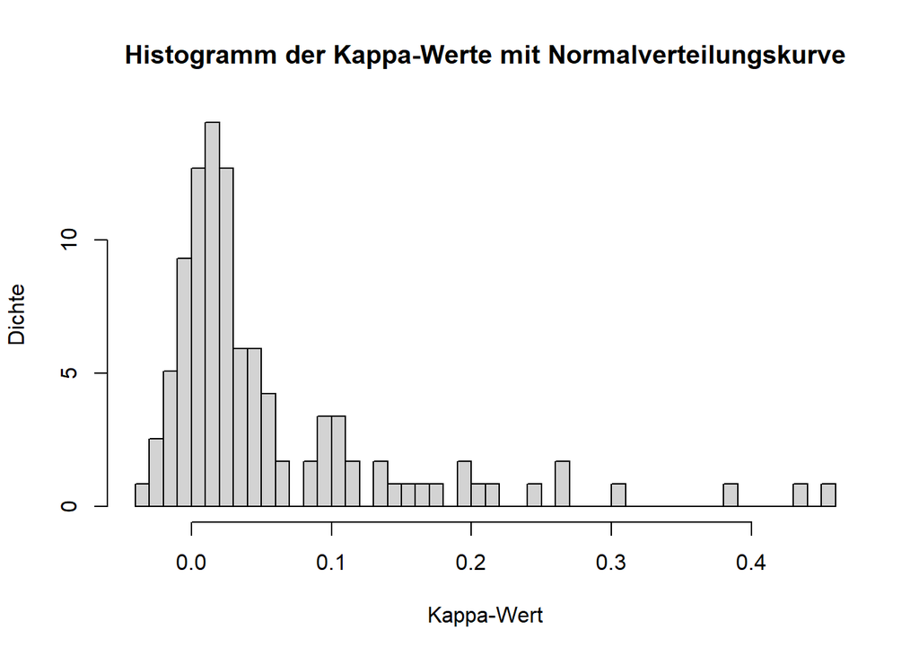

```r
# Normalverteilungsgrafik erstellen
# Histogramm mit angepasster Normalverteilungskurve
hist(kappa_results$Kappa, breaks = 40, prob = TRUE,
     main = "Histogramm der Kappa-Werte mit Normalverteilungskurve",
     xlab = "Kappa-Wert", ylab = "Dichte")
curve(dnorm(x, mean = mean(kappa_results$Kappa), sd = sd(kappa_results$Kappa)),
      add = TRUE, col = "blue", lwd = 2)
```

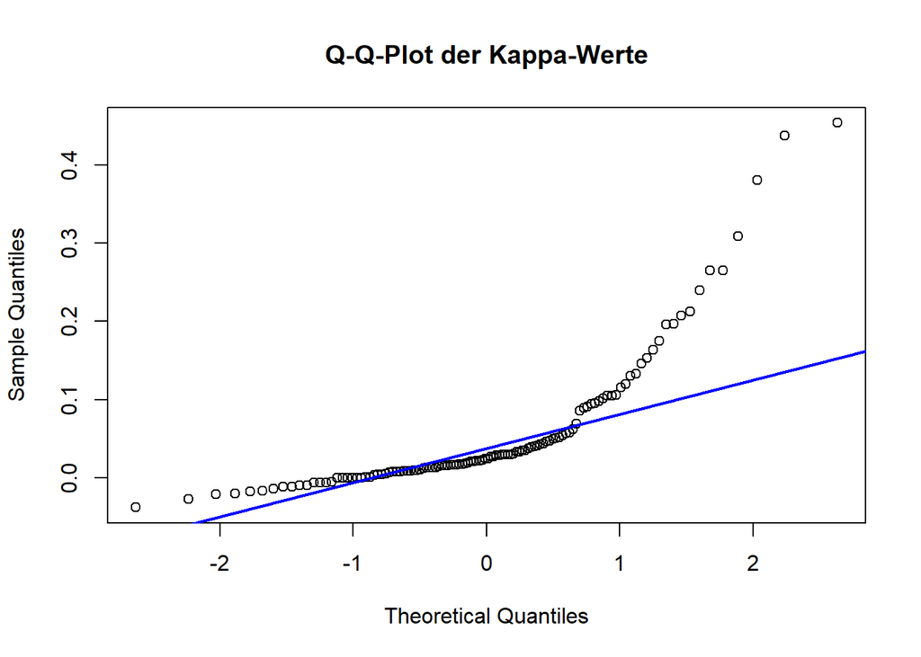

```r
# Q-Q-Plot zur Überprüfung der Normalverteilung
qqnorm(kappa_results$Kappa, main = "Q-Q-Plot der Kappa-Werte")
qqline(kappa_results$Kappa, col = "blue", lwd = 2)
```

## Average Interater kappa over ITEMS…

```r
# Überprüfen, ob die Spalte "Kappa" im Datensatz kappa_results existiert
if("Kappa" %in% colnames(kappa_results)) {
  # Berechne den Durchschnitt der Spalte Kappa und runde auf 2 Nachkommastellen
  Average_Kappa_over_categories <- round(mean(kappa_results$Kappa, na.rm = TRUE), 2)

  # Berechne die Standardabweichung der Spalte Kappa und runde auf 2 Nachkommastellen
  SD_Kappa_over_categories <- round(sd(kappa_results$Kappa, na.rm = TRUE), 2)

  # Berechne den Bereich der Spalte Kappa und runde auf 2 Nachkommastellen
  Range_Kappa_over_categories <- round(range(kappa_results$Kappa, na.rm = TRUE), 2)

  # Ausgabe der Ergebnisse
  cat("Durchschnittlicher Kappa-Wert über alle Kategorien:", Average_Kappa_over_categories, "\n")
  cat("Standardabweichung des Kappa-Werts über alle Kategorien:", SD_Kappa_over_categories, "\n")
  cat("Bereich des Kappa-Werts über alle Kategorien:", Range_Kappa_over_categories[1], "-", Range_Kappa_over_categories[2], "\n")
} else {
  stop("Die Spalte 'Kappa' existiert nicht im Datensatz kappa_results!")
}
```

```
## Durchschnittlicher Kappa-Wert über alle Kategorien: 0.06
## Standardabweichung des Kappa-Werts über alle Kategorien: 0.09
## Bereich des Kappa-Werts über alle Kategorien: -0.04 - 0.45
```

## Average percent agreement over items

```r
# Überprüfen, ob die Spalte "Percent_Agreement" im Datensatz kappa_results existiert
if("Percent_Agreement" %in% colnames(kappa_results)) {
  # Berechne den Durchschnitt der Spalte Percent_Agreement und runde auf 2 Nachkommastellen
  Average_Percent_Agreement_over_categories <- round(mean(kappa_results$Percent_Agreement, na.rm = TRUE), 2)

  # Berechne die Standardabweichung der Spalte Percent_Agreement und runde auf 2 Nachkommastellen
  SD_Percent_Agreement_over_categories <- round(sd(kappa_results$Percent_Agreement, na.rm = TRUE), 2)

  # Berechne den Bereich der Spalte Percent_Agreement und runde auf 2 Nachkommastellen
  Range_Percent_Agreement_over_categories <- round(range(kappa_results$Percent_Agreement, na.rm = TRUE), 2)

  # Ausgabe der Ergebnisse
  cat("Durchschnittlicher Percent_Agreement-Wert über alle Kategorien:", Average_Percent_Agreement_over_categories, "\n")
  cat("Standardabweichung des Percent_Agreement-Werts über alle Kategorien:", SD_Percent_Agreement_over_categories, "\n")
  cat("Bereich des Percent_Agreement-Werts über alle Kategorien:", Range_Percent_Agreement_over_categories[1], "-", Range_Percent_Agreement_over_categories[2], "\n")
} else {
  stop("Die Spalte 'Percent_Agreement' existiert nicht im Datensatz kappa_results!")
}
```

```
## Durchschnittlicher Percent_Agreement-Wert über alle Kategorien: 54.73
## Standardabweichung des Percent_Agreement-Werts über alle Kategorien: 22.31
## Bereich des Percent_Agreement-Werts über alle Kategorien: 12.94 - 97.73
```

## Kappa interrater gpt zu olmo per category 4. ansatz inkl sensitivity,specifity precision per item

```r
# Spalten mit _gpt und _olmo suffix finden
gpt_columns_per_item_v4 <- grep("_gpt$", colnames(data_gpt_olmo_processed), value = TRUE)
olmo_columns_per_item_v4 <- gsub("_gpt$", "_olmo", gpt_columns_per_item_v4)

# Überprüfen, ob die entsprechenden _olmo-Spalten existieren
valid_gpt_columns_per_item_v4 <- gpt_columns_per_item_v4[olmo_columns_per_item_v4 %in% colnames(data_gpt_olmo_processed)]
valid_olmo_columns_per_item_v4 <- olmo_columns_per_item_v4[olmo_columns_per_item_v4 %in% colnames(data_gpt_olmo_processed)]

# Entfernen der Variablen pre_dcp_1_text_gpt und pap_dcp_1_text_gpt, da diese nummerisch sind...
excluded_items <- c("pre_dcp_1_text_gpt", "pap_dcp_1_text_gpt")
valid_gpt_columns_per_item_v4 <- valid_gpt_columns_per_item_v4[!valid_gpt_columns_per_item_v4 %in% excluded_items]
valid_olmo_columns_per_item_v4 <- valid_olmo_columns_per_item_v4[!valid_olmo_columns_per_item_v4 %in% gsub("_gpt$", "_olmo", excluded_items)]

# Sicherstellen, dass nur gültige Paare verwendet werden
if(length(valid_gpt_columns_per_item_v4) == 0) {
  stop("Keine gültigen Paare von GPT- und OLMO-Spalten gefunden!")
}

# Erstelle einen DataFrame, um die Ergebnisse für jede Spalte zu speichern
kappa_results_per_item_v4 <- data.frame(Item = character(),
                                        Kappa = numeric(),
                                        P_Value = numeric(),
                                        Z_Value = numeric(),
                                        Percent_Agreement = numeric(),
                                        Sensitivity_n = numeric(),
                                        Specificity_n = numeric(),
                                        Precision_n = numeric(),
                                        stringsAsFactors = FALSE)

# Berechnung für jede Spalte einzeln
for(i in 1:length(valid_gpt_columns_per_item_v4)) {
  gpt_column_per_item_v4 <- data_gpt_olmo_processed[[valid_gpt_columns_per_item_v4[i]]]
  olmo_column_per_item_v4 <- data_gpt_olmo_processed[[valid_olmo_columns_per_item_v4[i]]]

  # Kombiniere GPT und OLMO Spalten für den Vergleich
  combined_data_per_item_v4 <- data.frame(GPT = gpt_column_per_item_v4,
                                          OLMO = olmo_column_per_item_v4)

  # Entferne NA-Werte
  combined_data_per_item_v4 <- na.omit(combined_data_per_item_v4)

  # Berechne Cohen's Kappa
  kappa_result_per_item_v4 <- irr::kappa2(combined_data_per_item_v4, "unweighted")

  # Berechne den Prozentsatz der Übereinstimmung
  percent_agreement_per_item_v4 <- sum(combined_data_per_item_v4$GPT == combined_data_per_item_v4$OLMO) / nrow(combined_data_per_item_v4) * 100

  # Berechnung der Confusion Matrix (y, n, x Kategorien)
  confusion_matrix <- table(combined_data_per_item_v4$GPT, combined_data_per_item_v4$OLMO)

  # Sicherstellen, dass "n" in der Matrix vorhanden ist
  if("n" %in% rownames(confusion_matrix) && "n" %in% colnames(confusion_matrix)) {
    TN <- confusion_matrix["n", "n"]
  } else {
    TN <- 0
  }

  # Berechne False Positives (FP) und False Negatives (FN) für "n"
  FP <- if("n" %in% rownames(confusion_matrix)) sum(confusion_matrix["n", ]) - TN else 0
  FN <- if("n" %in% colnames(confusion_matrix)) sum(confusion_matrix[, "n"]) - TN else 0

  # Berechne True Positives (TP) als restliche Übereinstimmungen
  TP <- sum(confusion_matrix) - (TN + FP + FN)

  # Berechne Sensitivity (n), Specificity (n) und Precision (n)
  sensitivity_n <- if((TN + FN) > 0) TN / (TN + FN) else NA
  specificity_n <- if((TP + FP) > 0) TP / (TP + FP) else NA
  precision_n <- if((TP + FN) > 0) TP / (TP + FN) else NA

  # Ergebnisse in den DataFrame hinzufügen
  kappa_results_per_item_v4 <- rbind(kappa_results_per_item_v4, data.frame(Item = valid_gpt_columns_per_item_v4[i],
                                                                           Kappa = kappa_result_per_item_v4$value,
                                                                           P_Value = kappa_result_per_item_v4$p.value,
                                                                           Z_Value = kappa_result_per_item_v4$statistic,
                                                                           Percent_Agreement = percent_agreement_per_item_v4,
                                                                           Sensitivity_n = sensitivity_n,
                                                                           Specificity_n = specificity_n,
                                                                           Precision_n = precision_n))
}
# Ergebnisse anzeigen
print(kappa_results_per_item_v4)
```

```
##                Item         Kappa      P_Value     Z_Value Percent_Agreement
## 1   pre_pre_mi1_gpt  0.4541258263 0.000000e+00  8.65894589          79.93528
## 2       pre_mi1_gpt  0.3086381030 1.776357e-15  7.96068708          65.37217
## 3       pre_iv1_gpt  0.1459551398 4.114297e-03  2.86926287          57.92880
## 4     c_pre_iv1_gpt  0.1052529296 6.218188e-03  2.73604839          51.77994
## 5    pre_niv1_1_gpt  0.0461137169 2.158167e-01  1.23772858          58.25243
## 6    pre_niv1_2_gpt  0.0434584373 2.499655e-01  1.15043319          58.25243
## 7   pre_pre_mi2_gpt  0.1152251185 9.014640e-05  3.91568897          34.30421
## 8       pre_mi2_gpt  0.1305433361 6.886795e-04  3.39404669          54.04531
## 9       pre_iv2_gpt  0.0326132029 4.578428e-01  0.74240358          51.13269
## 10    c_pre_iv2_gpt  0.0495291902 1.734968e-01  1.36105335          52.42718
## 11   pre_niv2_1_gpt -0.0096516363 7.552146e-01 -0.31177098          57.92880
## 12   pre_niv2_2_gpt -0.0116349350 7.111686e-01 -0.37028709          57.92880
## 13   pre_pre_mt_gpt  0.0204869036 4.059143e-01  0.83110495          43.36570
## 14       pre_mt_gpt -0.0061050061 8.210121e-01 -0.22624336          94.82201
```

[output cut: 223 more lines]

```r
write.xlsx(kappa_results_per_item_v4, "../Data/processed/kappa_results_per_item_v4.xlsx")
```

##gwets ac1

### GWET’s AC1 per item

```r
# Spalten mit _gpt und _olmo suffix finden
gpt_columns_per_item_v4 <- grep("_gpt$", colnames(data_gpt_olmo_processed), value = TRUE)
olmo_columns_per_item_v4 <- gsub("_gpt$", "_olmo", gpt_columns_per_item_v4)

# Überprüfen, ob die entsprechenden _olmo-Spalten existieren
valid_gpt_columns_per_item_v4 <- gpt_columns_per_item_v4[olmo_columns_per_item_v4 %in% colnames(data_gpt_olmo_processed)]
valid_olmo_columns_per_item_v4 <- olmo_columns_per_item_v4[olmo_columns_per_item_v4 %in% colnames(data_gpt_olmo_processed)]

# Entfernen der Variablen pre_dcp_1_text_gpt und pap_dcp_1_text_gpt, da diese nummerisch sind
excluded_items <- c("pre_dcp_1_text_gpt", "pap_dcp_1_text_gpt")
valid_gpt_columns_per_item_v4 <- valid_gpt_columns_per_item_v4[!valid_gpt_columns_per_item_v4 %in% excluded_items]
valid_olmo_columns_per_item_v4 <- valid_olmo_columns_per_item_v4[!valid_olmo_columns_per_item_v4 %in% gsub("_gpt$", "_olmo", excluded_items)]

# Sicherstellen, dass nur gültige Paare verwendet werden
if(length(valid_gpt_columns_per_item_v4) == 0) {
  stop("Keine gültigen Paare von GPT- und OLMO-Spalten gefunden!")
}

# Erstelle einen DataFrame, um die Ergebnisse für jede Spalte zu speichern
ac1_results_per_item_v4 <- data.frame(Item = character(),
                                      AC1 = numeric(),
                                      Percent_Agreement = numeric(),
                                      Sensitivity_n = numeric(),
                                      Specificity_n = numeric(),
                                      Precision_n = numeric(),
                                      stringsAsFactors = FALSE)

# Berechnung für jede Spalte einzeln
for(i in 1:length(valid_gpt_columns_per_item_v4)) {
  gpt_column_per_item_v4 <- data_gpt_olmo_processed[[valid_gpt_columns_per_item_v4[i]]]
  olmo_column_per_item_v4 <- data_gpt_olmo_processed[[valid_olmo_columns_per_item_v4[i]]]

  # Kombiniere GPT und OLMO Spalten für den Vergleich
  combined_data_per_item_v4 <- data.frame(GPT = gpt_column_per_item_v4,
                                          OLMO = olmo_column_per_item_v4)

  # Entferne NA-Werte
  combined_data_per_item_v4 <- na.omit(combined_data_per_item_v4)

  # Erstelle die Häufigkeitstabelle für GWET's AC1
  agreement_table <- table(combined_data_per_item_v4$GPT, combined_data_per_item_v4$OLMO)

  # Berechne GWET's AC1
  ac1_result_per_item_v4 <- gwet.ac1.raw(agreement_table)

  # Berechne den Prozentsatz der Übereinstimmung
  percent_agreement_per_item_v4 <- sum(combined_data_per_item_v4$GPT == combined_data_per_item_v4$OLMO) / nrow(combined_data_per_item_v4) * 100

  # Berechnung der Confusion Matrix (y, n, x Kategorien)
  confusion_matrix <- table(combined_data_per_item_v4$GPT, combined_data_per_item_v4$OLMO)

  # Sicherstellen, dass "n" in der Matrix vorhanden ist
  if("n" %in% rownames(confusion_matrix) && "n" %in% colnames(confusion_matrix)) {
    TN <- confusion_matrix["n", "n"]
  } else {
    TN <- 0
  }

  # Berechne False Positives (FP) und False Negatives (FN) für "n"
  FP <- if("n" %in% rownames(confusion_matrix)) sum(confusion_matrix["n", ]) - TN else 0
  FN <- if("n" %in% colnames(confusion_matrix)) sum(confusion_matrix[, "n"]) - TN else 0

  # Berechne True Positives (TP) als restliche Übereinstimmungen
  TP <- sum(confusion_matrix) - (TN + FP + FN)

  # Berechne Sensitivity (n), Specificity (n) und Precision (n)
  sensitivity_n <- if((TN + FN) > 0) TN / (TN + FN) else NA
  specificity_n <- if((TP + FP) > 0) TP / (TP + FP) else NA
  precision_n <- if((TP + FN) > 0) TP / (TP + FN) else NA

  # Ergebnisse in den DataFrame hinzufügen
  ac1_results_per_item_v4 <- rbind(ac1_results_per_item_v4, data.frame(Item = valid_gpt_columns_per_item_v4[i],
                                                                        AC1 = ac1_result_per_item_v4$est,
                                                                        Percent_Agreement = percent_agreement_per_item_v4,
                                                                        Sensitivity_n = sensitivity_n,
                                                                        Specificity_n = specificity_n,
                                                                        Precision_n = precision_n))
}

# Ergebnisse anzeigen
print(ac1_results_per_item_v4)
```

```
##                Item AC1.coeff.name    AC1.pa    AC1.pe AC1.coeff.val
## 1   pre_pre_mi1_gpt            AC1 0.0000000 0.2500000      -0.33333
## 2       pre_mi1_gpt            AC1 0.0000000 0.1234568      -0.14085
## 3       pre_iv1_gpt            AC1 0.0000000 0.1666667      -0.20000
## 4     c_pre_iv1_gpt            AC1 0.0000000 0.1111111      -0.12500
## 5    pre_niv1_1_gpt            AC1 0.0000000 0.1399177      -0.16268
## 6    pre_niv1_2_gpt            AC1 0.0000000 0.1234568      -0.14085
## 7   pre_pre_mi2_gpt            AC1 0.0000000 0.1399177      -0.16268
## 8       pre_mi2_gpt            AC1 0.1111111 0.1580247      -0.05572
## 9       pre_iv2_gpt            AC1 0.0000000 0.1111111      -0.12500
## 10    c_pre_iv2_gpt            AC1 0.1111111 0.1234568      -0.01408
## 11   pre_niv2_1_gpt            AC1 0.1111111 0.1234568      -0.01408
## 12   pre_niv2_2_gpt            AC1 0.0000000 0.1234568      -0.14085
## 13   pre_pre_mt_gpt            AC1 0.1111111 0.1358025      -0.02857
## 14       pre_mt_gpt            AC1 0.0000000 0.2500000      -0.33333
```

[output cut: 342 more lines]

### gwet über alle kategorien..

```r
# Spalten mit _gpt und _olmo suffix finden
gpt_columns <- grep("_gpt$", colnames(data_gpt_olmo_processed), value = TRUE)
olmo_columns <- gsub("_gpt$", "_olmo", gpt_columns)

# Überprüfen, ob die entsprechenden _olmo-Spalten existieren
valid_gpt_columns <- gpt_columns[olmo_columns %in% colnames(data_gpt_olmo_processed)]
valid_olmo_columns <- olmo_columns[olmo_columns %in% colnames(data_gpt_olmo_processed)]

# Entfernen der Variablen pre_dcp_1_text_gpt und pap_dcp_1_text_gpt, da diese nummerisch sind
excluded_items <- c("pre_dcp_1_text_gpt", "pap_dcp_1_text_gpt")
valid_gpt_columns <- valid_gpt_columns[!valid_gpt_columns %in% excluded_items]
valid_olmo_columns <- valid_olmo_columns[!valid_olmo_columns %in% gsub("_gpt$", "_olmo", excluded_items)]

# Sicherstellen, dass nur gültige Paare verwendet werden
if(length(valid_gpt_columns) == 0) {
  stop("Keine gültigen Paare von GPT- und OLMO-Spalten gefunden!")
}

# Kombiniere alle gültigen GPT und OLMO Spalten in eine lange Liste
all_gpt_values <- unlist(data_gpt_olmo_processed[valid_gpt_columns])
all_olmo_values <- unlist(data_gpt_olmo_processed[valid_olmo_columns])

# Sicherstellen, dass die Kategorien konsistent sind (3 Kategorien z.B. Y, N, X)
# Umwandlung in Faktoren, falls die Werte nicht schon Faktoren sind
all_gpt_values <- factor(all_gpt_values, levels = c("Y", "N", "X"))
all_olmo_values <- factor(all_olmo_values, levels = c("Y", "N", "X"))

# Erstelle eine Häufigkeitstabelle für GWET's AC1
combined_data <- data.frame(GPT = all_gpt_values, OLMO = all_olmo_values)
combined_data <- na.omit(combined_data)
agreement_table <- table(combined_data$GPT, combined_data$OLMO)

# Berechne GWET's AC1 über alle Items
ac1_overall <- gwet.ac1.raw(agreement_table)

# Extrahiere den Schätzwert und zeige das Ergebnis an
cat("GWET's AC1 über alle Items:", ac1_overall$est$coeff.val, "\n")
```

```
## GWET's AC1 über alle Items: 1
```

```r
# Vollständiges Ergebnis von GWET's AC1 anzeigen
print(ac1_overall)
```

```
## $est
##   coeff.name pa pe coeff.val coeff.se  conf.int p.value     w.name
## 1        AC1  1  1         1      NaN (NaN,NaN)     NaN unweighted
##
## $weights
##      [,1]
## [1,]    1
##
## $categories
## [1] 0
```

## gpt /olmo interrater nur comparison/nur extraction prompt (gesamtdatenset)

```r
# Funktion zur Berechnung des 95%-Konfidenzintervalls für Cohen's Kappa
calculate_kappa_confidence_interval <- function(kappa_value, se_kappa) {
  if (!is.na(se_kappa)) {
    ci_lower <- kappa_value - 1.96 * se_kappa
    ci_upper <- kappa_value + 1.96 * se_kappa
    return(c(ci_lower, ci_upper))
  } else {
    return(c(NA, NA))  # Kein CI, falls SE nicht berechnet werden kann
  }
}

# Extrahiere die GPT und OLMO Spalten für beide Vergleiche (Extraction und Comparison)
gpt_columns_extract <- grep("^(c_pre|pre|c_pap|pap).*_gpt$", colnames(data_gpt_olmo_processed), value = TRUE)
olmo_columns_extract <- gsub("_gpt$", "_olmo", gpt_columns_extract)

gpt_columns_comp <- grep("^(c_match|match).*_gpt$", colnames(data_gpt_olmo_processed), value = TRUE)
olmo_columns_comp <- gsub("_gpt$", "_olmo", gpt_columns_comp)

# Überprüfen, ob die entsprechenden OLMO-Spalten existieren (für beide Gruppen)
valid_gpt_columns_extract <- gpt_columns_extract[olmo_columns_extract %in% colnames(data_gpt_olmo_processed)]
valid_olmo_columns_extract <- olmo_columns_extract[olmo_columns_extract %in% colnames(data_gpt_olmo_processed)]

valid_gpt_columns_comp <- gpt_columns_comp[olmo_columns_comp %in% colnames(data_gpt_olmo_processed)]
valid_olmo_columns_comp <- olmo_columns_comp[olmo_columns_comp %in% colnames(data_gpt_olmo_processed)]

# Sicherstellen, dass nur gültige Paare verwendet werden
if(length(valid_gpt_columns_extract) == 0) {
  stop("Keine gültigen Paare von GPT- und OLMO-Spalten für Extraction gefunden!")
}
if(length(valid_gpt_columns_comp) == 0) {
  stop("Keine gültigen Paare von GPT- und OLMO-Spalten für Comparison gefunden!")
}

# Daten für beide Vergleiche kombinieren und NA-Werte entfernen
combined_data_extract <- data.frame()
combined_data_comp <- data.frame()

# Kombinierte Daten für den Extraction-Vergleich
for(i in 1:length(valid_gpt_columns_extract)) {
  combined_data_extract <- rbind(combined_data_extract, data.frame(GPT = data_gpt_olmo_processed[[valid_gpt_columns_extract[i]]],
                                                                   OLMO = data_gpt_olmo_processed[[valid_olmo_columns_extract[i]]]))
}
combined_data_extract <- na.omit(combined_data_extract)

# Kombinierte Daten für den Comparison-Vergleich
for(i in 1:length(valid_gpt_columns_comp)) {
  combined_data_comp <- rbind(combined_data_comp, data.frame(GPT = data_gpt_olmo_processed[[valid_gpt_columns_comp[i]]],
                                                             OLMO = data_gpt_olmo_processed[[valid_olmo_columns_comp[i]]]))
}
combined_data_comp <- na.omit(combined_data_comp)

# Berechne Cohen's Kappa für Extraction
kappa_result_extract <- irr::kappa2(combined_data_extract, "unweighted")
percent_agreement_extract <- sum(combined_data_extract$GPT == combined_data_extract$OLMO) / nrow(combined_data_extract) * 100
n_extract <- nrow(combined_data_extract)

# Berechnung des Standardfehlers für Extraction
p_e_extract <- sum(rowSums(table(combined_data_extract$GPT, combined_data_extract$OLMO)) * colSums(table(combined_data_extract$GPT, combined_data_extract$OLMO))) / (n_extract^2)
p_0_extract <- percent_agreement_extract / 100

if (p_e_extract == 1) {
  se_kappa_extract <- NA
  z_value_extract <- NA
} else {
  se_kappa_extract <- sqrt((p_0_extract * (1 - p_0_extract)) / (n_extract * (1 - p_e_extract)^2))
  z_value_extract <- kappa_result_extract$value / se_kappa_extract
}

# Konfidenzintervall für Kappa (Extraction)
ci_extract <- calculate_kappa_confidence_interval(kappa_result_extract$value, se_kappa_extract)

# Berechne Cohen's Kappa für Comparison
kappa_result_comp <- irr::kappa2(combined_data_comp, "unweighted")
percent_agreement_comp <- sum(combined_data_comp$GPT == combined_data_comp$OLMO) / nrow(combined_data_comp) * 100
n_comp <- nrow(combined_data_comp)

# Berechnung des Standardfehlers für Comparison
p_e_comp <- sum(rowSums(table(combined_data_comp$GPT, combined_data_comp$OLMO)) * colSums(table(combined_data_comp$GPT, combined_data_comp$OLMO))) / (n_comp^2)
p_0_comp <- percent_agreement_comp / 100

if (p_e_comp == 1) {
  se_kappa_comp <- NA
  z_value_comp <- NA
} else {
  se_kappa_comp <- sqrt((p_0_comp * (1 - p_0_comp)) / (n_comp * (1 - p_e_comp)^2))
  z_value_comp <- kappa_result_comp$value / se_kappa_comp
}

# Konfidenzintervall für Kappa (Comparison)
ci_comp <- calculate_kappa_confidence_interval(kappa_result_comp$value, se_kappa_comp)

# Ergebnisse anzeigen
cat("Cohen's Kappa für Extraction (gesamt_kappa_extraction):\n")
```

```
## Cohen's Kappa für Extraction (gesamt_kappa_extraction):
```

```r
cat("Kappa:", kappa_result_extract$value, "\n")
```

```
## Kappa: 0.312971
```

```r
cat("95%-Konfidenzintervall:", sprintf("[%.3f, %.3f]", ci_extract[1], ci_extract[2]), "\n")
```

```
## 95%-Konfidenzintervall: [0.307, 0.319]
```

```r
cat("p-Wert:", kappa_result_extract$p.value, "\n")
```

```
## p-Wert: 0
```

```r
cat("z-Wert:", z_value_extract, "\n")
```

```
## z-Wert: 100.8076
```

```r
cat("Prozentuale Übereinstimmung:", percent_agreement_extract, "%\n")
```

```
## Prozentuale Übereinstimmung: 53.31191 %
```

```r
cat("Anzahl der Vergleiche (n):", n_extract, "\n")
```

```
## Anzahl der Vergleiche (n): 25831
```

```r
cat("\nCohen's Kappa für Comparison (gesamt_kappa_comparison):\n")
```

```
##
## Cohen's Kappa für Comparison (gesamt_kappa_comparison):
```

```r
cat("Kappa:", kappa_result_comp$value, "\n")
```

```
## Kappa: 0.2757249
```

```r
cat("95%-Konfidenzintervall:", sprintf("[%.3f, %.3f]", ci_comp[1], ci_comp[2]), "\n")
```

```
## 95%-Konfidenzintervall: [0.260, 0.292]
```

```r
cat("p-Wert:", kappa_result_comp$p.value, "\n")
```

```
## p-Wert: 0
```

```r
cat("z-Wert:", z_value_comp, "\n")
```

```
## z-Wert: 33.71513
```

```r
cat("Prozentuale Übereinstimmung:", percent_agreement_comp, "%\n")
```

```
## Prozentuale Übereinstimmung: 58.64797 %
```

```r
cat("Anzahl der Vergleiche (n):", n_comp, "\n")
```

```
## Anzahl der Vergleiche (n): 11124
```

## Kappa interrater gpt zu olmo gesamt

```r
# Funktion zur Berechnung des 95%-Konfidenzintervalls für Cohen's Kappa
calculate_kappa_confidence_interval <- function(kappa_value, se_kappa) {
  if (!is.na(se_kappa)) {
    ci_lower <- kappa_value - 1.96 * se_kappa
    ci_upper <- kappa_value + 1.96 * se_kappa
    return(c(ci_lower, ci_upper))
  } else {
    return(c(NA, NA))  # Kein CI, falls SE nicht berechnet werden kann
  }
}

# Spalten mit _gpt und _olmo Suffix finden
gpt_columns <- grep("_gpt$", colnames(data_gpt_olmo_processed), value = TRUE)
olmo_columns <- gsub("_gpt$", "_olmo", gpt_columns)

# Überprüfen, ob die entsprechenden _olmo-Spalten existieren
valid_gpt_columns <- gpt_columns[olmo_columns %in% colnames(data_gpt_olmo_processed)]
valid_olmo_columns <- olmo_columns[olmo_columns %in% colnames(data_gpt_olmo_processed)]

# Sicherstellen, dass nur gültige Paare verwendet werden
if(length(valid_gpt_columns) == 0) {
  stop("Keine gültigen Paare von GPT- und OLMO-Spalten gefunden!")
}

# Kombinieren der Spalten in einem DataFrame für den Gesamtvergleich
combined_data <- data.frame()

for(i in 1:length(valid_gpt_columns)) {
  # Füge die Werte der GPT und OLMO Spalten zur kombinierten Datensatz hinzu
  combined_data <- rbind(combined_data, data.frame(GPT = data_gpt_olmo_processed[[valid_gpt_columns[i]]],
                                                   OLMO = data_gpt_olmo_processed[[valid_olmo_columns[i]]]))
}

# Entferne NA-Werte
combined_data <- na.omit(combined_data)

# Berechne Cohen's Kappa für den gesamten Test
kappa_result <- irr::kappa2(combined_data, "unweighted")
n_total <- nrow(combined_data)  # Anzahl der Vergleiche

# Berechne den Prozentsatz der Übereinstimmung
percent_agreement <- sum(combined_data$GPT == combined_data$OLMO) / n_total * 100

# Berechnung des Standardfehlers
p_e <- sum(rowSums(table(combined_data$GPT, combined_data$OLMO)) * colSums(table(combined_data$GPT, combined_data$OLMO))) / (n_total^2)
p_0 <- percent_agreement / 100

if (p_e == 1) {
  se_kappa <- NA
  z_value <- NA
} else {
  se_kappa <- sqrt((p_0 * (1 - p_0)) / (n_total * (1 - p_e)^2))
  z_value <- kappa_result$value / se_kappa
}

# Berechne das 95%-Konfidenzintervall für Kappa
ci_kappa <- calculate_kappa_confidence_interval(kappa_result$value, se_kappa)

# Ergebnisse anzeigen
cat("Cohen's Kappa für den gesamten Test:\n")
```

```
## Cohen's Kappa für den gesamten Test:
```

```r
cat("Kappa:", kappa_result$value, "\n")
```

```
## Kappa: 0.3129825
```

```r
cat("95%-Konfidenzintervall:", sprintf("[%.3f, %.3f]", ci_kappa[1], ci_kappa[2]), "\n")
```

```
## 95%-Konfidenzintervall: [0.308, 0.318]
```

```r
cat("p-Wert:", kappa_result$p.value, "\n")
```

```
## p-Wert: 0
```

```r
cat("z-Wert:", z_value, "\n")
```

```
## z-Wert: 120.9075
```

```r
cat("Prozentuale Übereinstimmung:", percent_agreement, "%\n")
```

```
## Prozentuale Übereinstimmung: 54.91814 %
```

```r
cat("Anzahl der Vergleiche (n):", n_total, "\n")
```

```
## Anzahl der Vergleiche (n): 36955
```

## interrater kappa per prompt version

```r
# Funktion zur Berechnung des 95%-Konfidenzintervalls für Cohen's Kappa
calculate_kappa_confidence_interval <- function(kappa_value, se_kappa) {
  if (!is.na(se_kappa)) {
    ci_lower <- kappa_value - 1.96 * se_kappa
    ci_upper <- kappa_value + 1.96 * se_kappa
    return(c(ci_lower, ci_upper))
  } else {
    return(c(NA, NA))  # Kein CI, falls SE nicht berechnet werden kann
  }
}

# Spalten mit _gpt und _olmo Suffix finden
gpt_columns_PromptV <- grep("_gpt$", colnames(data_gpt_olmo_processed), value = TRUE)
olmo_columns_PromptV <- gsub("_gpt$", "_olmo", gpt_columns_PromptV)

# Überprüfen, ob die entsprechenden _olmo-Spalten existieren
valid_gpt_columns_PromptV <- gpt_columns_PromptV[olmo_columns_PromptV %in% colnames(data_gpt_olmo_processed)]
valid_olmo_columns_PromptV <- olmo_columns_PromptV[olmo_columns_PromptV %in% colnames(data_gpt_olmo_processed)]

# Sicherstellen, dass nur gültige Paare verwendet werden
if(length(valid_gpt_columns_PromptV) == 0) {
  stop("Keine gültigen Paare von GPT- und OLMO-Spalten gefunden!")
}

# Definiere die verschiedenen Versionen, die in prompt_version auftreten (A, B, C, D)
versions_PromptV <- c("A", "B", "C", "D")

# Schleife durch jede Version und berechne das Kappa für jede
for (version_PromptV in versions_PromptV) {
  # Filtere die Zeilen, die zur aktuellen Version gehören
  version_data_PromptV <- data_gpt_olmo_processed[data_gpt_olmo_processed$prompt_version == version_PromptV, ]

  # Kombinieren der Spalten in einem DataFrame für den Vergleich der aktuellen Version
  combined_data_PromptV <- data.frame()

  for(i in 1:length(valid_gpt_columns_PromptV)) {
    # Füge die Werte der GPT und OLMO Spalten zur kombinierten Datensatz hinzu
    combined_data_PromptV <- rbind(combined_data_PromptV, data.frame(GPT = version_data_PromptV[[valid_gpt_columns_PromptV[i]]],
                                                                     OLMO = version_data_PromptV[[valid_olmo_columns_PromptV[i]]]))
  }

  # Entferne NA-Werte
  combined_data_PromptV <- na.omit(combined_data_PromptV)

  # Berechne Cohen's Kappa für die aktuelle Version
  kappa_result_PromptV <- irr::kappa2(combined_data_PromptV, "unweighted")
  n_PromptV <- nrow(combined_data_PromptV)  # Anzahl der Vergleiche

  # Berechne den Prozentsatz der Übereinstimmung
  percent_agreement_PromptV <- sum(combined_data_PromptV$GPT == combined_data_PromptV$OLMO) / n_PromptV * 100

  # Berechnung des Standardfehlers
  p_e_PromptV <- sum(rowSums(table(combined_data_PromptV$GPT, combined_data_PromptV$OLMO)) * colSums(table(combined_data_PromptV$GPT, combined_data_PromptV$OLMO))) / (n_PromptV^2)
  p_0_PromptV <- percent_agreement_PromptV / 100

  if (p_e_PromptV == 1) {
    se_kappa_PromptV <- NA
    z_value_PromptV <- NA
  } else {
    se_kappa_PromptV <- sqrt((p_0_PromptV * (1 - p_0_PromptV)) / (n_PromptV * (1 - p_e_PromptV)^2))
    z_value_PromptV <- kappa_result_PromptV$value / se_kappa_PromptV
  }

  # Berechne das 95%-Konfidenzintervall für Kappa
  ci_kappa_PromptV <- calculate_kappa_confidence_interval(kappa_result_PromptV$value, se_kappa_PromptV)

  # Ergebnisse anzeigen
  cat("\nCohen's Kappa für Version", version_PromptV, ":\n")
  cat("Kappa:", kappa_result_PromptV$value, "\n")
  cat("95%-Konfidenzintervall:", sprintf("[%.3f, %.3f]", ci_kappa_PromptV[1], ci_kappa_PromptV[2]), "\n")
  cat("p-Wert:", kappa_result_PromptV$p.value, "\n")
  cat("z-Wert:", z_value_PromptV, "\n")
  cat("Prozentuale Übereinstimmung:", percent_agreement_PromptV, "%\n")
  cat("Anzahl der Vergleiche (n):", n_PromptV, "\n")
}
```

```
##
## Cohen's Kappa für Version A :
## Kappa: 0.2820128
## 95%-Konfidenzintervall: [0.266, 0.298]
## p-Wert: 0
## z-Wert: 33.78623
## Prozentuale Übereinstimmung: 51.50418 %
## Anzahl der Vergleiche (n): 3590
```

```
##
## Cohen's Kappa für Version B :
## Kappa: 0.2892539
## 95%-Konfidenzintervall: [0.276, 0.303]
## p-Wert: 0
## z-Wert: 42.42209
## Prozentuale Übereinstimmung: 51.8422 %
## Anzahl der Vergleiche (n): 5374
```

```
##
## Cohen's Kappa für Version C :
## Kappa: 0.2424722
## 95%-Konfidenzintervall: [0.226, 0.259]
## p-Wert: 0
## z-Wert: 29.51078
## Prozentuale Übereinstimmung: 48.28517 %
## Anzahl der Vergleiche (n): 3703
```

```
##
## Cohen's Kappa für Version D :
## Kappa: 0.333917
## 95%-Konfidenzintervall: [0.328, 0.340]
## p-Wert: 0
## z-Wert: 105.1388
## Prozentuale Übereinstimmung: 57.11462 %
## Anzahl der Vergleiche (n): 24288
```

### siginifikanztest unterscheid promptversion a zu d

```r
# Funktion zur Berechnung des Fisher-Z-Werts für den Unterschied zwischen zwei Kappa-Werten
calculate_z_difference <- function(kappa1, se_kappa1, kappa2, se_kappa2) {
  if (!is.na(se_kappa1) & !is.na(se_kappa2)) {
    z_diff <- (kappa1 - kappa2) / sqrt(se_kappa1^2 + se_kappa2^2)
    p_value <- 2 * (1 - pnorm(abs(z_diff)))  # zweiseitiger Test
    return(c(z_diff, p_value))
  } else {
    return(c(NA, NA))  # Kein Vergleich möglich, falls SE nicht berechnet werden kann
  }
}

# Definiere die Versionen A und D für den Vergleich
version_compare <- c("A", "D")

# Speichern der Kappa-Ergebnisse für A und D
kappa_results_z <- list()

for (version_PromptV in version_compare) {
  # Filtere die Zeilen für die aktuelle Version
  version_data_PromptV <- data_gpt_olmo_processed[data_gpt_olmo_processed$prompt_version == version_PromptV, ]

  combined_data_PromptV <- data.frame()

  for(i in 1:length(valid_gpt_columns_PromptV)) {
    combined_data_PromptV <- rbind(combined_data_PromptV, data.frame(GPT = version_data_PromptV[[valid_gpt_columns_PromptV[i]]],
                                                                     OLMO = version_data_PromptV[[valid_olmo_columns_PromptV[i]]]))
  }

  combined_data_PromptV <- na.omit(combined_data_PromptV)

  kappa_result_PromptV <- irr::kappa2(combined_data_PromptV, "unweighted")
  n_PromptV <- nrow(combined_data_PromptV)

  p_e_PromptV <- sum(rowSums(table(combined_data_PromptV$GPT, combined_data_PromptV$OLMO)) * colSums(table(combined_data_PromptV$GPT, combined_data_PromptV$OLMO))) / (n_PromptV^2)
  p_0_PromptV <- sum(combined_data_PromptV$GPT == combined_data_PromptV$OLMO) / n_PromptV

  if (p_e_PromptV == 1) {
    se_kappa_PromptV <- NA
  } else {
    se_kappa_PromptV <- sqrt((p_0_PromptV * (1 - p_0_PromptV)) / (n_PromptV * (1 - p_e_PromptV)^2))
  }

  # Speichern der Kappa-Werte und Standardfehler für Vergleich
  kappa_results_z[[version_PromptV]] <- list(kappa = kappa_result_PromptV$value, se = se_kappa_PromptV)
}
# Berechnen des Z-Werts und p-Werts für den Unterschied zwischen A und D
z_diff_results <- calculate_z_difference(kappa_results_z[["A"]]$kappa, kappa_results_z[["A"]]$se,
                                         kappa_results_z[["D"]]$kappa, kappa_results_z[["D"]]$se)

cat("\nUnterschied zwischen Cohen's Kappa für Version A und D:\n")
```

```
##
## Unterschied zwischen Cohen's Kappa für Version A und D:
```

```r
cat("Z-Wert:", z_diff_results[1], "\n")
```

```
## Z-Wert: -5.811836
```

```r
cat("p-Wert:", z_diff_results[2], "\n")
```

```
## p-Wert: 6.179123e-09
```

###signifikanztest unterschied extraction comparison steigers z

```r
# Berechne den Unterschied zwischen den Kappa-Werten für Extraction und Comparison
z_diff_results <- calculate_z_difference(kappa_result_extract$value, se_kappa_extract,
                                         kappa_result_comp$value, se_kappa_comp)

cat("\nUnterschied zwischen Kappa für Extraction und Comparison:\n")
```

```
##
## Unterschied zwischen Kappa für Extraction und Comparison:
```

```r
cat("Z-Wert:", z_diff_results[1], "\n")
```

```
## Z-Wert: 4.257885
```

```r
cat("p-Wert:", z_diff_results[2], "\n")
```

```
## p-Wert: 2.063702e-05
```

## kappa interrater gpt olmo zusammengefügt

```r
# Erstelle den DataFrame mit den Kappa-Ergebnissen, Zahlen auf 2 Nachkommastellen gerundet
kappas_total_zusammengeführt <- data.frame(
  Test = c("Gesamter Test", "Extraction", "Comparison", "Version A", "Version B", "Version C", "Version D"),
  Kappa = round(c(0.3129825, 0.312971, 0.2757249, 0.2820128, 0.2892539, 0.2424722, 0.333917), 2),
  CI_Lower = round(c(0.308, 0.307, 0.260, 0.266, 0.276, 0.226, 0.328), 2),
  CI_Upper = round(c(0.318, 0.319, 0.292, 0.298, 0.303, 0.259, 0.340), 2),
  Percent_Agreement = round(c(54.92, 53.31, 58.65, 51.50, 51.84, 48.29, 57.11), 2),
  N_Comparisons = c(36955, 25831, 11124, 3590, 5374, 3703, 24288)
)

# Erstelle die Tabelle mit flextable
ft <- flextable(kappas_total_zusammengeführt)

# Setze die Spaltenüberschriften im APA-Stil
ft <- set_header_labels(ft,
                        Test = "Test",
                        Kappa = "Kappa",
                        CI_Lower = "95% CI Lower",
                        CI_Upper = "95% CI Upper",
                        Percent_Agreement = "Percent Agreement (%)",
                        N_Comparisons = "N")

# Wende APA-konforme Formatierung an
ft <- theme_vanilla(ft) # Minimalistisches Design ohne vertikale Linien
ft <- fontsize(ft, part = "all", size = 12) # Schriftgröße auf 12 setzen
ft <- bold(ft, part = "header") # Kopfzeile fett machen
ft <- align(ft, part = "all", align = "center") # Text zentrieren
ft <- autofit(ft) # Automatisch die Spaltenbreiten anpassen

# Optional: Tabelle als Word-Dokument speichern
# save_as_docx(ft, path = "kappas_total_zusammengeführt.docx")

# Zeige die Tabelle an
ft
```

| Test | Kappa | 95% CI Lower | 95% CI Upper | Percent Agreement (%) | N |
| --- | --- | --- | --- | --- | --- |
| Gesamter Test | 0.31 | 0.31 | 0.32 | 54.92 | 36,955 |
| Extraction | 0.31 | 0.31 | 0.32 | 53.31 | 25,831 |
| Comparison | 0.28 | 0.26 | 0.29 | 58.65 | 11,124 |
| Version A | 0.28 | 0.27 | 0.30 | 51.50 | 3,590 |
| Version B | 0.29 | 0.28 | 0.30 | 51.84 | 5,374 |
| Version C | 0.24 | 0.23 | 0.26 | 48.29 | 3,703 |
| Version D | 0.33 | 0.33 | 0.34 | 57.11 | 24,288 |

# interrater Kappa NUR Y & N

## interrater kappa y_n all categories

```r
# Function to calculate Cohen's Kappa, p-value, z-value, percentage agreement, and number of comparisons using 'irr' package
calculate_kappa_irr_filtered_debug <- function(data, column_gpt, column_olmo) {
  # Ensure both columns exist
  if (column_gpt %in% colnames(data) & column_olmo %in% colnames(data)) {
    # Filter rows where the OLMO column is either "Y" or "N"
    valid_data <- data[data[[column_olmo]] %in% c("y", "n"), ]

    # Debug: Print number of valid rows for the comparison
    print(paste("Number of valid rows for comparison (", column_gpt, " & ", column_olmo, "): ", nrow(valid_data)))

    # Check if there are any valid rows left for comparison
    if (nrow(valid_data) > 0) {
      # Remove rows with NA values in the selected columns
      valid_data <- valid_data[!is.na(valid_data[[column_gpt]]) & !is.na(valid_data[[column_olmo]]), ]

      # Debug: Print number of rows after removing NAs
      print(paste("Number of valid rows after removing NAs: ", nrow(valid_data)))

      # Check again if there are rows left after removing NAs
      if (nrow(valid_data) > 0) {
        # Calculate Cohen's Kappa using the 'kappa2' function from the irr package
        kappa_result <- irr::kappa2(valid_data[, c(column_gpt, column_olmo)], "unweighted")

        # Extract values
        kappa_value <- kappa_result$value
        p_value <- kappa_result$p.value
        z_value <- kappa_result$statistic
        percent_agreement <- sum(valid_data[[column_gpt]] == valid_data[[column_olmo]]) / nrow(valid_data) * 100

        # Return the results including the number of comparisons (N)
        return(c(kappa_value, p_value, z_value, percent_agreement, nrow(valid_data)))
      } else {
        # No valid comparisons available after NA removal
        print("No valid rows left after removing NAs.")
        return(rep(NA, 5))
      }
    } else {
      # No valid comparisons based on OLMO filter
      print("No valid rows based on OLMO filter (Y/N).")
      return(rep(NA, 5))
    }
  } else {
    print(paste("Columns", column_gpt, "or", column_olmo, "do not exist in the dataset."))
    return(rep(NA, 5))
  }
}

# Get all columns that have _gpt or _olmo suffix
gpt_columns <- grep("_gpt$", colnames(data_gpt_olmo_processed), value = TRUE)
olmo_columns <- gsub("_gpt$", "_olmo", gpt_columns)

# Create a dataframe to store the results
kappa_results_filtered_debug <- data.frame(
  Variable = gpt_columns,
  Kappa = NA,
  P_Value = NA,
  Z_Value = NA,
  Percent_Agreement = NA,
  N_Comparisons = NA
)

# Loop over all _gpt and _olmo column pairs and calculate statistics
for (i in 1:length(gpt_columns)) {
  print(paste("Processing columns:", gpt_columns[i], "and", olmo_columns[i]))
  kappa_stats_filtered_debug <- calculate_kappa_irr_filtered_debug(data_gpt_olmo_processed, gpt_columns[i], olmo_columns[i])
  kappa_results_filtered_debug[i, 2:6] <- kappa_stats_filtered_debug
}
```

[output not shown]

[output cut: 71 more lines]

[output not shown]

[output not shown]

[output cut: 45 more lines]

[output not shown]

[output cut: 129 more lines]

[output not shown]

[output cut: 30 more lines]

```r
# Show the results
print(kappa_results_filtered_debug)
```

```
##               Variable         Kappa      P_Value     Z_Value Percent_Agreement
## 1             date_gpt            NA           NA          NA                NA
## 2      pre_pre_mi1_gpt  0.4541258263 0.000000e+00  8.65894589         79.935275
## 3          pre_mi1_gpt  0.0479704797 2.110208e-01  1.25076333         74.883721
## 4          pre_iv1_gpt -0.0567536890 8.744189e-02 -1.70904888         48.421053
## 5        c_pre_iv1_gpt  0.0417633411 4.351424e-01  0.78042226         29.761905
## 6       pre_niv1_1_gpt -0.0341113106 5.188175e-01 -0.64516919         43.750000
## 7       pre_niv1_2_gpt -0.0627306273 1.644627e-01 -1.39021810         43.750000
## 8      pre_pre_mi2_gpt  0.2607510958 1.512495e-04  3.78900883         56.666667
## 9          pre_mi2_gpt -0.0425531915 4.149698e-01 -0.81517906         69.387755
## 10         pre_iv2_gpt -0.0300269906 4.513003e-01 -0.75324895         39.436620
## 11       c_pre_iv2_gpt  0.0593354430 3.153445e-01  1.00407070         29.310345
## 12      pre_niv2_1_gpt -0.0531177829 4.241251e-01 -0.79928514         20.833333
## 13      pre_niv2_2_gpt -0.0704225352 2.738009e-01 -1.09435131         20.833333
## 14      pre_pre_mt_gpt -0.0402010050 4.552387e-01 -0.74670996         60.869565
```

[output cut: 229 more lines]

## kappa y & n total

```r
# Funktion zur Berechnung des 95%-Konfidenzintervalls für Cohen's Kappa
calculate_kappa_confidence_interval <- function(kappa_value, se_kappa) {
  if (!is.na(se_kappa)) {
    ci_lower <- kappa_value - 1.96 * se_kappa
    ci_upper <- kappa_value + 1.96 * se_kappa
    return(c(ci_lower, ci_upper))
  } else {
    return(c(NA, NA))  # Kein CI, falls SE nicht berechnet werden kann
  }
}

# Funktion zur Berechnung des Standardfehlers und der erwarteten Übereinstimmung
calculate_standard_error <- function(data) {
  # Erstelle die Kontingenztabelle
  contingency_table <- table(data$GPT, data$OLMO)

  # Berechne die Zeilen- und Spaltensummen der Kontingenztabelle
  row_sums <- rowSums(contingency_table)
  col_sums <- colSums(contingency_table)

  # Anzahl der Paare
  n <- sum(contingency_table)

  # Berechnung der erwarteten Übereinstimmung (p_e)
  p_e <- sum(row_sums * col_sums) / (n^2)

  # Berechne den beobachteten Prozentsatz der Übereinstimmung (p_0)
  percent_agreement <- sum(diag(contingency_table)) / n * 100
  p_0 <- percent_agreement / 100

  return(list(p_e = p_e, p_0 = p_0, n = n))
}

# Funktion zur Berechnung von Cohen's Kappa, p-Wert, z-Wert, prozentuale Übereinstimmung, Anzahl der Vergleiche und Konfidenzintervall
calculate_overall_kappa <- function(data, gpt_columns, olmo_columns) {
  # Erstelle einen leeren DataFrame für die relevanten Vergleichswerte
  combined_data <- data.frame(GPT = character(), OLMO = character(), stringsAsFactors = FALSE)

  # Schleife über alle GPT und OLMO Spalten, um gültige Zeilen zu sammeln
  for (i in 1:length(gpt_columns)) {
    if (gpt_columns[i] %in% colnames(data) & olmo_columns[i] %in% colnames(data)) {
      # Filtere nur Zeilen, in denen der OLMO-Wert "y" oder "n" ist
      valid_rows <- data[data[[olmo_columns[i]]] %in% c("y", "n"), ]

      # Wähle die relevanten GPT- und OLMO-Werte aus und entferne NA-Werte
      valid_rows <- valid_rows[!is.na(valid_rows[[gpt_columns[i]]]) & !is.na(valid_rows[[olmo_columns[i]]]), ]

      # Füge die gültigen GPT- und OLMO-Werte in den kombinierten DataFrame ein
      combined_data <- rbind(combined_data, data.frame(GPT = valid_rows[[gpt_columns[i]]], OLMO = valid_rows[[olmo_columns[i]]]))
    }
  }

  # Überprüfe, ob genügend Datenpunkte vorhanden sind, um Kappa zu berechnen
  if (nrow(combined_data) > 0) {
    # Berechne Cohen's Kappa über alle kombinierten Zellen
    kappa_result <- irr::kappa2(combined_data, "unweighted")

    # Extrahiere Kappa-Wert, p-Wert und z-Wert
    kappa_value <- kappa_result$value
    p_value <- kappa_result$p.value
    z_value <- kappa_result$statistic
    percent_agreement <- sum(combined_data$GPT == combined_data$OLMO) / nrow(combined_data) * 100
    n_comparisons <- nrow(combined_data)

    # Berechne den Standardfehler und die erwartete Übereinstimmung
    agreement_info <- calculate_standard_error(combined_data)
    p_e <- agreement_info$p_e
    p_0 <- agreement_info$p_0

    # Berechne den Standardfehler
    if (p_e == 1) {
      se_kappa <- NA
    } else {
      se_kappa <- sqrt((p_0 * (1 - p_0)) / (n_comparisons * (1 - p_e)^2))
    }

    # Berechne das 95%-Konfidenzintervall für Kappa
    ci_kappa <- calculate_kappa_confidence_interval(kappa_value, se_kappa)

    # Rückgabe der Ergebnisse einschließlich des Konfidenzintervalls
    return(data.frame(Kappa_Gesamt = kappa_value, P_Value = p_value, Z_Value = z_value, Percent_Agreement = percent_agreement,
                      N_Comparisons = n_comparisons, CI_Lower = ci_kappa[1], CI_Upper = ci_kappa[2]))
  } else {
    # Rückgabe von NA, wenn keine gültigen Vergleiche vorhanden sind
    return(data.frame(Kappa_Gesamt = NA, P_Value = NA, Z_Value = NA, Percent_Agreement = NA, N_Comparisons = 0, CI_Lower = NA, CI_Upper = NA))
  }
}

# Hole alle Spalten mit _gpt oder _olmo Suffix
gpt_columns <- grep("_gpt$", colnames(data_gpt_olmo_processed), value = TRUE)
olmo_columns <- gsub("_gpt$", "_olmo", gpt_columns)

# Berechne das Gesamtkappa über alle relevanten Zellen
kappa_gesamt_yn <- calculate_overall_kappa(data_gpt_olmo_processed, gpt_columns, olmo_columns)
# Zeige das Gesamtergebnis an
print(kappa_gesamt_yn)
```

```
##   Kappa_Gesamt P_Value  Z_Value Percent_Agreement N_Comparisons   CI_Lower
## 1   0.09678252       0 19.47466          53.92227         15361 0.08689022
##    CI_Upper
## 1 0.1066748
```

i thought it would be better, but its actually worse…

# NEW / MINIMAL VERSION (VE)

## interrater kappa new per category

```r
# Definiere die zu vergleichenden Variablenpaare
variables_to_compare_ve <- c("match_dv_0", "match_dv_1", "match_dv_2", "match_dv_3",
                             "match_dcp_1", "match_dcp_2", "match_sm_1", "match_sm_2", "match_sm_3")

# Liste zur Speicherung der Ergebnisse
results_ve <- data.frame(Variable_ve = character(),
                         Kappa_ve = numeric(),
                         N_ve = numeric(),
                         Agreement_Percent_ve = numeric(),
                         CI_Lower_ve = numeric(),  # Konfidenzintervall untere Grenze
                         CI_Upper_ve = numeric(),  # Konfidenzintervall obere Grenze
                         Accuracy_ve = numeric(),
                         Sensitivity_ve = numeric(),
                         Specificity_ve = numeric(),
                         N_Count_Olmo = numeric(),
                         N_Count_GPT = numeric(),
                         Y_Count_Olmo = numeric(),
                         Y_Count_GPT = numeric(),
                         stringsAsFactors = FALSE)

# Berechnung von Cohen's Kappa und weiteren Kennzahlen für jede Variable
for (variable in variables_to_compare_ve) {
  # Definiere die Spaltennamen für GPT und Olmo
  gpt_column <- paste0(variable, "_gpt")
  olmo_column <- paste0(variable, "_olmo")

  # Selektiere die relevanten Spalten und entferne Zeilen mit NA-Werten nur in diesen Spalten
  comparison_data <- data_gpt_ve_filtered %>%
    select(gpt_column, olmo_column) %>%
    filter(!is.na(.[[gpt_column]]) & !is.na(.[[olmo_column]]))

  # Berechne Cohen's Kappa für die aktuelle Variable
  kappa_obj_ve <- kappa2(comparison_data)
  kappa_value_ve <- kappa_obj_ve$value

  # Anzahl der Vergleiche (N)
  n_comparisons_ve <- nrow(comparison_data)

  # Berechne den prozentualen Anteil der Übereinstimmungen
  agreement_percent_ve <- mean(comparison_data[[gpt_column]] == comparison_data[[olmo_column]]) * 100

  # Berechne den Standardfehler für Cohen's Kappa
  se_kappa_ve <- sqrt((1 - kappa_value_ve^2) / n_comparisons_ve)

  # Berechne das 95%-Konfidenzintervall (z-Wert von 1.96 für 95%)
  ci_lower_ve <- kappa_value_ve - 1.96 * se_kappa_ve
  ci_upper_ve <- kappa_value_ve + 1.96 * se_kappa_ve

  # Erstelle Confusion-Matrix
  confusion_matrix <- table(comparison_data[[gpt_column]], comparison_data[[olmo_column]])
  true_positive <- confusion_matrix[2, 2]
  true_negative <- confusion_matrix[1, 1]
  false_positive <- confusion_matrix[1, 2]
  false_negative <- confusion_matrix[2, 1]

  # Berechne Genauigkeit, Spezifität und Sensitivität
  accuracy_ve <- (true_positive + true_negative) / n_comparisons_ve
  sensitivity_ve <- true_positive / (true_positive + false_negative)
  specificity_ve <- true_negative / (true_negative + false_positive)

  # Zähle die Anzahl der "N"- und "Y"-Werte in den Spalten von GPT und Olmo
  n_count_olmo <- sum(comparison_data[[olmo_column]] == "n", na.rm = TRUE)
  n_count_gpt <- sum(comparison_data[[gpt_column]] == "n", na.rm = TRUE)
  y_count_olmo <- sum(comparison_data[[olmo_column]] == "y", na.rm = TRUE)
  y_count_gpt <- sum(comparison_data[[gpt_column]] == "y", na.rm = TRUE)

  # Ergebnisse speichern mit den Endungen _ve
  results_ve <- rbind(results_ve, data.frame(Variable_ve = variable,
                                             Kappa_ve = kappa_value_ve,
                                             N_ve = n_comparisons_ve,
                                             Agreement_Percent_ve = agreement_percent_ve,
                                             CI_Lower_ve = ci_lower_ve,
                                             CI_Upper_ve = ci_upper_ve,
                                             Accuracy_ve = accuracy_ve,
                                             Sensitivity_ve = sensitivity_ve,
                                             Specificity_ve = specificity_ve,
                                             N_Count_Olmo = n_count_olmo,
                                             N_Count_GPT = n_count_gpt,
                                             Y_Count_Olmo = y_count_olmo,
                                             Y_Count_GPT = y_count_gpt))
}
# Ausgabe der Ergebnisse als DataFrame
print(results_ve)
```

```
##   Variable_ve    Kappa_ve N_ve Agreement_Percent_ve CI_Lower_ve CI_Upper_ve
## 1  match_dv_0 -0.03311258   52             88.46154  -0.3047666   0.2385415
## 2  match_dv_1  0.10958904   52             71.15385  -0.1605770   0.3797551
## 3  match_dv_2 -0.10457516   52             50.00000  -0.3748880   0.1657376
## 4  match_dv_3  0.05910736   52             42.30769  -0.2122205   0.3304352
## 5 match_dcp_1  0.31125828   52             69.23077   0.0529569   0.5695597
## 6 match_dcp_2  0.06849315   52             34.61538  -0.2026716   0.3396579
## 7  match_sm_1  0.13057325   52             59.61538  -0.1389029   0.4000493
## 8  match_sm_2 -0.03116147   52             73.07692  -0.3028326   0.2405096
## 9  match_sm_3 -0.08333333   52             34.61538  -0.3541910   0.1875244
##   Accuracy_ve Sensitivity_ve Specificity_ve N_Count_Olmo N_Count_GPT
## 1   0.8846154      0.9787234      0.0000000            1           5
## 2   0.7115385      0.8500000      0.2500000            9          12
## 3   0.5000000      0.5476190      0.3000000           22          10
## 4   0.4230769      0.3488372      0.7777778           35           9
## 5   0.6923077      0.3181818      0.9666667           44          30
## 6   0.3461538      0.1282051      1.0000000           47          13
## 7   0.5961538      0.5952381      0.6000000           23          10
## 8   0.7307692      0.8604651      0.1111111            7           9
## 9   0.3461538      0.1944444      0.6875000           40          16
##   Y_Count_Olmo Y_Count_GPT
## 1           51          47
## 2           43          40
## 3           30          42
## 4           17          43
## 5            8          22
## 6            5          39
## 7           29          42
## 8           45          43
## 9           12          36
```

## Interrater kappa ve total

```r
# Funktion zur Berechnung des Konfidenzintervalls für Kappa
calculate_kappa_confidence_interval <- function(kappa_value, n, alpha = 0.05) {
  # Standardfehler von Kappa
  standard_error <- sqrt((1 - kappa_value^2) / n)

  # Z-Wert für das gewünschte Konfidenzniveau (z.B. 95%)
  z_value <- qnorm(1 - alpha / 2)

  # Berechnung der unteren und oberen Grenze des Konfidenzintervalls
  ci_lower <- kappa_value - z_value * standard_error
  ci_upper <- kappa_value + z_value * standard_error

  return(c(ci_lower, ci_upper))
}

# Daten filtern: Nur Zeilen behalten, die nicht "exclude" in master_exclude haben
data_gpt_ve_total_filtered <- data_gpt_ve_processed %>%
  filter(master_exclude != "exclude")

# Definiere die zu vergleichenden Variablenpaare
variables_to_compare_ve_total <- c("match_dv_0", "match_dv_1", "match_dv_2", "match_dv_3",
                                   "match_dcp_1", "match_dcp_2", "match_sm_1", "match_sm_2", "match_sm_3")

# Liste zur Speicherung der kombinierten Ratings
combined_data_ve_total <- data.frame(GPT_Rating_ve_total = character(),
                                     Olmo_Rating_ve_total = character(),
                                     stringsAsFactors = FALSE)

# Kombinieren der Daten aus allen relevanten Variablenpaaren
for (variable in variables_to_compare_ve_total) {
  # Definiere die Spaltennamen für GPT und Olmo
  gpt_column <- paste0(variable, "_gpt")
  olmo_column <- paste0(variable, "_olmo")

  # Selektiere die relevanten Spalten und entferne Zeilen mit NA-Werten nur in diesen Spalten
  comparison_data <- data_gpt_ve_total_filtered %>%
    select(gpt_column, olmo_column) %>%
    filter(!is.na(.[[gpt_column]]) & !is.na(.[[olmo_column]])) %>%
    rename(GPT_Rating_ve_total = gpt_column, Olmo_Rating_ve_total = olmo_column)

  # Füge die gefilterten Daten zum kombinierten Datensatz hinzu
  combined_data_ve_total <- rbind(combined_data_ve_total, comparison_data)
}

# Berechnung des Gesamt-Kappa über alle kombinierten Kategorien hinweg
kappa_obj_ve_total <- kappa2(combined_data_ve_total)
kappa_value_ve_total <- kappa_obj_ve_total$value

# Berechnung des Konfidenzintervalls für Kappa (manuell)
ci_kappa_ve_total <- calculate_kappa_confidence_interval(kappa_value_ve_total, nrow(combined_data_ve_total))

# Berechnung zusätzlicher Kennzahlen
n_comparisons_ve_total <- nrow(combined_data_ve_total)  # Anzahl der Vergleiche (N)
agreement_percent_ve_total <- mean(combined_data_ve_total$GPT_Rating_ve_total == combined_data_ve_total$Olmo_Rating_ve_total) * 100
z_value_ve_total <- kappa_obj_ve_total$statistic  # Z-Wert aus dem Kappa-Objekt
p_value_ve_total <- kappa_obj_ve_total$p.value    # p-Wert aus dem Kappa-Objekt

# Ergebnisse auf 2 Nachkommastellen runden
results_ve_total <- data.frame(Variable_ve_total = "Overall",
                               Kappa_ve_total = round(kappa_value_ve_total, 2),
                               CI_Lower_ve_total = round(ci_kappa_ve_total[1], 2),  # Untere Grenze des CIs
                               CI_Upper_ve_total = round(ci_kappa_ve_total[2], 2),  # Obere Grenze des CIs
                               N_ve_total = n_comparisons_ve_total,
                               Agreement_Percent_ve_total = round(agreement_percent_ve_total, 2),
                               Z_Value_ve_total = round(z_value_ve_total, 2),
                               P_Value_ve_total = round(p_value_ve_total, 2))

print(results_ve_total)
```

```
##   Variable_ve_total Kappa_ve_total CI_Lower_ve_total CI_Upper_ve_total
## 1           Overall           0.15              0.06              0.24
##   N_ve_total Agreement_Percent_ve_total Z_Value_ve_total P_Value_ve_total
## 1        468                      58.12             3.76                0
```

## confusion matrix VE V1

```r
# Definiere die zu vergleichenden Variablenpaare
variables_to_compare_ve_total <- c("match_dv_0", "match_dv_1", "match_dv_2", "match_dv_3",
                                   "match_dcp_1", "match_dcp_2", "match_sm_1", "match_sm_2", "match_sm_3")

# Liste zur Speicherung der kombinierten Ratings
combined_data_ve_total <- data.frame(GPT_Rating_ve_total = character(),
                                     Olmo_Rating_ve_total = character(),
                                     stringsAsFactors = FALSE)

# Kombinieren der Daten aus allen relevanten Variablenpaaren
for (variable in variables_to_compare_ve_total) {
  # Definiere die Spaltennamen für GPT und Olmo
  gpt_column <- paste0(variable, "_gpt")
  olmo_column <- paste0(variable, "_olmo")

  # Selektiere die relevanten Spalten und entferne Zeilen mit NA-Werten nur in diesen Spalten
  comparison_data_ve_total <- data_gpt_ve_total_filtered %>%
    select(gpt_column, olmo_column) %>%
    filter(!is.na(.[[gpt_column]]) & !is.na(.[[olmo_column]])) %>%
    rename(GPT_Rating_ve_total = gpt_column, Olmo_Rating_ve_total = olmo_column)

  # Füge die gefilterten Daten zum kombinierten Datensatz hinzu
  combined_data_ve_total <- rbind(combined_data_ve_total, comparison_data_ve_total)
}

# Erstellen der Confusion Matrix mit _ve Endungen
conf_matrix_ve <- table(combined_data_ve_total$Olmo_Rating_ve_total, combined_data_ve_total$GPT_Rating_ve_total)

# Anzeige der Confusion Matrix mit _ve Endung
print("Confusion Matrix (ve):")
```

```
## [1] "Confusion Matrix (ve):"
```

```r
print(conf_matrix_ve)
```

```
##
##       n   y
##   n  73 155
##   y  41 199
```

```r
# Berechnung weiterer Metriken: Sensitivität, Spezifität, etc. mit _ve Endung
confusion_summary_ve <- confusionMatrix(conf_matrix_ve)

# Ausgabe der detaillierten Ergebnisse mit _ve Endung
print("Detailed Confusion Matrix Metrics (ve):")
```

```
## [1] "Detailed Confusion Matrix Metrics (ve):"
```

```r
print(confusion_summary_ve)
```

```
## Confusion Matrix and Statistics
##
##
##       n   y
##   n  73 155
##   y  41 199
##
##                Accuracy : 0.5812
##                  95% CI : (0.535, 0.6263)
##     No Information Rate : 0.7564
##     P-Value [Acc > NIR] : 1
##
##                   Kappa : 0.1512
##
##  Mcnemar's Test P-Value : 6.948e-16
##
##             Sensitivity : 0.6404
##             Specificity : 0.5621
##          Pos Pred Value : 0.3202
##          Neg Pred Value : 0.8292
##              Prevalence : 0.2436
##          Detection Rate : 0.1560
##    Detection Prevalence : 0.4872
##       Balanced Accuracy : 0.6012
##
##        'Positive' Class : n
##
```

##confusion matrix mit unterschiedlicher Reiehnfolge und unterschiedlichem positive Class….

```r
# Ändere die Reihenfolge der Levels
combined_data_ve_total$Olmo_Rating_ve_total <- factor(combined_data_ve_total$Olmo_Rating_ve_total, levels = c("y", "n"))
combined_data_ve_total$GPT_Rating_ve_total <- factor(combined_data_ve_total$GPT_Rating_ve_total, levels = c("y", "n"))

# Erstellen der Confusion Matrix mit neuer Reihenfolge
conf_matrix_ve <- table(combined_data_ve_total$Olmo_Rating_ve_total, combined_data_ve_total$GPT_Rating_ve_total)

# Berechnung der Metriken mit spezifischer positiver Klasse
confusion_summary_ve <- confusionMatrix(conf_matrix_ve, positive = "y")

# Ausgabe
print("Confusion Matrix (ve):")
```

```
## [1] "Confusion Matrix (ve):"
```

```r
print(conf_matrix_ve)
```

```
##
##       y   n
##   y 199  41
##   n 155  73
```

```r
print("Detailed Confusion Matrix Metrics (ve):")
```

```
## [1] "Detailed Confusion Matrix Metrics (ve):"
```

```r
print(confusion_summary_ve)
```

```
## Confusion Matrix and Statistics
##
##
##       y   n
##   y 199  41
##   n 155  73
##
##                Accuracy : 0.5812
##                  95% CI : (0.535, 0.6263)
##     No Information Rate : 0.7564
##     P-Value [Acc > NIR] : 1
##
##                   Kappa : 0.1512
##
##  Mcnemar's Test P-Value : 6.948e-16
##
##             Sensitivity : 0.5621
##             Specificity : 0.6404
##          Pos Pred Value : 0.8292
##          Neg Pred Value : 0.3202
##              Prevalence : 0.7564
##          Detection Rate : 0.4252
##    Detection Prevalence : 0.5128
##       Balanced Accuracy : 0.6012
##
##        'Positive' Class : y
##
```

## confusion matrix VE new v2

```r
# Definiere die zu vergleichenden Variablenpaare mit 've_new'
variables_to_compare_ve_new <- c("match_dv_0", "match_dv_1", "match_dv_2", "match_dv_3",
                                 "match_dcp_1", "match_dcp_2", "match_sm_1", "match_sm_2", "match_sm_3")

# Liste zur Speicherung der kombinierten Ratings mit 've_new'
combined_data_ve_new <- data.frame(GPT_Rating_ve_new = character(),
                                   Olmo_Rating_ve_new = character(),
                                   stringsAsFactors = FALSE)

# Kombinieren der Daten aus allen relevanten Variablenpaaren
for (variable in variables_to_compare_ve_new) {
  # Definiere die Spaltennamen für GPT und Olmo
  gpt_column <- paste0(variable, "_gpt")
  olmo_column <- paste0(variable, "_olmo")

  # Selektiere die relevanten Spalten und entferne Zeilen mit NA-Werten nur in diesen Spalten
  comparison_data_ve_new <- data_gpt_ve_total_filtered %>%
    select(gpt_column, olmo_column) %>%
    filter(!is.na(.[[gpt_column]]) & !is.na(.[[olmo_column]])) %>%
    rename(GPT_Rating_ve_new = gpt_column, Olmo_Rating_ve_new = olmo_column)

  # Füge die gefilterten Daten zum kombinierten Datensatz hinzu
  combined_data_ve_new <- rbind(combined_data_ve_new, comparison_data_ve_new)
}

# Erstellen der Konfusionsmatrix mit Y/N Kategorien für die kombinierten Ratings mit 've_new'
conf_matrix_ve_new <- table(combined_data_ve_new$Olmo_Rating_ve_new, combined_data_ve_new$GPT_Rating_ve_new)

# Ausgabe der Konfusionsmatrix mit Y/N Kategorien
print("Confusion Matrix (ve_new):")
```

```
## [1] "Confusion Matrix (ve_new):"
```

```r
print(conf_matrix_ve_new)
```

```
##
##       n   y
##   n  73 155
##   y  41 199
```

```r
# Berechnung der Summe der Zeilen und Spalten
row_sums_ve_new <- rowSums(conf_matrix_ve_new)  # Summe über die Zeilen (horizontal)
col_sums_ve_new <- colSums(conf_matrix_ve_new)  # Summe über die Spalten (vertikal)
n_total_ve_new <- sum(conf_matrix_ve_new)       # Gesamtsumme

# Erstelle eine erweiterte Konfusionsmatrix mit Summen und 've_new'
conf_matrix_with_sums_ve_new <- rbind(conf_matrix_ve_new, "Sum_ve_new" = col_sums_ve_new)  # Spaltensummen als neue Zeile hinzufügen
conf_matrix_with_sums_ve_new <- cbind(conf_matrix_with_sums_ve_new, "Sum_ve_new" = c(row_sums_ve_new, n_total_ve_new))  # Zeilensummen und Gesamtsumme hinzufügen

# Ausgabe der erweiterten Konfusionsmatrix mit Summen
print("Confusion Matrix with Sums (ve_new):")
```

```
## [1] "Confusion Matrix with Sums (ve_new):"
```

```r
print(conf_matrix_with_sums_ve_new)
```

```
##              n   y Sum_ve_new
## n           73 155        228
## y           41 199        240
## Sum_ve_new 114 354        468
```

```r
# Anzeige im APA-Stil
library(kableExtra)
kable(conf_matrix_with_sums_ve_new, format = "html", caption = "Confusion Matrix (ve_new) with Row and Column Sums (APA style)") %>%
  kable_styling(bootstrap_options = c("striped", "hover", "condensed"), full_width = F) %>%
  row_spec(0, bold = TRUE, extra_css = "border-bottom: 1px solid black;") %>%
  row_spec(nrow(conf_matrix_with_sums_ve_new), extra_css = "border-top: 1px solid black;")
```

Confusion Matrix (ve_new) with Row and Column Sums (APA style)

|  | n | y | Sum_ve_new |
| --- | --- | --- | --- |
| n | 73 | 155 | 228 |
| y | 41 | 199 | 240 |
| Sum_ve_new | 114 | 354 | 468 |

## new test retest kappa

```r
# Step 1: Filter the dataset into test and retest subsets
test_data_ve <- data_gpt_ve_filtered %>% filter(test_retest == "Test")
retest_data_ve <- data_gpt_ve_filtered %>% filter(test_retest == "RETEST")

# Step 2: Match test and retest based on 'psp' (this will contain only the  test-retest psp rows)
retest_merged_data_ve <- merge(test_data_ve, retest_data_ve, by = "psp", suffixes = c("_test_ve", "_retest_ve"))

# Step 3: Get all columns ending with '-gpt' or '_gpt'
comp_columns_ve <- grep("[-_]gpt$", names(data_gpt_ve_filtered), value = TRUE)

# Step 4: Loop through each 'gpt' column and calculate Cohen's Kappa using the irr package
retest_kappa_results_ve <- lapply(comp_columns_ve, function(col_name) {
  # Cohen's Kappa requires the two sets of categorical data (Test and RETEST)
  test_col_ve <- retest_merged_data_ve[[paste0(col_name, "_test_ve")]]
  retest_col_ve <- retest_merged_data_ve[[paste0(col_name, "_retest_ve")]]

  # Überprüfung auf gültige Daten (Nicht-NA-Daten) in beiden Spalten
  if (all(is.na(test_col_ve)) || all(is.na(retest_col_ve))) {
    # Falls alle Daten NA sind, gib eine Zeile mit NA zurück
    return(data.frame(Column = col_name, Kappa = NA, z_value = NA,
                      Agreement_Percentage = NA, p_value = NA))
  }

  # Berechnung von Cohen's Kappa mit dem irr-Paket
  kappa_result_ve <- kappa2(data.frame(test_col_ve, retest_col_ve), weight = "unweighted")

  # Extrahiere den Kappa-Wert und p-Wert
  kappa_value_ve <- kappa_result_ve$value
  p_value_ve <- kappa_result_ve$p.value
  agreement_percentage_ve <- mean(test_col_ve == retest_col_ve, na.rm = TRUE) * 100

  # Berechnung der erwarteten Übereinstimmung (p_e)
  test_table_ve <- table(test_col_ve, retest_col_ve)
  n_ve <- sum(test_table_ve)  # Anzahl der Paare
  p_e_ve <- sum(rowSums(test_table_ve) * colSums(test_table_ve)) / (n_ve^2)

  # Berechnung der beobachteten Übereinstimmung (p_0)
  p_0_ve <- agreement_percentage_ve / 100

  # Berechnung des Standardfehlers (SE)
  if (p_e_ve == 1) {
    se_kappa_ve <- NA  # Vermeide Division durch 0, wenn p_e = 1 (perfekte Übereinstimmung)
    z_value_ve <- NA
  } else {
    se_kappa_ve <- sqrt((p_0_ve * (1 - p_0_ve)) / (n_ve * (1 - p_e_ve)^2))

    # Berechnung des z-Werts
    z_value_ve <- kappa_value_ve / se_kappa_ve
  }

  # Return the column name, Kappa, z-value, agreement %, and p-value
  return(data.frame(Column = col_name, Kappa = kappa_value_ve, z_value = z_value_ve,
                    Agreement_Percentage = agreement_percentage_ve, p_value = p_value_ve))
})

# Step 5: Combine the results into a single data frame
retest_kappa_summary_ve <- do.call(rbind, retest_kappa_results_ve)

# Step 6: Display the results
print(retest_kappa_summary_ve)
```

```
##             Column       Kappa     z_value Agreement_Percentage    p_value
## 1         date_gpt  0.00000000          NA              0.00000        NaN
## 2   match_dv_0_gpt -0.10526316 -0.18609684             78.57143 0.67181432
## 3   match_dv_1_gpt -0.16666667 -0.33806170             71.42857 0.53288403
## 4   match_dv_2_gpt  0.63157895  1.77899836             92.85714 0.01102342
## 5   match_dv_3_gpt -0.10526316 -0.18609684             78.57143 0.67181432
## 6  match_dcp_1_gpt  0.12500000  0.46291005             57.14286 0.63999401
## 7  match_dcp_2_gpt  0.17647059  0.50709255             71.42857 0.46871658
## 8   match_sm_1_gpt  0.27586207  0.74438737             78.57143 0.28749542
## 9   match_sm_2_gpt  0.27586207  0.74438737             78.57143 0.28749542
## 10  match_sm_3_gpt -0.02439024 -0.07715167             57.14286 0.92265025
```

```r
# Berechnung des gesamten Kappa-Werts über alle "_gpt"-Spalten

# Schritt 7: Erstelle zwei Vektoren mit allen Test- und Retest-Werten aus den "_gpt"-Spalten
all_test_values_ve <- unlist(retest_merged_data_ve[paste0(comp_columns_ve, "_test_ve")])
all_retest_values_ve <- unlist(retest_merged_data_ve[paste0(comp_columns_ve, "_retest_ve")])

# Schritt 8: Berechne Cohen's Kappa für alle Daten zusammen
retest_kappa_all_ve <- cohen.kappa(cbind(all_test_values_ve, all_retest_values_ve))

# Schritt 9: Zeige das Gesamtergebnis an
print(retest_kappa_all_ve)
```

```
## Call: cohen.kappa1(x = x, w = w, n.obs = n.obs, alpha = alpha, levels = levels,
##     w.exp = w.exp)
##
## Cohen Kappa and Weighted Kappa correlation coefficients and confidence boundaries
##                  lower estimate upper
## unweighted kappa  0.14     0.27  0.40
## weighted kappa    0.66     0.74  0.82
##
##  Number of subjects = 140
```

weighted macht hier keinen sinn…

# SAMPLE SIZE…

## kappa sample size comp match

```r
# Funktion zur Berechnung des Konfidenzintervalls für Kappa
calculate_kappa_confidence_interval <- function(kappa_value, n, alpha = 0.05) {
  # Standardfehler von Kappa
  standard_error <- sqrt((1 - kappa_value^2) / n)

  # Z-Wert für das gewünschte Konfidenzniveau (z.B. 95%)
  z_value <- qnorm(1 - alpha / 2)

  # Berechnung der unteren und oberen Grenze des Konfidenzintervalls
  ci_lower <- kappa_value - z_value * standard_error
  ci_upper <- kappa_value + z_value * standard_error

  return(c(ci_lower, ci_upper))
}

# Vergleichs-Spalten für c_match und match extrahieren
gpt_columns_comp <- grep("^(c_match|match).*_gpt$", colnames(data_gpt_olmo_processed), value = TRUE)
olmo_columns_comp <- gsub("_gpt$", "_olmo", gpt_columns_comp)

# Überprüfen, ob die entsprechenden OLMO-Spalten existieren
valid_gpt_columns_comp <- gpt_columns_comp[olmo_columns_comp %in% colnames(data_gpt_olmo_processed)]
valid_olmo_columns_comp <- olmo_columns_comp[olmo_columns_comp %in% colnames(data_gpt_olmo_processed)]

# Sicherstellen, dass nur gültige Paare verwendet werden
if(length(valid_gpt_columns_comp) == 0) {
  stop("Keine gültigen Paare von GPT- und OLMO-Spalten für Comparison gefunden!")
}

# Daten für Comparison kombinieren und NA-Werte entfernen
combined_data_comp <- data.frame()
for(i in 1:length(valid_gpt_columns_comp)) {
  combined_data_comp <- rbind(combined_data_comp, data.frame(GPT = data_gpt_olmo_processed[[valid_gpt_columns_comp[i]]],
                                                             OLMO = data_gpt_olmo_processed[[valid_olmo_columns_comp[i]]],
                                                             size_kb_sum = data_gpt_olmo_processed$size_kb_sum))
}
combined_data_comp <- na.omit(combined_data_comp)

# Berechne die Terzile basierend auf der Spalte 'size_kb_sum'
tertile_cutoffs <- quantile(combined_data_comp$size_kb_sum, probs = c(1/3, 2/3))

# Einteilung in small, medium und large Terzile
combined_data_comp$tertile <- cut(combined_data_comp$size_kb_sum,
                                  breaks = c(-Inf, tertile_cutoffs[1], tertile_cutoffs[2], Inf),
                                  labels = c("small", "medium", "large"))

# Funktion zum Berechnen von Cohen's Kappa für eine bestimmte Terzile
compute_kappa_for_tertile <- function(data, tertile_label) {
  # Filtere Daten für das gegebene Terzil
  data_filtered <- subset(data, tertile == tertile_label)

  # Berechne Cohen's Kappa
  kappa_result <- irr::kappa2(data_filtered[, c("GPT", "OLMO")], "unweighted")
  kappa_value <- kappa_result$value

  # Berechne das Konfidenzintervall
  ci_kappa <- calculate_kappa_confidence_interval(kappa_value, nrow(data_filtered))

  # Berechne den Prozentsatz der Übereinstimmung
  percent_agreement <- sum(data_filtered$GPT == data_filtered$OLMO) / nrow(data_filtered) * 100

  # Ergebnisse runden und anzeigen
  cat("Cohen's Kappa für", tertile_label, ":\n")
  cat("Kappa:", round(kappa_value, 2), "\n")
  cat("Konfidenzintervall:", round(ci_kappa[1], 2), "-", round(ci_kappa[2], 2), "\n")
  cat("p-Wert:", round(kappa_result$p.value, 2), "\n")
  cat("z-Wert:", round(kappa_result$statistic, 2), "\n")
  cat("Prozentuale Übereinstimmung:", round(percent_agreement, 2), "%\n\n")
}

# Berechne Cohen's Kappa für small, medium und large
compute_kappa_for_tertile(combined_data_comp, "small")
```

```
## Cohen's Kappa für small :
## Kappa: 0.3
## Konfidenzintervall: 0.27 - 0.33
## p-Wert: 0
## z-Wert: 25.94
## Prozentuale Übereinstimmung: 60.76 %
```

```r
compute_kappa_for_tertile(combined_data_comp, "medium")
```

```
## Cohen's Kappa für medium :
## Kappa: 0.25
## Konfidenzintervall: 0.22 - 0.28
## p-Wert: 0
## z-Wert: 21.57
## Prozentuale Übereinstimmung: 56.74 %
```

```r
compute_kappa_for_tertile(combined_data_comp, "large")
```

```
## Cohen's Kappa für large :
## Kappa: 0.28
## Konfidenzintervall: 0.25 - 0.31
## p-Wert: 0
## z-Wert: 24.29
## Prozentuale Übereinstimmung: 58.44 %
```

## kappa sample size nur exgtraction prereg

```r
# Funktion zur Berechnung des Konfidenzintervalls für Kappa
calculate_kappa_confidence_interval <- function(kappa_value, n, alpha = 0.05) {
  # Standardfehler von Kappa
  standard_error <- sqrt((1 - kappa_value^2) / n)

  # Z-Wert für das gewünschte Konfidenzniveau (z.B. 95%)
  z_value <- qnorm(1 - alpha / 2)

  # Berechnung der unteren und oberen Grenze des Konfidenzintervalls
  ci_lower <- kappa_value - z_value * standard_error
  ci_upper <- kappa_value + z_value * standard_error

  return(c(ci_lower, ci_upper))
}

# Extrahiere die GPT und OLMO Spalten für c_pre und pre
gpt_columns_extract_prereg <- grep("^(c_pre|pre).*_gpt$", colnames(data_gpt_olmo_processed), value = TRUE)
olmo_columns_extract_prereg <- gsub("_gpt$", "_olmo", gpt_columns_extract_prereg)

# Überprüfen, ob die entsprechenden OLMO-Spalten existieren
valid_gpt_columns_extract_prereg <- gpt_columns_extract_prereg[olmo_columns_extract_prereg %in% colnames(data_gpt_olmo_processed)]
valid_olmo_columns_extract_prereg <- olmo_columns_extract_prereg[olmo_columns_extract_prereg %in% colnames(data_gpt_olmo_processed)]

# Sicherstellen, dass nur gültige Paare verwendet werden
if(length(valid_gpt_columns_extract_prereg) == 0) {
  stop("Keine gültigen Paare von GPT- und OLMO-Spalten für extract_prereg gefunden!")
}

# Daten für den Vergleich kombinieren und NA-Werte entfernen
combined_data_extract_prereg <- data.frame()
for(i in 1:length(valid_gpt_columns_extract_prereg)) {
  combined_data_extract_prereg <- rbind(combined_data_extract_prereg, data.frame(GPT = data_gpt_olmo_processed[[valid_gpt_columns_extract_prereg[i]]],
                                                                                OLMO = data_gpt_olmo_processed[[valid_olmo_columns_extract_prereg[i]]],
                                                                                size_kb_prereg = data_gpt_olmo_processed$size_kb_prereg))
}
combined_data_extract_prereg <- na.omit(combined_data_extract_prereg)

# Berechne die Terzile basierend auf der Spalte 'size_kb_prereg'
tertile_cutoffs_prereg <- quantile(combined_data_extract_prereg$size_kb_prereg, probs = c(1/3, 2/3))

# Einteilung in small, medium und large Terzile
combined_data_extract_prereg$tertile_prereg <- cut(combined_data_extract_prereg$size_kb_prereg,
                                                  breaks = c(-Inf, tertile_cutoffs_prereg[1], tertile_cutoffs_prereg[2], Inf),
                                                  labels = c("small", "medium", "large"))

# Funktion zum Berechnen von Cohen's Kappa für eine bestimmte Terzile
compute_kappa_for_tertile_prereg <- function(data, tertile_label) {
  # Filtere Daten für das gegebene Terzil
  data_filtered <- subset(data, tertile_prereg == tertile_label)

  # Berechne Cohen's Kappa
  kappa_result <- irr::kappa2(data_filtered[, c("GPT", "OLMO")], "unweighted")
  kappa_value <- kappa_result$value

  # Berechne das Konfidenzintervall
  ci_kappa <- calculate_kappa_confidence_interval(kappa_value, nrow(data_filtered))

  # Berechne den Prozentsatz der Übereinstimmung
  percent_agreement <- sum(data_filtered$GPT == data_filtered$OLMO) / nrow(data_filtered) * 100

  # Ergebnisse runden und anzeigen
  cat("Cohen's Kappa für", tertile_label, "in extract_prereg:\n")
  cat("Kappa:", round(kappa_value, 2), "\n")
  cat("Konfidenzintervall:", round(ci_kappa[1], 2), "-", round(ci_kappa[2], 2), "\n")
  cat("p-Wert:", round(kappa_result$p.value, 2), "\n")
  cat("z-Wert:", round(kappa_result$statistic, 2), "\n")
  cat("Prozentuale Übereinstimmung:", round(percent_agreement, 2), "%\n\n")
}

# Berechne Cohen's Kappa für small, medium und large in extract_prereg
compute_kappa_for_tertile_prereg(combined_data_extract_prereg, "small")
```

```
## Cohen's Kappa für small in extract_prereg:
## Kappa: 0.31
## Konfidenzintervall: 0.28 - 0.34
## p-Wert: 0
## z-Wert: 33.63
## Prozentuale Übereinstimmung: 52.24 %
```

```r
compute_kappa_for_tertile_prereg(combined_data_extract_prereg, "medium")
```

```
## Cohen's Kappa für medium in extract_prereg:
## Kappa: 0.36
## Konfidenzintervall: 0.33 - 0.39
## p-Wert: 0
## z-Wert: 36.72
## Prozentuale Übereinstimmung: 57.45 %
```

```r
compute_kappa_for_tertile_prereg(combined_data_extract_prereg, "large")
```

```
## Cohen's Kappa für large in extract_prereg:
## Kappa: 0.29
## Konfidenzintervall: 0.26 - 0.32
## p-Wert: 0
## z-Wert: 30.63
## Prozentuale Übereinstimmung: 52.65 %
```

## kappa sample size nur extraction pubstud

```r
# Funktion zur Berechnung des Konfidenzintervalls für Kappa
calculate_kappa_confidence_interval <- function(kappa_value, n, alpha = 0.05) {
  # Standardfehler von Kappa
  standard_error <- sqrt((1 - kappa_value^2) / n)

  # Z-Wert für das gewünschte Konfidenzniveau (z.B. 95%)
  z_value <- qnorm(1 - alpha / 2)

  # Berechnung der unteren und oberen Grenze des Konfidenzintervalls
  ci_lower <- kappa_value - z_value * standard_error
  ci_upper <- kappa_value + z_value * standard_error

  return(c(ci_lower, ci_upper))
}

# Extrahiere die GPT und OLMO Spalten für c_pap und pap
gpt_columns_extract_pubstud <- grep("^(c_pap|pap).*_gpt$", colnames(data_gpt_olmo_processed), value = TRUE)
olmo_columns_extract_pubstud <- gsub("_gpt$", "_olmo", gpt_columns_extract_pubstud)

# Überprüfen, ob die entsprechenden OLMO-Spalten existieren
valid_gpt_columns_extract_pubstud <- gpt_columns_extract_pubstud[olmo_columns_extract_pubstud %in% colnames(data_gpt_olmo_processed)]
valid_olmo_columns_extract_pubstud <- olmo_columns_extract_pubstud[olmo_columns_extract_pubstud %in% colnames(data_gpt_olmo_processed)]

# Sicherstellen, dass nur gültige Paare verwendet werden
if(length(valid_gpt_columns_extract_pubstud) == 0) {
  stop("Keine gültigen Paare von GPT- und OLMO-Spalten für extract_pubstud gefunden!")
}

# Daten für den Vergleich kombinieren und NA-Werte entfernen
combined_data_extract_pubstud <- data.frame()
for(i in 1:length(valid_gpt_columns_extract_pubstud)) {
  combined_data_extract_pubstud <- rbind(combined_data_extract_pubstud, data.frame(GPT = data_gpt_olmo_processed[[valid_gpt_columns_extract_pubstud[i]]],
                                                                                  OLMO = data_gpt_olmo_processed[[valid_olmo_columns_extract_pubstud[i]]],
                                                                                  size_kb_pubstud = data_gpt_olmo_processed$size_kb_pubstud))
}
combined_data_extract_pubstud <- na.omit(combined_data_extract_pubstud)

# Berechne die Terzile basierend auf der Spalte 'size_kb_pubstud'
tertile_cutoffs_pubstud <- quantile(combined_data_extract_pubstud$size_kb_pubstud, probs = c(1/3, 2/3))

# Einteilung in small, medium und large Terzile
combined_data_extract_pubstud$tertile_pubstud <- cut(combined_data_extract_pubstud$size_kb_pubstud,
                                                    breaks = c(-Inf, tertile_cutoffs_pubstud[1], tertile_cutoffs_pubstud[2], Inf),
                                                    labels = c("small", "medium", "large"))

# Funktion zum Berechnen von Cohen's Kappa für eine bestimmte Terzile
compute_kappa_for_tertile_pubstud <- function(data, tertile_label) {
  # Filtere Daten für das gegebene Terzil
  data_filtered <- subset(data, tertile_pubstud == tertile_label)

  # Berechne Cohen's Kappa
  kappa_result <- irr::kappa2(data_filtered[, c("GPT", "OLMO")], "unweighted")
  kappa_value <- kappa_result$value

  # Berechne das Konfidenzintervall
  ci_kappa <- calculate_kappa_confidence_interval(kappa_value, nrow(data_filtered))

  # Berechne den Prozentsatz der Übereinstimmung
  percent_agreement <- sum(data_filtered$GPT == data_filtered$OLMO) / nrow(data_filtered) * 100

  # Ergebnisse runden und anzeigen
  cat("Cohen's Kappa für", tertile_label, "in extract_pubstud:\n")
  cat("Kappa:", round(kappa_value, 2), "\n")
  cat("Konfidenzintervall:", round(ci_kappa[1], 2), "-", round(ci_kappa[2], 2), "\n")
  cat("p-Wert:", round(kappa_result$p.value, 2), "\n")
  cat("z-Wert:", round(kappa_result$statistic, 2), "\n")
  cat("Prozentuale Übereinstimmung:", round(percent_agreement, 2), "%\n\n")
}

# Berechne Cohen's Kappa für small, medium und large in extract_pubstud
compute_kappa_for_tertile_pubstud(combined_data_extract_pubstud, "small")
```

```
## Cohen's Kappa für small in extract_pubstud:
## Kappa: 0.32
## Konfidenzintervall: 0.29 - 0.35
## p-Wert: 0
## z-Wert: 34.48
## Prozentuale Übereinstimmung: 53.35 %
```

```r
compute_kappa_for_tertile_pubstud(combined_data_extract_pubstud, "medium")
```

```
## Cohen's Kappa für medium in extract_pubstud:
## Kappa: 0.3
## Konfidenzintervall: 0.27 - 0.32
## p-Wert: 0
## z-Wert: 32.35
## Prozentuale Übereinstimmung: 51.78 %
```

```r
compute_kappa_for_tertile_pubstud(combined_data_extract_pubstud, "large")
```

```
## Cohen's Kappa für large in extract_pubstud:
## Kappa: 0.3
## Konfidenzintervall: 0.27 - 0.33
## p-Wert: 0
## z-Wert: 32.54
## Prozentuale Übereinstimmung: 52.38 %
```

### tabelle zusammengeführt

```r
# Erstelle die Daten für die Tabelle im gewünschten Format (K = ... [95% CI])
terzile <- c("small", "medium", "large")
match_kappa <- c("K = 0.30 [0.27, 0.33]", "K = 0.25 [0.22, 0.28]", "K = 0.28 [0.25, 0.31]")
prereg_kappa <- c("K = 0.31 [0.28, 0.34]", "K = 0.36 [0.33, 0.39]", "K = 0.29 [0.26, 0.32]")
pubstud_kappa <- c("K = 0.32 [0.29, 0.35]", "K = 0.30 [0.27, 0.32]", "K = 0.30 [0.27, 0.33]")

# Erstelle ein Dataframe für die Tabelle
df <- data.frame(
  Terzile = terzile,
  Match = match_kappa,
  Extract_Prereg = prereg_kappa,
  Extract_Pubstud = pubstud_kappa
)

# Erstelle die Tabelle mit flextable
ft <- flextable(df)

# Formatierungen und Spaltenüberschriften
ft <- theme_booktabs(ft) %>%
  autofit() %>%
  set_header_labels(
    Terzile = "Terzile",
    Match = "Match",
    Extract_Prereg = "Extract Prereg",
    Extract_Pubstud = "Extract Pubstud"
  )

# Zeige die Tabelle direkt in der R-Konsole
ft
```

| Terzile | Match | Extract Prereg | Extract Pubstud |
| --- | --- | --- | --- |
| small | K = 0.30 [0.27, 0.33] | K = 0.31 [0.28, 0.34] | K = 0.32 [0.29, 0.35] |
| medium | K = 0.25 [0.22, 0.28] | K = 0.36 [0.33, 0.39] | K = 0.30 [0.27, 0.32] |
| large | K = 0.28 [0.25, 0.31] | K = 0.29 [0.26, 0.32] | K = 0.30 [0.27, 0.33] |

# PER PSP

## Interrater kappa per psp

```r
# Spalten mit _gpt und _olmo suffix finden
gpt_columns_peritem <- grep("_gpt$", colnames(data_gpt_olmo_processed), value = TRUE)
olmo_columns_peritem <- gsub("_gpt$", "_olmo", gpt_columns_peritem)

# Überprüfen, ob die entsprechenden _olmo-Spalten existieren
valid_gpt_columns_peritem <- gpt_columns_peritem[olmo_columns_peritem %in% colnames(data_gpt_olmo_processed)]
valid_olmo_columns_peritem <- olmo_columns_peritem[olmo_columns_peritem %in% colnames(data_gpt_olmo_processed)]

# Sicherstellen, dass nur gültige Paare verwendet werden
if(length(valid_gpt_columns_peritem) == 0) {
  stop("Keine gültigen Paare von GPT- und OLMO-Spalten gefunden!")
}

# Berechnung von Kappa pro Zeile basierend auf der Spalte 'psp'
psp_values <- unique(data_gpt_olmo_processed$psp)
results_peritem <- data.frame(psp = psp_values, kappa_value = NA, percent_agreement = NA)

for (i in 1:length(psp_values)) {
  # Filtere die Daten für die aktuelle Zeile/psp-Nummer
  current_data <- data_gpt_olmo_processed[data_gpt_olmo_processed$psp == psp_values[i], ]

  # Kombiniere die Spalten von GPT und OLMO
  combined_data_peritem <- data.frame()

  for(j in 1:length(valid_gpt_columns_peritem)) {
    combined_data_peritem <- rbind(combined_data_peritem, data.frame(GPT = current_data[[valid_gpt_columns_peritem[j]]],
                                                                     OLMO = current_data[[valid_olmo_columns_peritem[j]]]))
  }

  # Entferne NA-Werte
  combined_data_peritem <- na.omit(combined_data_peritem)

  # Berechne Cohen's Kappa pro Zeile/psp
  if (nrow(combined_data_peritem) > 0) {
    kappa_result_peritem <- irr::kappa2(combined_data_peritem, "unweighted")
    percent_agreement_peritem <- sum(combined_data_peritem$GPT == combined_data_peritem$OLMO) / nrow(combined_data_peritem) * 100
    results_peritem$kappa_value[i] <- kappa_result_peritem$value
    results_peritem$percent_agreement[i] <- percent_agreement_peritem
  }
}

# Ergebnisse anzeigen
cat("Kappa pro Zeile (psp):\n")
```

```
## Kappa pro Zeile (psp):
```

```r
print(results_peritem)
```

```
##     psp  kappa_value percent_agreement
## 1    16  0.354505017          56.66667
## 2    17  0.282071401          49.16667
## 3    18  0.084213329          28.33333
## 4    23  0.267995120          50.00000
## 5    24  0.232491206          50.00000
## 6    27  0.020637899          27.50000
## 7    33  0.397930386          60.00000
## 8    34  0.262155988          52.10084
## 9    36  0.231471040          47.05882
## 10   37  0.444130607          65.83333
## 11   42  0.297077095          51.26050
## 12   43  0.257929255          51.26050
## 13   44  0.289976134          53.78151
## 14   48  0.587581624          75.00000
```

[output cut: 265 more lines]

## average over psp

```r
if("kappa_value" %in% colnames(results_peritem)) {
  # Berechne den Durchschnitt der Spalte kappa_value und runde auf 2 Nachkommastellen
  Average_Kappa_over_psp <- round(mean(results_peritem$kappa_value, na.rm = TRUE), 2)

  # Berechne die Standardabweichung der Spalte kappa_value und runde auf 2 Nachkommastellen
  SD_Kappa_over_psp <- round(sd(results_peritem$kappa_value, na.rm = TRUE), 2)

  # Berechne den Bereich der Spalte kappa_value und runde auf 2 Nachkommastellen
  Range_Kappa_over_psp <- round(range(results_peritem$kappa_value, na.rm = TRUE), 2)

  # Ausgabe der Ergebnisse
  cat("Durchschnittlicher Kappa-Wert über alle psp:", Average_Kappa_over_psp, "\n")
  cat("Standardabweichung des Kappa-Werts über alle psp:", SD_Kappa_over_psp, "\n")
  cat("Bereich des Kappa-Werts über alle psp:", Range_Kappa_over_psp[1], "-", Range_Kappa_over_psp[2], "\n")
} else {
  stop("Die Spalte 'kappa_value' existiert nicht im Datensatz results_peritem!")
}
```

```
## Durchschnittlicher Kappa-Wert über alle psp: 0.31
## Standardabweichung des Kappa-Werts über alle psp: 0.15
## Bereich des Kappa-Werts über alle psp: -0.09 - 0.79
```

## Overview and analysis per psp

```r
# Überblick über die Kappa-Werte und Prozentübereinstimmung

# Datensatz nach Kappa-Werten sortieren (absteigend)
results_sorted_kappa <- results_peritem[order(-results_peritem$kappa_value), ]

# Datensatz nach Prozentübereinstimmung sortieren (absteigend)
results_sorted_agreement <- results_peritem[order(-results_peritem$percent_agreement), ]

# Kategorisierung der Kappa-Werte (Beispiel: gut >= 0.75, mittel >= 0.4, schlecht < 0.4)
results_peritem$kappa_category <- cut(results_peritem$kappa_value,
                                      breaks = c(-Inf, 0.4, 0.75, Inf),
                                      labels = c("schlecht", "mittel", "gut"))

# Zusammenfassung der Kategorien
summary_kappa <- table(results_peritem$kappa_category)

# Ergebnisse anzeigen
cat("Kappa-Kategorien Überblick:\n")
```

```
## Kappa-Kategorien Überblick:
```

```r
print(summary_kappa)
```

```
##
## schlecht   mittel      gut
##      194       84        1
```

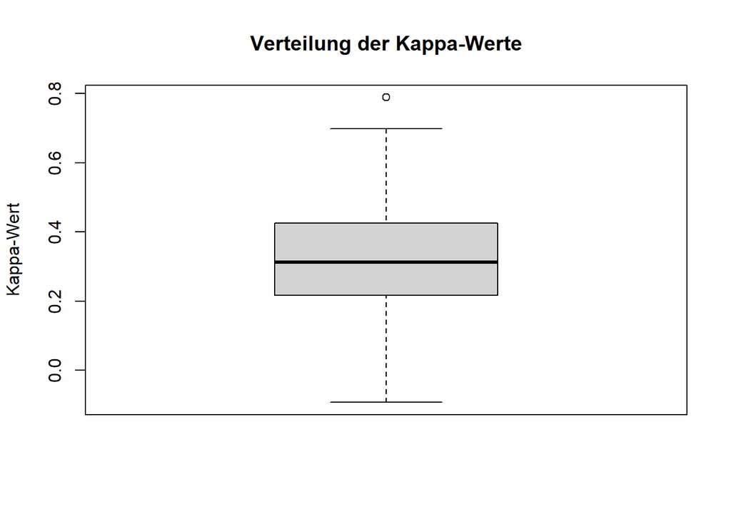

```r
# Optional: Visualisierung der Kappa-Werte
boxplot(results_peritem$kappa_value, main = "Verteilung der Kappa-Werte", ylab = "Kappa-Wert")
```

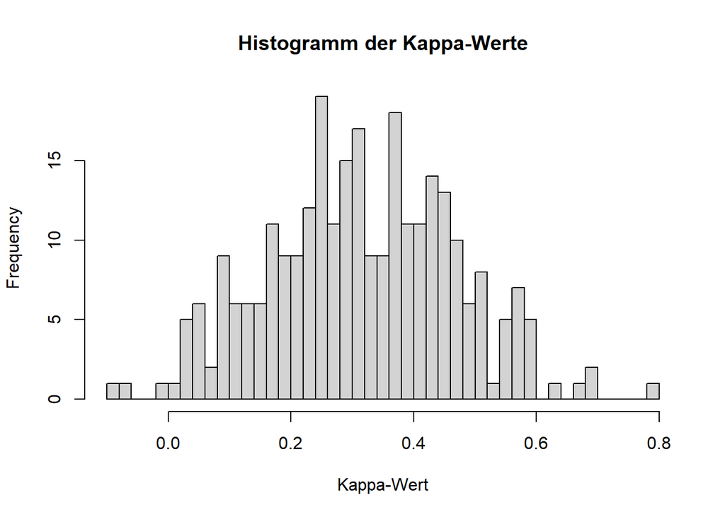

```r
# Optional: Histogramm der Kappa-Werte
hist(results_peritem$kappa_value, main = "Histogramm der Kappa-Werte", xlab = "Kappa-Wert", breaks = 50)
```

```r
# Shapiro-Wilk-Test zur Überprüfung auf Normalverteilung der Kappa-Werte
shapiro_test <- shapiro.test(results_peritem$kappa_value)

# Shapiro-Wilk-Test-Ergebnisse anzeigen
cat("Shapiro-Wilk-Test für Kappa-Werte:\n")
```

```
## Shapiro-Wilk-Test für Kappa-Werte:
```

```r
print(shapiro_test)
```

```
##
##  Shapiro-Wilk normality test
##
## data:  results_peritem$kappa_value
## W = 0.99704, p-value = 0.8911
```

```r
# Übersicht der besten und schlechtesten psp-Werte (Top 5 und Bottom 5)
cat("Top 5 PSP nach Kappa-Wert:\n")
```

```
## Top 5 PSP nach Kappa-Wert:
```

```r
print(head(results_sorted_kappa, 5))
```

```
##     psp kappa_value percent_agreement
## 195 390   0.7888811          87.50000
## 149 331   0.6982036          82.50000
## 203 399   0.6884446          81.51261
## 151 333   0.6733728          80.83333
## 198 393   0.6268325          76.66667
```

```r
cat("Bottom 5 PSP nach Kappa-Wert:\n")
```

```
## Bottom 5 PSP nach Kappa-Wert:
```

```r
print(tail(results_sorted_kappa, 5))
```

```
##     psp  kappa_value percent_agreement
## 6    27  0.020637899          27.50000
## 249 453  0.004881121          34.16667
## 173 358 -0.017580145          31.66667
## 266 471 -0.071648532          27.50000
## 174 359 -0.092896175          25.00000
```

```r
cat("Top 5 PSP nach Prozentübereinstimmung:\n")
```

```
## Top 5 PSP nach Prozentübereinstimmung:
```

```r
print(head(results_sorted_agreement, 5))
```

```
##     psp kappa_value percent_agreement
## 195 390   0.7888811          87.50000
## 149 331   0.6982036          82.50000
## 203 399   0.6884446          81.51261
## 151 333   0.6733728          80.83333
## 198 393   0.6268325          76.66667
```

```r
cat("Bottom 5 PSP nach Prozentübereinstimmung:\n")
```

```
## Bottom 5 PSP nach Prozentübereinstimmung:
```

```r
print(tail(results_sorted_agreement, 5))
```

```
##     psp kappa_value percent_agreement
## 266 471 -0.07164853          27.50000
## 85  193  0.07845362          26.66667
## 174 359 -0.09289617          25.00000
## 64  150  0.04672897          24.36975
## 94  215  0.03094186          20.83333
```

## für analyse welche psp gut

```r
# Left join: data_gpt_olmo_processed und results_sorted_kappa auf Basis der Spalte 'psp' zusammenführen
analyse_per_psp <-  results_sorted_kappa %>%
  left_join(data_gpt_olmo_processed, by = "psp")

# Optional: Einen Überblick über den neuen Datensatz anzeigen
head(analyse_per_psp)
```

```
##   psp kappa_value percent_agreement
## 1 390   0.7888811          87.50000
## 2 331   0.6982036          82.50000
## 3 399   0.6884446          81.51261
## 4 333   0.6733728          80.83333
## 5 393   0.6268325          76.66667
## 6 327   0.5946418          75.83333
##                                                                              title_pap
## 1 The Illusion of Consensus: A Failure to Distinguish Between True and False Consensus
## 2                        Still Suspicious: The Suspicious-Coincidence Effect Revisited
## 3                                                   The Interpersonal Sunk-Cost Effect
## 4                        Still Suspicious: The Suspicious-Coincidence Effect Revisited
## 5 The Illusion of Consensus: A Failure to Distinguish Between True and False Consensus
## 6             Specks of Dirt and Tons of Pain: Dosage Distinguishes Impurity From Harm
##       study_pap   date_gpt prompt_version test_retest chat_gpt_version
```

[output cut: 426 more lines]

```r
# Optional: Die Struktur des neuen Datensatzes anzeigen
str(analyse_per_psp)
```

```
## 'data.frame':    309 obs. of  302 variables:
##  $ psp                                : num  390 331 399 333 393 327 424 452 452 48 ...
##  $ kappa_value                        : num  0.789 0.698 0.688 0.673 0.627 ...
##  $ percent_agreement                  : num  87.5 82.5 81.5 80.8 76.7 ...
##  $ title_pap                          : chr  "The Illusion of Consensus: A Failure to Distinguish Between True and False Consensus" "Still Suspicious: The Suspicious-Coincidence Effect Revisited" "The Interpersonal Sunk-Cost Effect" "Still Suspicious: The Suspicious-Coincidence Effect Revisited" …
##  $ study_pap                          : chr  "Experiment 4" "Experiment 3" "Experiment 3b" "Experiment 5" ...
##  $ date_gpt                           : POSIXct, format: "2024-07-10" "2024-07-09" ...
##  $ prompt_version                     : chr  "D" "D" "D" "D" ...
##  $ test_retest                        : chr  "Test" "Test" "Test" "Test" ...
##  $ chat_gpt_version                   : chr  "4o" "4o" "4o" "4o" ...
##  $ time_extraction                    : num  NA NA NA NA NA NA NA NA 69 NA ...
##  $ time_comparison                    : num  NA NA NA NA NA NA NA NA 63 NA ...
##  $ pre_pre_mi1_gpt                    : chr  "y" "y" "y" "y" ...
##  $ pre_mi1_gpt                        : chr  "y" "y" "y" "y" ...
##  $ pre_iv1_gpt                        : chr  "x" "x" "x" "x" ...
```

[output cut: 86 more lines]

# interrater kappa per EXPERIMENT TYPE

```r
# Funktion zur Berechnung des Konfidenzintervalls für Kappa
calculate_kappa_confidence_interval <- function(kappa_value, n, alpha = 0.05) {
  # Standardfehler von Kappa
  standard_error <- sqrt((1 - kappa_value^2) / n)

  # Z-Wert für das gewünschte Konfidenzniveau (z.B. 95%)
  z_value <- qnorm(1 - alpha / 2)

  # Berechnung der unteren und oberen Grenze des Konfidenzintervalls
  ci_lower <- kappa_value - z_value * standard_error
  ci_upper <- kappa_value + z_value * standard_error

  return(c(ci_lower, ci_upper))
}

# Spalten mit _gpt und _olmo Suffix finden
gpt_columns_experimenttype <- grep("_gpt$", colnames(data_gpt_olmo_processed), value = TRUE)
olmo_columns_experimenttype <- gsub("_gpt$", "_olmo", gpt_columns_experimenttype)

# Überprüfen, ob die entsprechenden _olmo-Spalten existieren
valid_gpt_columns_experimenttype <- gpt_columns_experimenttype[olmo_columns_experimenttype %in% colnames(data_gpt_olmo_processed)]
valid_olmo_columns_experimenttype <- olmo_columns_experimenttype[olmo_columns_experimenttype %in% colnames(data_gpt_olmo_processed)]

# Sicherstellen, dass nur gültige Paare verwendet werden
if(length(valid_gpt_columns_experimenttype) == 0) {
  stop("Keine gültigen Paare von GPT- und OLMO-Spalten gefunden!")
}

# Definiere die verschiedenen Kategorien in der 'type' Spalte
types_experimenttype <- c("Association", "Interaction / moderated effect", "Effect", "Mediated effect", "Moderated association")

# Initialisiere eine leere Tabelle für die Ergebnisse
results_table <- data.frame(
  Experiment_Type = character(),
  Kappa = numeric(),
  Confidence_Interval = character(),
  Agreement_Percent = numeric(),
  N_Comparisons = integer(),
  stringsAsFactors = FALSE
)

# Schleife durch jede Kategorie und berechne das Kappa für jede
for (type_experimenttype in types_experimenttype) {
  # Filtere die Zeilen, die zur aktuellen Kategorie gehören
  type_data_experimenttype <- data_gpt_olmo_processed[data_gpt_olmo_processed$type == type_experimenttype, ]

  # Kombinieren der Spalten in einem DataFrame für den Vergleich der aktuellen Kategorie
  combined_data_experimenttype <- data.frame()

  for(i in 1:length(valid_gpt_columns_experimenttype)) {
    # Füge die Werte der GPT und OLMO Spalten zur kombinierten Datensatz hinzu
    combined_data_experimenttype <- rbind(combined_data_experimenttype,
                                          data.frame(GPT = type_data_experimenttype[[valid_gpt_columns_experimenttype[i]]],
                                                     OLMO = type_data_experimenttype[[valid_olmo_columns_experimenttype[i]]]))
  }

  # Überprüfen, ob die Daten eine ausreichende Anzahl von Spalten haben
  nc <- ncol(combined_data_experimenttype)

  if (!is.null(nc) && nc > 1) {
    # Entferne NA-Werte
    combined_data_experimenttype <- na.omit(combined_data_experimenttype)

    # Berechne Cohen's Kappa für die aktuelle Kategorie
    if (nrow(combined_data_experimenttype) > 0) {
      kappa_result_experimenttype <- irr::kappa2(combined_data_experimenttype, "unweighted")
      kappa_value_experimenttype <- kappa_result_experimenttype$value

      # Berechne das Konfidenzintervall
      ci_kappa_experimenttype <- calculate_kappa_confidence_interval(kappa_value_experimenttype, nrow(combined_data_experimenttype))

      # Berechne den Prozentsatz der Übereinstimmung
      percent_agreement_experimenttype <- sum(combined_data_experimenttype$GPT == combined_data_experimenttype$OLMO) / nrow(combined_data_experimenttype) * 100

      # Füge die Ergebnisse der Tabelle hinzu
      results_table <- rbind(results_table, data.frame(
        Experiment_Type = type_experimenttype,
        Kappa = round(kappa_value_experimenttype, 2),
        Confidence_Interval = paste0("[", round(ci_kappa_experimenttype[1], 2), ", ", round(ci_kappa_experimenttype[2], 2), "]"),
        Agreement_Percent = round(percent_agreement_experimenttype, 2),
        N_Comparisons = nrow(combined_data_experimenttype)
      ))

      # Ergebnisse anzeigen
      cat("\nCohen's Kappa für Kategorie", type_experimenttype, ":\n")
      cat("Kappa_experimenttype:", round(kappa_value_experimenttype, 2), "\n")
      cat("Konfidenzintervall_experimenttype:", round(ci_kappa_experimenttype[1], 2), "-", round(ci_kappa_experimenttype[2], 2), "\n")
      cat("Prozentuale Übereinstimmung_experimenttype:", round(percent_agreement_experimenttype, 2), "%\n")
      cat("Anzahl der Vergleiche:", nrow(combined_data_experimenttype), "\n")
    } else {
      cat("Keine ausreichenden Daten für die Kategorie", type_experimenttype, "\n")
    }
  } else {
    cat("Nicht genügend Spalten für die Kategorie", type_experimenttype, "\n")
  }
}
```

```
##
## Cohen's Kappa für Kategorie Association :
## Kappa_experimenttype: 0.21
## Konfidenzintervall_experimenttype: 0.18 - 0.23
## Prozentuale Übereinstimmung_experimenttype: 46.9 %
## Anzahl der Vergleiche: 4908
##
## Cohen's Kappa für Kategorie Interaction / moderated effect :
## Kappa_experimenttype: 0.31
## Konfidenzintervall_experimenttype: 0.29 - 0.33
## Prozentuale Übereinstimmung_experimenttype: 55.09 %
## Anzahl der Vergleiche: 8730
##
## Cohen's Kappa für Kategorie Effect :
## Kappa_experimenttype: 0.34
## Konfidenzintervall_experimenttype: 0.33 - 0.35
## Prozentuale Übereinstimmung_experimenttype: 56.97 %
## Anzahl der Vergleiche: 20684
##
## Cohen's Kappa für Kategorie Mediated effect :
## Kappa_experimenttype: 0.3
## Konfidenzintervall_experimenttype: 0.26 - 0.34
## Prozentuale Übereinstimmung_experimenttype: 54.11 %
## Anzahl der Vergleiche: 2155
##
## Cohen's Kappa für Kategorie Moderated association :
## Kappa_experimenttype: 0.23
## Konfidenzintervall_experimenttype: 0.14 - 0.31
## Prozentuale Übereinstimmung_experimenttype: 48.95 %
## Anzahl der Vergleiche: 478
```

```r
# Zeige die Tabelle mit den Ergebnissen an
print(results_table)
```

```
##                  Experiment_Type Kappa Confidence_Interval Agreement_Percent
## 1                    Association  0.21        [0.18, 0.23]             46.90
## 2 Interaction / moderated effect  0.31        [0.29, 0.33]             55.09
## 3                         Effect  0.34        [0.33, 0.35]             56.97
## 4                Mediated effect  0.30        [0.26, 0.34]             54.11
## 5          Moderated association  0.23        [0.14, 0.31]             48.95
##   N_Comparisons
## 1          4908
## 2          8730
## 3         20684
## 4          2155
## 5           478
```

## differenztest steigers z per intterater experiment type

```r
# Funktion zur Berechnung des Z-Tests für den Unterschied zwischen zwei Kappa-Werten
calculate_z_difference <- function(kappa1, se_kappa1, kappa2, se_kappa2) {
  if (!is.na(se_kappa1) & !is.na(se_kappa2)) {
    z_diff <- (kappa1 - kappa2) / sqrt(se_kappa1^2 + se_kappa2^2)
    p_value <- 2 * (1 - pnorm(abs(z_diff)))  # Zweiseitiger Test
    return(c(z_diff, p_value))
  } else {
    return(c(NA, NA))  # Kein Vergleich möglich, falls SE nicht berechnet werden kann
  }
}

# Spezifische Experimenttypen für den Vergleich
type1 <- "Effect"
type2 <- "Association"

# Funktion zur Berechnung des Kappa und SE für einen spezifischen Experimenttyp
calculate_kappa_for_type <- function(type) {
  type_data <- data_gpt_olmo_processed[data_gpt_olmo_processed$type == type, ]
  combined_data <- data.frame()

  for(i in 1:length(valid_gpt_columns_experimenttype)) {
    combined_data <- rbind(combined_data,
                           data.frame(GPT = type_data[[valid_gpt_columns_experimenttype[i]]],
                                      OLMO = type_data[[valid_olmo_columns_experimenttype[i]]]))
  }

  combined_data <- na.omit(combined_data)

  if (nrow(combined_data) > 0) {
    kappa_result <- irr::kappa2(combined_data, "unweighted")
    kappa_value <- kappa_result$value
    n <- nrow(combined_data)
    standard_error <- sqrt((1 - kappa_value^2) / n)
    return(list(kappa = kappa_value, se = standard_error))
  } else {
    return(list(kappa = NA, se = NA))
  }
}

# Berechnung für die beiden Experimenttypen
kappa_results_type1 <- calculate_kappa_for_type(type1)
kappa_results_type2 <- calculate_kappa_for_type(type2)

# Berechnung des Z-Werts und p-Werts für den Unterschied zwischen den beiden Kappa-Werten
z_diff_results <- calculate_z_difference(kappa_results_type1$kappa, kappa_results_type1$se,
                                         kappa_results_type2$kappa, kappa_results_type2$se)

cat("Unterschied zwischen Kappa für", type1, "und", type2, ":\n")
```

```
## Unterschied zwischen Kappa für Effect und Association :
```

```r
cat("Z-Wert:", z_diff_results[1], "\n")
```

```
## Z-Wert: 8.762148
```

```r
cat("p-Wert:", z_diff_results[2], "\n")
```

```
## p-Wert: 0
```

#protoypische /häufigste Antwort

## protoype olmo

```r
# Erstellen des neuen Datensatzes `data_prototype`
data_prototype <- data.frame(Variable = character(),
                             Prototype = character(),
                             Prototype_Percentage = numeric(),
                             stringsAsFactors = FALSE)

# Schleife über jede Spalte in `data_gpt_olmo_processed`
for (col_name in names(data_gpt_olmo_processed)) {
  # Prüfen, ob die Spalte gültige Werte enthält
  if (sum(!is.na(data_gpt_olmo_processed[[col_name]])) > 0) {
    # Ermitteln der häufigsten Antwort und deren Häufigkeit
    prototype_value <- as.character(names(sort(table(data_gpt_olmo_processed[[col_name]]), decreasing = TRUE)[1]))
    prototype_count <- max(table(data_gpt_olmo_processed[[col_name]]))

    # Berechnen des Prozentsatzes
    prototype_percentage <- (prototype_count / nrow(data_gpt_olmo_processed)) * 100
  } else {
    # Falls die Spalte nur NAs enthält, setzen wir Werte auf NA
    prototype_value <- NA
    prototype_percentage <- NA
  }

  # Hinzufügen der Werte zu `data_prototype`
  data_prototype <- rbind(data_prototype,
                          data.frame(Variable = col_name,
                                     Prototype = prototype_value,
                                     Prototype_Percentage = prototype_percentage))
}


# Filtere data_prototype, um nur Zeilen mit Prototype-Werten 'y', 'n' oder 'x' zu behalten
data_prototype <- subset(data_prototype, Prototype %in% c("y", "n", "x"))

# Daten anzeigen
head(data_prototype)
```

```
##           Variable Prototype Prototype_Percentage
## 10 pre_pre_mi1_gpt         y             83.81877
## 11     pre_mi1_gpt         y             81.55340
## 12     pre_iv1_gpt         x             55.98706
## 13   c_pre_iv1_gpt         x             55.66343
## 14  pre_niv1_1_gpt         x             58.57605
## 15  pre_niv1_2_gpt         x             58.57605
```

## mergen von data_protoype und retest_kappa summaryv2

```r
# Anzeigen der einzigartigen Werte von 'Column' in retest_kappa_summary_v2
unique(retest_kappa_summary_v2$Column)
```

```
##   [1] "pre_pre_mi1_comp" "pre_mi1_comp"     "pre_iv1_comp"
##   [4] "c_pre_iv1_comp"   "pre_niv1_1_comp"  "pre_niv1_2_comp"
##   [7] "pre_pre_mi2_comp" "pre_mi2_comp"     "pre_iv2_comp"
##  [10] "c_pre_iv2_comp"   "pre_niv2_1_comp"  "pre_niv2_2_comp"
##  [13] "pre_pre_mt_comp"  "pre_mt_comp"      "pre_tv_comp"
##  [16] "c_pre_tv_comp"    "pre_ntv_1_comp"   "pre_ntv_2_comp"
##  [19] "pre_dv_comp"      "c_pre_dv_comp"    "pre_ndv_1_comp"
##  [22] "pre_ndv_2_comp"   "pre_pre_mc_comp"  "pre_mc_comp"
##  [25] "pre_cv_comp"      "c_pre_cv_comp"    "pre_ncv_1_comp"
##  [28] "pre_ncv_2_comp"   "pre_dcp_1_comp"   "pre_dcp_2_comp"
##  [31] "pre_pa_comp"      "pre_iec_1_comp"   "pre_imd_1_comp"
##  [34] "pre_imd_2_comp"   "pre_sm_1_comp"    "pre_sm_2_comp"
##  [37] "pre_sm_3_comp"    "pre_vsa_1_comp"   "pre_vsa_2_comp"
##  [40] "pre_vsa_3_comp"   "pre_ic_comp"      "pap_pap_mi1_comp"
##  [43] "pap_mi1_comp"     "pap_iv1_comp"     "c_pap_iv1_comp"
```

[output cut: 25 more lines]

```r
# Anzeigen der einzigartigen Werte von 'Variable_clean' in data_prototype (nach Bearbeitung)
data_prototype$Variable_clean <- gsub("_gpt$", "_comp", data_prototype$Variable)
unique(data_prototype$Variable_clean)
```

```
##   [1] "pre_pre_mi1_comp" "pre_mi1_comp"     "pre_iv1_comp"
##   [4] "c_pre_iv1_comp"   "pre_niv1_1_comp"  "pre_niv1_2_comp"
##   [7] "pre_pre_mi2_comp" "pre_mi2_comp"     "pre_iv2_comp"
##  [10] "c_pre_iv2_comp"   "pre_niv2_1_comp"  "pre_niv2_2_comp"
##  [13] "pre_pre_mt_comp"  "pre_mt_comp"      "pre_tv_comp"
##  [16] "c_pre_tv_comp"    "pre_ntv_1_comp"   "pre_ntv_2_comp"
##  [19] "pre_dv_comp"      "c_pre_dv_comp"    "pre_ndv_1_comp"
##  [22] "pre_ndv_2_comp"   "pre_pre_mc_comp"  "pre_mc_comp"
##  [25] "pre_cv_comp"      "c_pre_cv_comp"    "pre_ncv_1_comp"
##  [28] "pre_ncv_2_comp"   "pre_dcp_1_comp"   "pre_dcp_2_comp"
##  [31] "pre_pa_comp"      "pre_iec_1_comp"   "pre_imd_1_comp"
##  [34] "pre_imd_2_comp"   "pre_sm_1_comp"    "pre_sm_2_comp"
##  [37] "pre_sm_3_comp"    "pre_vsa_1_comp"   "pre_vsa_2_comp"
##  [40] "pre_vsa_3_comp"   "pre_ic_comp"      "pap_pap_mi1_comp"
##  [43] "pap_mi1_comp"     "pap_iv1_comp"     "c_pap_iv1_comp"
```

[output cut: 64 more lines]

```r
# Optional: Zeige Zeilen, die keine Übereinstimmung haben
anti_join(data_prototype, retest_kappa_summary_v2, by = c("Variable_clean" = "Column"))
```

```
##             Variable Prototype Prototype_Percentage   Variable_clean
## 1   pre_pre_mi1_olmo         y             69.57929 pre_pre_mi1_olmo
## 2       pre_mi1_olmo         y             54.69256     pre_mi1_olmo
## 3       pre_iv1_olmo         x             69.25566     pre_iv1_olmo
## 4     c_pre_iv1_olmo         x             72.81553   c_pre_iv1_olmo
## 5    pre_niv1_1_olmo         x             89.64401  pre_niv1_1_olmo
## 6    pre_niv1_2_olmo         x             89.64401  pre_niv1_2_olmo
## 7   pre_pre_mi2_olmo         x             61.16505 pre_pre_mi2_olmo
## 8       pre_mi2_olmo         x             84.14239     pre_mi2_olmo
## 9       pre_iv2_olmo         x             77.02265     pre_iv2_olmo
## 10    c_pre_iv2_olmo         x             81.22977   c_pre_iv2_olmo
## 11   pre_niv2_1_olmo         x             92.23301  pre_niv2_1_olmo
## 12   pre_niv2_2_olmo         x             92.23301  pre_niv2_2_olmo
## 13   pre_pre_mt_olmo         x             92.55663  pre_pre_mt_olmo
## 14       pre_mt_olmo         x             99.67638      pre_mt_olmo
```

[output cut: 104 more lines]

```r
# Durchführung des Merges nach Überprüfung
data_retest_prototype <- retest_kappa_summary_v2 %>%
  inner_join(data_prototype, by = c("Column" = "Variable_clean"))

# Ergebnis anzeigen
head(data_retest_prototype)
```

```
##             Column     Kappa   z_value Agreement_Percentage      p_value
## 1 pre_pre_mi1_comp 0.8155738  8.073836             90.00000 1.002873e-10
## 2     pre_mi1_comp 0.7191888  8.250350             80.00000 2.156053e-13
## 3     pre_iv1_comp 0.8192771  8.276696             90.00000 1.810774e-12
## 4   c_pre_iv1_comp 0.8245614  8.631168             90.00000 2.220446e-16
## 5  pre_niv1_1_comp 0.8880597 25.350973             96.66667 5.240253e-14
## 6  pre_niv1_2_comp 0.8880597 25.350973             96.66667 5.240253e-14
##          Variable Prototype Prototype_Percentage
## 1 pre_pre_mi1_gpt         y             83.81877
## 2     pre_mi1_gpt         y             81.55340
## 3     pre_iv1_gpt         x             55.98706
## 4   c_pre_iv1_gpt         x             55.66343
## 5  pre_niv1_1_gpt         x             58.57605
## 6  pre_niv1_2_gpt         x             58.57605
```

## korrelation zw protoype percentage und kappa(retest)

```r
# Korrelation berechnen
correlation_result <- cor.test(data_retest_prototype$Kappa, data_retest_prototype$Prototype_Percentage, method = "pearson")

# Ergebnisse im APA-Format ausgeben
cat(sprintf("r(%d) = %.2f, p = %.3f, 95%% CI [%.2f, %.2f]",
            correlation_result$parameter,               # Freiheitsgrade (df)
            correlation_result$estimate,               # Korrelationskoeffizient (r)
            correlation_result$p.value,                # p-Wert
            correlation_result$conf.int[1],            # Untere Grenze des Konfidenzintervalls
            correlation_result$conf.int[2]))           # Obere Grenze des Konfidenzintervalls
```

```
## r(113) = 0.42, p = 0.000, 95% CI [0.25, 0.56]
```

## mergen von data_protoype und kappa_results

```r
# Sicherstellen, dass die Spalten 'Variable' in beiden Datensätzen als Zeichenketten behandelt werden
data_prototype$Variable <- as.character(data_prototype$Variable)
kappa_results$Variable <- as.character(kappa_results$Variable)

# Merging der beiden Datensätze direkt anhand der Spalte 'Variable'
data_interrater_prototype <- merge(
  data_prototype,
  kappa_results,
  by = "Variable",
  all = TRUE
)

# Entfernen aller Zeilen, bei denen die Variable `Variable` auf '_olmo' oder '_date' endet
data_interrater_prototype <- data_interrater_prototype[!grepl("(_olmo|_date)$", data_interrater_prototype$Variable), ]

# Ergebnis anzeigen
head(data_interrater_prototype)
```

```
##         Variable Prototype Prototype_Percentage Variable_clean      Kappa
## 1   c_pap_cv_gpt         y             57.92880  c_pap_cv_comp 0.01704158
## 3   c_pap_dv_gpt         y             57.60518  c_pap_dv_comp 0.20705878
## 5  c_pap_iv1_gpt         x             56.31068 c_pap_iv1_comp 0.13295664
## 7  c_pap_iv2_gpt         x             56.31068 c_pap_iv2_comp 0.02720375
## 9   c_pap_tv_gpt         x             55.33981  c_pap_tv_comp 0.02713023
## 11  c_pre_cv_gpt         y             56.95793  c_pre_cv_comp 0.02421982
##     P_Value    Z_Value Percent_Agreement
## 1  27.50809 0.01704158          27.50809
## 3  55.33981 0.20705878          55.33981
## 5  52.75081 0.13295664          52.75081
## 7  49.51456 0.02720375          49.51456
## 9  54.36893 0.02713023          54.36893
## 11 28.47896 0.02421982          28.47896
```

## korrelation zw protoype percentage und kappa(interrater) sowie agreement

```r
## Berechnung der Korrelation zwischen Kappa und Prototype_Percentage
correlation_kappa_prototype <- cor.test(data_interrater_prototype$Kappa, data_interrater_prototype$Prototype_Percentage)

# Ausgabe im APA-Format für Kappa und Prototype_Percentage
cat(sprintf("Kappa und Prototype_Percentage: r(%d) = %.2f, p = %.3f, 95%% CI [%.2f, %.2f]\n",
            correlation_kappa_prototype$parameter,
            correlation_kappa_prototype$estimate,
            correlation_kappa_prototype$p.value,
            correlation_kappa_prototype$conf.int[1],
            correlation_kappa_prototype$conf.int[2]))
```

```
## Kappa und Prototype_Percentage: r(116) = -0.14, p = 0.123, 95% CI [-0.32, 0.04]
```

```r
# Berechnung der Korrelation zwischen Percent_Agreement und Prototype_Percentage
correlation_percent_prototype <- cor.test(data_interrater_prototype$Percent_Agreement, data_interrater_prototype$Prototype_Percentage)

# Ausgabe im APA-Format für Percent_Agreement und Prototype_Percentage
cat(sprintf("Percent_Agreement und Prototype_Percentage: r(%d) = %.2f, p = %.3f, 95%% CI [%.2f, %.2f]\n",
            correlation_percent_prototype$parameter,
            correlation_percent_prototype$estimate,
            correlation_percent_prototype$p.value,
            correlation_percent_prototype$conf.int[1],
            correlation_percent_prototype$conf.int[2]))
```

```
## Percent_Agreement und Prototype_Percentage: r(116) = 0.28, p = 0.002, 95% CI [0.11, 0.44]
```

```r
# Berechnung der Korrelation zwischen Percent_Agreement und Kappa
correlation_percent_kappa <- cor.test(data_interrater_prototype$Percent_Agreement, data_interrater_prototype$Kappa)

# Ausgabe im APA-Format für Percent_Agreement und Kappa
cat(sprintf("Percent_Agreement und Kappa: r(%d) = %.2f, p = %.3f, 95%% CI [%.2f, %.2f]",
            correlation_percent_kappa$parameter,
            correlation_percent_kappa$estimate,
            correlation_percent_kappa$p.value,
            correlation_percent_kappa$conf.int[1],
            correlation_percent_kappa$conf.int[2]))
```

```
## Percent_Agreement und Kappa: r(116) = 0.12, p = 0.189, 95% CI [-0.06, 0.30]
```

# versuchsperson extrahieren

```r
# Erstellen eines neuen Datensatzes mit den relevanten Spalten (plus Versuchsperson)
data_gpt_olmo_numeric <- data_gpt_olmo_processed[, c("psp", "pre_dcp_1_text_gpt", "pre_dcp_1_text_olmo", "pap_dcp_1_text_gpt", "pap_dcp_1_text_olmo")]

# Umwandlung der Spalten in numerische Werte
data_gpt_olmo_numeric$pre_dcp_1_text_gpt_numeric <- as.numeric(data_gpt_olmo_numeric$pre_dcp_1_text_gpt)
data_gpt_olmo_numeric$pre_dcp_1_text_olmo_numeric <- as.numeric(data_gpt_olmo_numeric$pre_dcp_1_text_olmo)
data_gpt_olmo_numeric$pap_dcp_1_text_gpt_numeric <- as.numeric(data_gpt_olmo_numeric$pap_dcp_1_text_gpt)
data_gpt_olmo_numeric$pap_dcp_1_text_olmo_numeric <- as.numeric(data_gpt_olmo_numeric$pap_dcp_1_text_olmo)

# Logik für übereinstimmend_pre
data_gpt_olmo_numeric$uebereinstimmend_pre <- ifelse(
  data_gpt_olmo_numeric$pre_dcp_1_text_gpt == "exclude", NA,
  ifelse(!is.na(data_gpt_olmo_numeric$pre_dcp_1_text_gpt_numeric) & is.na(data_gpt_olmo_numeric$pre_dcp_1_text_olmo_numeric), "INVENT",
    ifelse(data_gpt_olmo_numeric$pre_dcp_1_text_gpt_numeric == data_gpt_olmo_numeric$pre_dcp_1_text_olmo_numeric, "IDENTICAL", "DIFFERENT")
  )
)

# Logik für übereinstimmend_pap
data_gpt_olmo_numeric$uebereinstimmend_pap <- ifelse(
  data_gpt_olmo_numeric$pap_dcp_1_text_gpt == "exclude", NA,
  ifelse(!is.na(data_gpt_olmo_numeric$pap_dcp_1_text_gpt_numeric) & is.na(data_gpt_olmo_numeric$pap_dcp_1_text_olmo_numeric), "INVENT",
    ifelse(data_gpt_olmo_numeric$pap_dcp_1_text_gpt_numeric == data_gpt_olmo_numeric$pap_dcp_1_text_olmo_numeric, "IDENTICAL", "DIFFERENT")
  )
)

# Berechnung der Abweichung für pre
data_gpt_olmo_numeric$abweichung_pre <- data_gpt_olmo_numeric$pre_dcp_1_text_gpt_numeric - data_gpt_olmo_numeric$pre_dcp_1_text_olmo_numeric

# Berechnung der Abweichung für pap
data_gpt_olmo_numeric$abweichung_pap <- data_gpt_olmo_numeric$pap_dcp_1_text_gpt_numeric - data_gpt_olmo_numeric$pap_dcp_1_text_olmo_numeric

# Ausgabe eines Teils des Datensatzes zur Überprüfung
head(data_gpt_olmo_numeric)
```

```
## # A tibble: 6 × 13
##     psp pre_dcp_1_text_gpt pre_dcp_1_text_olmo pap_dcp_1_text_gpt
##   <dbl> <chr>              <chr>               <chr>
## 1    16 24                 1000                585
## 2    17 250                250                 296
## 3    18 16                 16                  exclude
## 4    23 524                524                 471
## 5    24 531                560                 471
## 6    27 200                200                 200
## # ℹ 9 more variables: pap_dcp_1_text_olmo <chr>,
## #   pre_dcp_1_text_gpt_numeric <dbl>, pre_dcp_1_text_olmo_numeric <dbl>,
## #   pap_dcp_1_text_gpt_numeric <dbl>, pap_dcp_1_text_olmo_numeric <dbl>,
## #   uebereinstimmend_pre <chr>, uebereinstimmend_pap <chr>,
## #   abweichung_pre <dbl>, abweichung_pap <dbl>
```

## kuchendiagramm erstellen

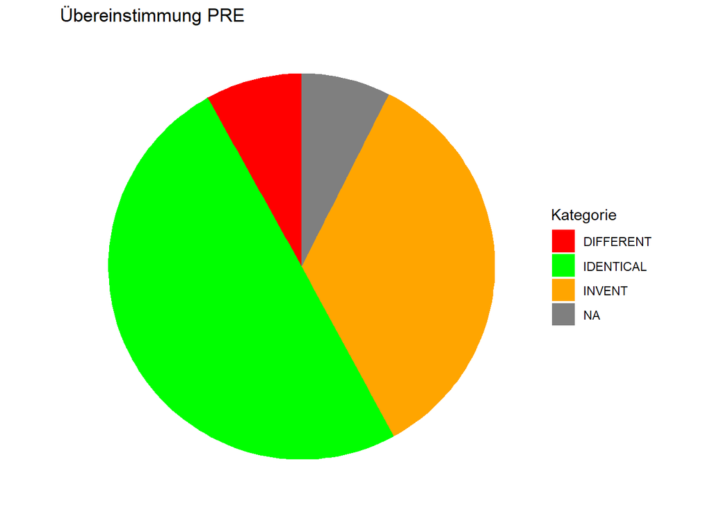

```r
# Zählen der Häufigkeiten für übereinstimmend_pre
pre_counts <- as.data.frame(table(data_gpt_olmo_numeric$uebereinstimmend_pre, useNA = "ifany"))
colnames(pre_counts) <- c("Kategorie", "Anzahl")

# Zählen der Häufigkeiten für übereinstimmend_pap
pap_counts <- as.data.frame(table(data_gpt_olmo_numeric$uebereinstimmend_pap, useNA = "ifany"))
colnames(pap_counts) <- c("Kategorie", "Anzahl")

# Kuchendiagramm für übereinstimmend_pre
plot_pre <- ggplot(pre_counts, aes(x = "", y = Anzahl, fill = Kategorie)) +
  geom_bar(width = 1, stat = "identity") +
  coord_polar("y", start = 0) +
  theme_void() +
  labs(title = "Übereinstimmung PRE") +
  scale_fill_manual(values = c("NA" = "grey", "INVENT" = "orange", "IDENTICAL" = "green", "DIFFERENT" = "red"))

# Kuchendiagramm für übereinstimmend_pap
plot_pap <- ggplot(pap_counts, aes(x = "", y = Anzahl, fill = Kategorie)) +
  geom_bar(width = 1, stat = "identity") +
  coord_polar("y", start = 0) +
  theme_void() +
  labs(title = "Übereinstimmung PAP") +
  scale_fill_manual(values = c("NA" = "grey", "INVENT" = "orange", "IDENTICAL" = "green", "DIFFERENT" = "red"))

# Anzeigen der beiden Diagramme
print(plot_pre)
```

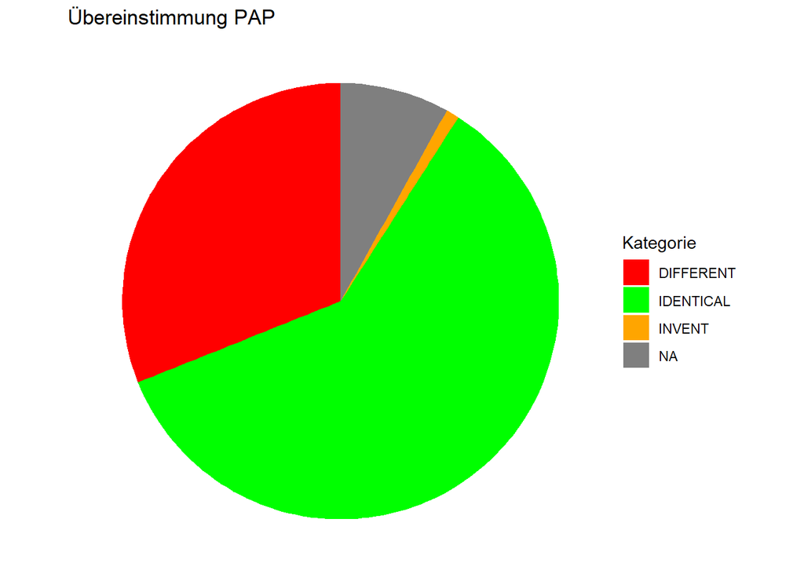

```r
print(plot_pap)
```

## N zahlen

```r
# Berechnung der absoluten Zahlen und Prozentsätze für übereinstimmend_pre
pre_counts <- as.data.frame(table(na.omit(data_gpt_olmo_numeric$uebereinstimmend_pre)))
colnames(pre_counts) <- c("Kategorie", "Anzahl")
pre_counts$Prozentsatz <- round(100 * pre_counts$Anzahl / sum(pre_counts$Anzahl), 2)

# Berechnung der absoluten Zahlen und Prozentsätze für übereinstimmend_pap
pap_counts <- as.data.frame(table(na.omit(data_gpt_olmo_numeric$uebereinstimmend_pap)))
colnames(pap_counts) <- c("Kategorie", "Anzahl")
pap_counts$Prozentsatz <- round(100 * pap_counts$Anzahl / sum(pap_counts$Anzahl), 2)

# Zusammenführen der Kategorien
combined_counts <- merge(pre_counts, pap_counts, by = "Kategorie", all = TRUE, suffixes = c("_PRE", "_PAP"))

# Berechnung der Gesamtsummen ohne
combined_counts$Anzahl_Gesamt <- combined_counts$Anzahl_PRE + combined_counts$Anzahl_PAP
combined_counts$Prozentsatz_Gesamt <- round(100 * combined_counts$Anzahl_Gesamt / sum(combined_counts$Anzahl_Gesamt), 2)

# Berechnung der durchschnittlichen Abweichung für abweichung_pre ohne
durchschnittliche_abweichung_pre <- mean(data_gpt_olmo_numeric$abweichung_pre, na.rm = TRUE)

# Berechnung der durchschnittlichen Abweichung für abweichung_pap ohne
durchschnittliche_abweichung_pap <- mean(data_gpt_olmo_numeric$abweichung_pap, na.rm = TRUE)

# Ausgabe der kombinierten Tabelle
cat("Kombinierte Tabelle für übereinstimmend_pre und übereinstimmend_pap - Absolute Zahlen und Prozentsätze (ohne NAs):\n")
```

```
## Kombinierte Tabelle für übereinstimmend_pre und übereinstimmend_pap - Absolute Zahlen und Prozentsätze (ohne NAs):
```

```r
print(combined_counts)
```

```
##   Kategorie Anzahl_PRE Prozentsatz_PRE Anzahl_PAP Prozentsatz_PAP Anzahl_Gesamt
## 1 DIFFERENT         25            8.74         96           33.80           121
## 2 IDENTICAL        154           53.85        185           65.14           339
## 3    INVENT        107           37.41          3            1.06           110
##   Prozentsatz_Gesamt
## 1              21.23
## 2              59.47
## 3              19.30
```

```r
# Ausgabe der durchschnittlichen Abweichung
cat("Durchschnittliche Abweichung PRE:", durchschnittliche_abweichung_pre, "\n")
```

```
## Durchschnittliche Abweichung PRE: -1.050279
```

```r
cat("Durchschnittliche Abweichung PAP:", durchschnittliche_abweichung_pap, "\n")
```

```
## Durchschnittliche Abweichung PAP: 68.53737
```

# Promptdauer

```r
## Berechnung des Mittelwerts und der Standardabweichung für time_extraction und time_comparison, gerundet auf 2 Dezimalstellen
summary_stats <- data_gpt_olmo_processed %>%
  summarise(
    mean_time_extraction = round(mean(time_extraction, na.rm = TRUE), 2),
    sd_time_extraction = round(sd(time_extraction, na.rm = TRUE), 2),
    mean_time_comparison = round(mean(time_comparison, na.rm = TRUE), 2),
    sd_time_comparison = round(sd(time_comparison, na.rm = TRUE), 2)
  )

# Ausgabe der Ergebnisse
print(summary_stats)
```

```
## # A tibble: 1 × 4
##   mean_time_extraction sd_time_extraction mean_time_comparison
##                  <dbl>              <dbl>                <dbl>
## 1                 65.1               6.09                 68.6
## # ℹ 1 more variable: sd_time_comparison <dbl>
```